# Data Camp Insights

davegoblue

February 15, 2017

## Background and Overview

DataCamp offer interactive courses related to R Programming. While some is review, it is helpful to see other perspectives on material. As well, DataCamp has some interesting materials on packages that I want to learn better (ggplot2, dplyr, ggvis, etc.). This document summarizes a few key insights from:

- R Programming (Introductory R, Intermediate R, Writing Functions in R, Object Oriented Programming in R)
- Importing and Cleaning Data (Cleaning Data in R, Importing Data in to R)
- Data Manipulation (dplyr, data.table, xts/zoo, dplyr joins, cases for EDA/Time Series/Pitch Data)
- Data Visualization (base, ggplot2 parts I/II/III, ggvis, geospatial)
- Statistics (8 refresher modules)

The original DataCamp_Insights_v001 document has been split for this document:

- This DataCamp_Insights_v002 document contains evolving sections on R Programming, Data Manipulation, and Statistics
- Importing and Cleaning Data components have been moved to DataCamp_ImportClean_v002
- Visualization components have been moved to DataCamp_Visualization_v002

## R Programming (Introductory R, Intermediate R, Writing Functions in R, Object Oriented Programming in R)

### *Introduction, Intermediate*

There are a few nuggest from within these beginning modules, including:

#### *Generic statements*

- factor(x, ordered=TRUE, levels=c(myLevels)) creates ordinal factors (e.g., a > b > c)
- subset(a, b) is functionally the same as a[a$b, ] but easier to read
- & looks at each element while && looks only at the first element (same for | and ||)
- Inside of a for loop, break kills the loop entirely while next moves back to the top for the next item
- args(function) shows the arguments (with defaults) for function
- search() shows the current search path (all auto-load packages and all attached packages)
- cat(“expression”) will print the expression or direct it to a file; this is a way to allow and to take effect in a print statement
- unique() keeps only the non-duplicated elements of a vector
- unlist() converts a list back to a vector, somewhat similar to as.vector() on a matrix
- sort() will sort a vector, but not a data frame
- rep(a, times=m, each=n) replicates each element of a n times, and then the whole string m times
- append(x, values, after=length(x)) will insert values in to vector x after point after
- rev() reverses a vector
- Inside a grep, “\1” captures what is inside the ()

#### *Apply usages*

- lapply() operates on a vector/list and always returns a list
- sapply() is lapply but converted to a vector/array when possible (same as lapply if not possible); if USE.NAMES=FALSE then the vector will be unnamed, though the default is USE.NAMES=TRUE for a named vector
- vapply(X, FUN, FUN.VALUE, … , USE.NAMES=TRUE) is safer than sapply in that you specify what type of vector each iteration should produce; e.g., FUN.VALUE=character(1) or FUN.VALUE=numeric(3), with an error if the vector produced by an iteration is not exactly that

#### *Dates and times*

- Sys.Date() grabs the system date as class “Date”, with units of days
- Sys.time() grabs the system time as class “POSIXct”, with units of seconds
- Sys.timezone() shows the system timezone
- Years are formatted as %Y (4-digit) or %y (2-digit)
- Months are formatted as %m (2-digit) or %B (full character) or %b (3-character)
- Days are formatted as %d (2-digit)
- Weekdays are formatted as %A (full name) or %a (partial name)
- Times include %H (24-hour hour), %M (minutes), %S (seconds)
- ?strptime will provide a lot more detail on the formats

Below is some sample code showing examples for the generic statements:

```r
# Factors
xRaw = c("High", "High", "Low", "Low", "Medium", "Very High", "Low")

xFactorNon = factor(xRaw, levels=c("Low", "Medium", "High", "Very High"))
xFactorNon
```

```
## [1] High      High      Low       Low       Medium    Very High Low
## Levels: Low Medium High Very High
```

```r
xFactorNon[xFactorNon == "High"] > xFactorNon[xFactorNon == "Low"][1]
```

```
## [1] NA NA
```

```r
xFactorOrder = factor(xRaw, ordered=TRUE, levels=c("Low", "Medium", "High", "Very High"))
xFactorOrder
```

```
## [1] High      High      Low       Low       Medium    Very High Low
## Levels: Low < Medium < High < Very High
```

```r
xFactorOrder[xFactorOrder == "High"] > xFactorOrder[xFactorOrder == "Low"][1]
```

```
## [1] TRUE TRUE
```

```r
# Subsets
data(mtcars)
subset(mtcars, mpg>=25)
```

```
##                 mpg cyl  disp  hp drat    wt  qsec vs am gear carb
## Fiat 128       32.4   4  78.7  66 4.08 2.200 19.47  1  1    4    1
## Honda Civic    30.4   4  75.7  52 4.93 1.615 18.52  1  1    4    2
## Toyota Corolla 33.9   4  71.1  65 4.22 1.835 19.90  1  1    4    1
## Fiat X1-9      27.3   4  79.0  66 4.08 1.935 18.90  1  1    4    1
## Porsche 914-2  26.0   4 120.3  91 4.43 2.140 16.70  0  1    5    2
## Lotus Europa   30.4   4  95.1 113 3.77 1.513 16.90  1  1    5    2
```

```r
identical(subset(mtcars, mpg>=25), mtcars[mtcars$mpg>=25, ])
```

```
## [1] TRUE
```

```r
subset(mtcars, mpg>25, select=c("mpg", "cyl", "disp"))
```

```
##                 mpg cyl  disp
## Fiat 128       32.4   4  78.7
## Honda Civic    30.4   4  75.7
## Toyota Corolla 33.9   4  71.1
## Fiat X1-9      27.3   4  79.0
## Porsche 914-2  26.0   4 120.3
## Lotus Europa   30.4   4  95.1
```

```r
# & and && (same as | and ||)
compA <- c(2, 3, 4, 1, 2, 3)
compB <- c(1, 2, 3, 4, 5, 6)
(compA > compB) & (compA + compB < 6)
```

```
## [1]  TRUE  TRUE FALSE FALSE FALSE FALSE
```

```r
(compA > compB) | (compA + compB < 6)
```

```
## [1]  TRUE  TRUE  TRUE  TRUE FALSE FALSE
```

```r
(compA > compB) && (compA + compB < 6)
```

```
## [1] TRUE
```

```r
(compA > compB) || (compA + compB < 6)
```

```
## [1] TRUE
```

```r
# Loops and cat()
# for (a in b) {
#     do stuff
#     if (exitCond) { break }
#     if (nextCond) { next }
#     do some more stuff
# }
for (myVal in compA*compB) {
    print(paste0("myVal is: ", myVal))
    if ((myVal %% 3) == 0) { cat("Divisible by 3, not happy about that\n\n"); next }
    print("That is not divisible by 3")
    if ((myVal %% 5) == 0) { cat("Exiting due to divisible by 5 but not divisible by 3\n\n"); break }
    cat("Onwards and upwards\n\n")
}
```

```
## [1] "myVal is: 2"
## [1] "That is not divisible by 3"
## Onwards and upwards
##
## [1] "myVal is: 6"
## Divisible by 3, not happy about that
##
## [1] "myVal is: 12"
## Divisible by 3, not happy about that
##
## [1] "myVal is: 4"
## [1] "That is not divisible by 3"
## Onwards and upwards
##
## [1] "myVal is: 10"
## [1] "That is not divisible by 3"
## Exiting due to divisible by 5 but not divisible by 3
```

```r
# args() and search()
args(plot.default)
```

```
## function (x, y = NULL, type = "p", xlim = NULL, ylim = NULL,
##     log = "", main = NULL, sub = NULL, xlab = NULL, ylab = NULL,
##     ann = par("ann"), axes = TRUE, frame.plot = axes, panel.first = NULL,
##     panel.last = NULL, asp = NA, ...)
## NULL
```

```r
search()
```

```
## [1] ".GlobalEnv"        "package:stats"     "package:graphics"
## [4] "package:grDevices" "package:utils"     "package:datasets"
## [7] "package:methods"   "Autoloads"         "package:base"
```

```r
# unique()
compA
```

```
## [1] 2 3 4 1 2 3
```

```r
unique(compA)
```

```
## [1] 2 3 4 1
```

```r
# unlist()
listA <- as.list(compA)
unlist(listA)
```

```
## [1] 2 3 4 1 2 3
```

```r
identical(compA, unlist(listA))
```

```
## [1] TRUE
```

```r
# sort()
sort(mtcars$mpg)
```

```
##  [1] 10.4 10.4 13.3 14.3 14.7 15.0 15.2 15.2 15.5 15.8 16.4 17.3 17.8 18.1
## [15] 18.7 19.2 19.2 19.7 21.0 21.0 21.4 21.4 21.5 22.8 22.8 24.4 26.0 27.3
## [29] 30.4 30.4 32.4 33.9
```

```r
sort(mtcars$mpg, decreasing=TRUE)
```

```
##  [1] 33.9 32.4 30.4 30.4 27.3 26.0 24.4 22.8 22.8 21.5 21.4 21.4 21.0 21.0
## [15] 19.7 19.2 19.2 18.7 18.1 17.8 17.3 16.4 15.8 15.5 15.2 15.2 15.0 14.7
## [29] 14.3 13.3 10.4 10.4
```

```r
# rep()
rep(1:6, times=2)  # 1:6 followed by 1:6
```

```
##  [1] 1 2 3 4 5 6 1 2 3 4 5 6
```

```r
rep(1:6, each=2)  # 1 1 2 2 3 3 4 4 5 5 6 6
```

```
##  [1] 1 1 2 2 3 3 4 4 5 5 6 6
```

```r
rep(1:6, times=2, each=3)  # 1 1 1 2 2 2 3 3 3 4 4 4 5 5 5 6 6 6 repeated twice (each comes first)
```

```
##  [1] 1 1 1 2 2 2 3 3 3 4 4 4 5 5 5 6 6 6 1 1 1 2 2 2 3 3 3 4 4 4 5 5 5 6 6
## [36] 6
```

```r
rep(1:6, times=6:1)  # 1 1 1 1 1 1 2 2 2 2 2 3 3 3 3 4 4 4 5 5 6
```

```
##  [1] 1 1 1 1 1 1 2 2 2 2 2 3 3 3 3 4 4 4 5 5 6
```

```r
# append()
myWords <- c("The", "cat", "in", "the", "hat")
paste(append(myWords, c("is", "fun", "to", "read")), collapse=" ")
```

```
## [1] "The cat in the hat is fun to read"
```

```r
paste(append(myWords, "funny", 4), collapse=" ")
```

```
## [1] "The cat in the funny hat"
```

```r
# grep("//1")
sampMsg <- "This is from myname@subdomain.mydomain.com again"
gsub("(^.*\\w*[a-zA-Z0-9]+@)([a-zA-Z0-9]+\\.[a-zA-Z0-9.]+)(.*$)", "\\1", sampMsg)
```

```
## [1] "This is from myname@"
```

```r
gsub("(^.*\\w*[a-zA-Z0-9]+@)([a-zA-Z0-9]+\\.[a-zA-Z0-9.]+)(.*$)", "\\2", sampMsg)
```

```
## [1] "subdomain.mydomain.com"
```

```r
gsub("(^.*\\w*[a-zA-Z0-9]+@)([a-zA-Z0-9]+\\.[a-zA-Z0-9.]+)(.*$)", "\\3", sampMsg)
```

```
## [1] " again"
```

```r
# rev()
compA
```

```
## [1] 2 3 4 1 2 3
```

```r
rev(compA)
```

```
## [1] 3 2 1 4 3 2
```

Below is some sample code showing examples for the apply statements:

```r
# lapply
args(lapply)
```

```
## function (X, FUN, ...)
## NULL
```

```r
lapply(1:5, FUN=sqrt)
```

```
## [[1]]
## [1] 1
##
## [[2]]
## [1] 1.414214
##
## [[3]]
## [1] 1.732051
##
## [[4]]
## [1] 2
##
## [[5]]
## [1] 2.236068
```

```r
lapply(1:5, FUN=function(x, y=2) { c(x=x, y=y, pow=x^y) }, y=3)
```

```
## [[1]]
##   x   y pow
##   1   3   1
##
## [[2]]
##   x   y pow
##   2   3   8
##
## [[3]]
##   x   y pow
##   3   3  27
##
## [[4]]
##   x   y pow
##   4   3  64
##
## [[5]]
##   x   y pow
##   5   3 125
```

```r
lapply(1:5, FUN=function(x, y=2) { if (x <= 3) {c(x=x, y=y, pow=x^y) } else { c(pow=x^y) } }, y=3)
```

```
## [[1]]
##   x   y pow
##   1   3   1
##
## [[2]]
##   x   y pow
##   2   3   8
##
## [[3]]
##   x   y pow
##   3   3  27
##
## [[4]]
## pow
##  64
##
## [[5]]
## pow
## 125
```

```r
# sapply (defaults to returning a named vector/array if possible; is lapply otherwise)
args(sapply)
```

```
## function (X, FUN, ..., simplify = TRUE, USE.NAMES = TRUE)
## NULL
```

```r
args(simplify2array)
```

```
## function (x, higher = TRUE)
## NULL
```

```r
sapply(1:5, FUN=sqrt)
```

```
## [1] 1.000000 1.414214 1.732051 2.000000 2.236068
```

```r
sapply(1:5, FUN=function(x, y=2) { c(x=x, y=y, pow=x^y) }, y=3)
```

```
##     [,1] [,2] [,3] [,4] [,5]
## x      1    2    3    4    5
## y      3    3    3    3    3
## pow    1    8   27   64  125
```

```r
sapply(1:5, FUN=function(x, y=2) { if (x <= 3) {c(x=x, y=y, pow=x^y) } else { c(pow=x^y) } }, y=3)
```

```
## [[1]]
##   x   y pow
##   1   3   1
##
## [[2]]
##   x   y pow
##   2   3   8
##
## [[3]]
##   x   y pow
##   3   3  27
##
## [[4]]
## pow
##  64
##
## [[5]]
## pow
## 125
```

```r
# vapply (tells sapply exactly what should be returned; errors out otherwise)
args(vapply)
```

```
## function (X, FUN, FUN.VALUE, ..., USE.NAMES = TRUE)
## NULL
```

```r
vapply(1:5, FUN=sqrt, FUN.VALUE=numeric(1))
```

```
## [1] 1.000000 1.414214 1.732051 2.000000 2.236068
```

```r
vapply(1:5, FUN=function(x, y=2) { c(x=x, y=y, pow=x^y) }, FUN.VALUE=numeric(3), y=3)
```

```
##     [,1] [,2] [,3] [,4] [,5]
## x      1    2    3    4    5
## y      3    3    3    3    3
## pow    1    8   27   64  125
```

Below is some sample code for handing dates and times in R:

```r
Sys.Date()
```

```
## [1] "2017-03-16"
```

```r
Sys.time()
```

```
## [1] "2017-03-16 07:37:43 CDT"
```

```r
args(strptime)
```

```
## function (x, format, tz = "")
## NULL
```

```r
rightNow <- as.POSIXct(Sys.time())
format(rightNow, "%Y**%M-%d %H hours and %M minutes", usetz=TRUE)
```

```
## [1] "2017**37-16 07 hours and 37 minutes CDT"
```

```r
lastChristmasNoon <- as.POSIXct("2015-12-25 12:00:00", format="%Y-%m-%d %X")
rightNow - lastChristmasNoon
```

```
## Time difference of 446.7762 days
```

```r
nextUMHomeGame <- as.POSIXct("16/SEP/3 12:00:00", format="%y/%b/%d %H:%M:%S", tz="America/Detroit")
nextUMHomeGame - rightNow
```

```
## Time difference of -193.8595 days
```

```r
# Time zones available in R
OlsonNames()
```

```
##   [1] "Africa/Abidjan"                   "Africa/Accra"
##   [3] "Africa/Addis_Ababa"               "Africa/Algiers"
##   [5] "Africa/Asmara"                    "Africa/Asmera"
##   [7] "Africa/Bamako"                    "Africa/Bangui"
##   [9] "Africa/Banjul"                    "Africa/Bissau"
##  [11] "Africa/Blantyre"                  "Africa/Brazzaville"
##  [13] "Africa/Bujumbura"                 "Africa/Cairo"
##  [15] "Africa/Casablanca"                "Africa/Ceuta"
##  [17] "Africa/Conakry"                   "Africa/Dakar"
##  [19] "Africa/Dar_es_Salaam"             "Africa/Djibouti"
##  [21] "Africa/Douala"                    "Africa/El_Aaiun"
##  [23] "Africa/Freetown"                  "Africa/Gaborone"
##  [25] "Africa/Harare"                    "Africa/Johannesburg"
##  [27] "Africa/Juba"                      "Africa/Kampala"
##  [29] "Africa/Khartoum"                  "Africa/Kigali"
```

[output cut: 277 more lines]

```r
# From ?strptime (excerpted)
#
# ** General formats **
# %c Date and time. Locale-specific on output, "%a %b %e %H:%M:%S %Y" on input.
# %F Equivalent to %Y-%m-%d (the ISO 8601 date format).
# %T Equivalent to %H:%M:%S.
# %D Date format such as %m/%d/%y: the C99 standard says it should be that exact format
# %x Date. Locale-specific on output, "%y/%m/%d" on input.
# %X Time. Locale-specific on output, "%H:%M:%S" on input.
#
# ** Key Components **
# %y Year without century (00-99). On input, values 00 to 68 are prefixed by 20 and 69 to 99 by 19
# %Y Year with century
# %m Month as decimal number (01-12).
# %b Abbreviated month name in the current locale on this platform.
# %B Full month name in the current locale.
# %d Day of the month as decimal number (01-31).
# %e Day of the month as decimal number (1-31), with a leading space for a single-digit number.
# %a Abbreviated weekday name in the current locale on this platform.
# %A Full weekday name in the current locale.
# %H Hours as decimal number (00-23)
# %I Hours as decimal number (01-12)
# %M Minute as decimal number (00-59).
# %S Second as integer (00-61), allowing for up to two leap-seconds (but POSIX-compliant implementations will ignore leap seconds).
#
# ** Additional Options **
# %C Century (00-99): the integer part of the year divided by 100.
#
# %g The last two digits of the week-based year (see %V). (Accepted but ignored on input.)
# %G The week-based year (see %V) as a decimal number. (Accepted but ignored on input.)
#
# %h Equivalent to %b.
#
# %j Day of year as decimal number (001-366).
#
# %n Newline on output, arbitrary whitespace on input.
#
# %p AM/PM indicator in the locale. Used in conjunction with %I and not with %H. An empty string in some locales (and the behaviour is undefined if used for input in such a locale).  Some platforms accept %P for output, which uses a lower-case version: others will output P.
#
# %r The 12-hour clock time (using the locale's AM or PM). Only defined in some locales.
#
# %R Equivalent to %H:%M.
#
# %t Tab on output, arbitrary whitespace on input.
#
# %u Weekday as a decimal number (1-7, Monday is 1).
#
# %U Week of the year as decimal number (00-53) using Sunday as the first day 1 of the week (and typically with the first Sunday of the year as day 1 of week 1). The US convention.
#
# %V Week of the year as decimal number (01-53) as defined in ISO 8601. If the week (starting on Monday) containing 1 January has four or more days in the new year, then it is considered week 1. Otherwise, it is the last week of the previous year, and the next week is week 1. (Accepted but ignored on input.)
#
# %w Weekday as decimal number (0-6, Sunday is 0).
#
# %W Week of the year as decimal number (00-53) using Monday as the first day of week (and typically with the first Monday of the year as day 1 of week 1). The UK convention.
#
# For input, only years 0:9999 are accepted.
#
# %z Signed offset in hours and minutes from UTC, so -0800 is 8 hours behind UTC. Values up to +1400 are accepted as from R 3.1.1: previous versions only accepted up to +1200. (Standard only for output.)
#
# %Z (Output only.) Time zone abbreviation as a character string (empty if not available). This may not be reliable when a time zone has changed abbreviations over the years.
```

Additionally, code from several practice examples is added:

```r
set.seed(1608221310)

me <- 89
other_199 <- round(rnorm(199, mean=75.45, sd=11.03), 0)

mean(other_199)
```

```
## [1] 75.17588
```

```r
sd(other_199)
```

```
## [1] 11.37711
```

```r
desMeans <- c(72.275, 76.24, 74.5, 77.695)
desSD <- c(12.31, 11.22, 12.5, 12.53)

prevData <- c(rnorm(200, mean=72.275, sd=12.31),
              rnorm(200, mean=76.24, sd=11.22),
              rnorm(200, mean=74.5, sd=12.5),
              rnorm(200, mean=77.695, sd=12.53)
              )
previous_4 <- matrix(data=prevData, ncol=4)

curMeans <- apply(previous_4, 2, FUN=mean)
curSD <- apply(previous_4, 2, FUN=sd)

previous_4 <- t(apply(previous_4, 1, FUN=function(x) { desMeans + (desSD / curSD) * (x - curMeans) } ))

apply(round(previous_4, 0), 2, FUN=mean)
```

```
## [1] 72.285 76.245 74.505 77.665
```

```r
apply(round(previous_4, 0), 2, FUN=sd)
```

```
## [1] 12.35097 11.19202 12.49643 12.51744
```

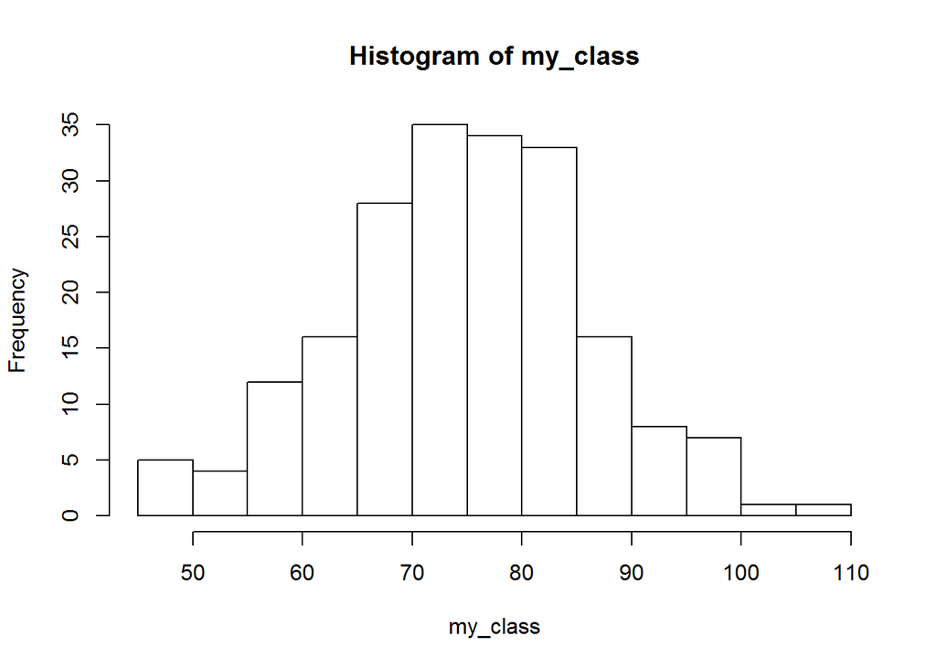

```r
previous_4 <- round(previous_4, 0)


# Merge me and other_199: my_class
my_class <- c(me, other_199)

# cbind() my_class and previous_4: last_5
last_5 <- cbind(my_class, previous_4)

# Name last_5 appropriately
nms <- paste0("year_", 1:5)
colnames(last_5) <- nms


# Build histogram of my_class
hist(my_class)
```

```r
# Generate summary of last_5
summary(last_5)
```

```
##      year_1           year_2           year_3           year_4
##  Min.   : 46.00   Min.   : 43.00   Min.   : 38.00   Min.   : 42.00
##  1st Qu.: 68.00   1st Qu.: 63.75   1st Qu.: 69.00   1st Qu.: 65.75
##  Median : 75.50   Median : 73.00   Median : 76.50   Median : 74.00
##  Mean   : 75.25   Mean   : 72.28   Mean   : 76.25   Mean   : 74.50
##  3rd Qu.: 83.25   3rd Qu.: 81.00   3rd Qu.: 84.25   3rd Qu.: 82.25
##  Max.   :108.00   Max.   :108.00   Max.   :102.00   Max.   :113.00
##      year_5
##  Min.   : 38.00
##  1st Qu.: 71.00
##  Median : 78.00
##  Mean   : 77.67
##  3rd Qu.: 86.00
##  Max.   :117.00
```

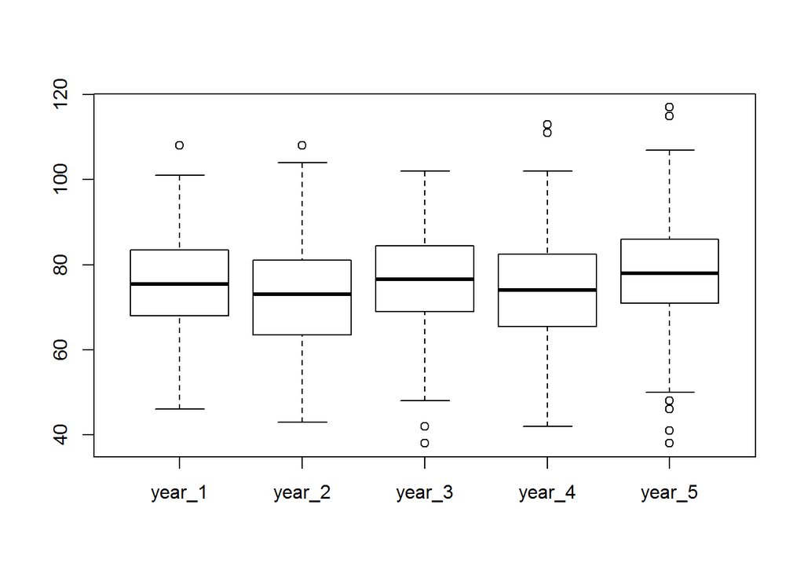

```r
# Build boxplot of last_5
boxplot(last_5)
```

```r
# How many grades in your class are higher than 75?
sum(my_class > 75)
```

```
## [1] 100
```

```r
# How many students in your class scored strictly higher than you?
sum(my_class > me)
```

```
## [1] 17
```

```r
# What's the proportion of grades below or equal to 64 in the last 5 years?
mean(last_5 <= 64)
```

```
## [1] 0.191
```

```r
# Is your grade greater than 87 and smaller than or equal to 89?
me > 87 & me <= 89
```

```
## [1] TRUE
```

```r
# Which grades in your class are below 60 or above 90?
my_class < 60 | my_class > 90
```

```
##   [1] FALSE FALSE  TRUE FALSE FALSE FALSE FALSE FALSE FALSE FALSE  TRUE
##  [12] FALSE FALSE FALSE FALSE FALSE FALSE FALSE FALSE  TRUE FALSE FALSE
##  [23]  TRUE FALSE  TRUE FALSE FALSE  TRUE  TRUE FALSE FALSE FALSE FALSE
##  [34]  TRUE FALSE FALSE FALSE FALSE FALSE FALSE FALSE FALSE FALSE  TRUE
##  [45]  TRUE FALSE FALSE FALSE FALSE FALSE FALSE FALSE FALSE FALSE  TRUE
##  [56] FALSE  TRUE FALSE FALSE FALSE FALSE FALSE FALSE FALSE FALSE FALSE
##  [67] FALSE FALSE FALSE FALSE FALSE FALSE  TRUE FALSE FALSE  TRUE FALSE
##  [78] FALSE  TRUE FALSE FALSE FALSE  TRUE  TRUE FALSE FALSE FALSE FALSE
##  [89]  TRUE FALSE FALSE FALSE FALSE  TRUE FALSE FALSE  TRUE  TRUE FALSE
## [100] FALSE FALSE  TRUE  TRUE FALSE FALSE FALSE FALSE FALSE FALSE FALSE
## [111] FALSE FALSE FALSE FALSE FALSE FALSE FALSE FALSE FALSE FALSE FALSE
## [122] FALSE FALSE FALSE FALSE FALSE FALSE  TRUE FALSE  TRUE FALSE FALSE
## [133] FALSE FALSE FALSE  TRUE FALSE FALSE FALSE FALSE FALSE FALSE FALSE
## [144]  TRUE FALSE FALSE  TRUE FALSE FALSE FALSE FALSE FALSE FALSE  TRUE
## [155] FALSE  TRUE FALSE  TRUE FALSE FALSE FALSE  TRUE FALSE FALSE FALSE
## [166] FALSE FALSE  TRUE FALSE FALSE FALSE  TRUE FALSE FALSE FALSE FALSE
## [177] FALSE FALSE  TRUE FALSE FALSE FALSE FALSE FALSE FALSE FALSE FALSE
## [188] FALSE FALSE FALSE FALSE FALSE FALSE FALSE FALSE FALSE  TRUE FALSE
## [199] FALSE FALSE
```

```r
# What's the proportion of grades in your class that is average?
mean(my_class >= 70 & my_class <= 85)
```

```
## [1] 0.525
```

```r
# How many students in the last 5 years had a grade of 80 or 90?
sum(last_5 %in% c(80, 90))
```

```
## [1] 44
```

```r
# Define n_smart
n_smart <- sum(my_class >= 80)

# Code the if-else construct
if (n_smart > 50) {
    print("smart class")
} else {
    print("rather average")
}
```

```
## [1] "smart class"
```

```r
# Define prop_less
prop_less <- mean(my_class < me)

# Code the control construct
if (prop_less > 0.9) {
    print("you're among the best 10 percent")
} else if (prop_less > 0.8) {
    print("you're among the best 20 percent")
} else {
    print("need more analysis")
}
```

```
## [1] "you're among the best 20 percent"
```

```r
# Embedded control structure: fix the error
if (mean(my_class) < 75) {
  if (mean(my_class) > me) {
    print("average year, but still smarter than me")
  } else {
    print("average year, but I'm not that bad")
  }
} else {
  if (mean(my_class) > me) {
    print("smart year, even smarter than me")
  } else {
    print("smart year, but I am smarter")
  }
}
```

```
## [1] "smart year, but I am smarter"
```

```r
# Create top_grades
top_grades <- my_class[my_class >= 85]

# Create worst_grades
worst_grades <- my_class[my_class < 65]

# Write conditional statement
if (length(top_grades) > length(worst_grades)) { print("top grades prevail") }
```

```
## [1] "top grades prevail"
```

### *R Programming (Writing Functions in R)*

Hadley and Charlotte Wickham led a course on writing functions in R. Broadly, the course includes advice on when/how to use functions, as well as specific advice about commands available through library(purrr).

Key pieces of advice include:

- Write a function once you have cut and paste some code twice or more
- Solve a simple problem before writing the function
- A good function is both correct and understandable
- Abstract away the for loops when possible (focus on data/actions, solve iteration more easily, have more understandable code), for example using purrr::map() or purr::map_() where type can be dbl, chr, lgl, int, forcing a type-certain output
- Use purrr::safely() and purrr::possibly() for better error handling
- Use purr::pmap or purr::walk2 to iterate over 2+ arguments
- Iterate functions for their side effects (printing, plotting, etc.) using purrr::walk()
- Use stop() and stopifnot() for error catching of function arguments/output formats
- Avoid type-inconsistent functions (e.g., sapply)
- Avoid non-standard functions
- Never rely on global options (e.g., how the user will have set stringsAsFactors)

John Chambers gave a few useful slogans about functions:

- Everything that exists is an object
- Everything that happens is a function call

Each function has three components:

- formals(x) are in essence the arguments as in args(), but as a list
- body(x) is the function code
- environment(x) is where it was defined

Only the LAST evaluated expression is returned. The use of return() is recommended only for early-returns in a special case (for example, when a break() will be called).

Further, functions can be written anonymously on the command line, such as (function (x) {x + 1}) (1:5). A function should only depend on arguments passed to it, not variables from a parent enviornment. Every time the function is called, it receives a clean working environment. Once it finishes, its variables are no longer available unless they were returned (either by default as the last operation, or by way of return()):

```r
# Components of a function
args(rnorm)
```

```
## function (n, mean = 0, sd = 1)
## NULL
```

```r
formals(rnorm)
```

```
## $n
##
##
## $mean
## [1] 0
##
## $sd
## [1] 1
```

```r
body(rnorm)
```

```
## .Call(C_rnorm, n, mean, sd)
```

```r
environment(rnorm)
```

```
## <environment: namespace:stats>
```

```r
# What is passed back
funDummy <- function(x) {
    if (x <= 2) {
        print("That is too small")
        return(3)  # This ends the function by convention
    }
    ceiling(x)  # This is the defaulted return() value if nothing happened to prevent the code getting here
}

funDummy(1)
```

```
## [1] "That is too small"
```

```
## [1] 3
```

```r
funDummy(5)
```

```
## [1] 5
```

```r
# Anonymous functions
(function (x) {x + 1}) (1:5)
```

```
## [1] 2 3 4 5 6
```

The course includes some insightful discussion of vectors. As it happens, lists and data frames are just special collections of vectors in R. Each column of a data frame is a vector, while each element of a list is either 1) an embedded data frame (which is eventually a vector by way of columns), 2) an embedded list (which is eventually a vector by way of recursion), or 3) an actual vector.

The atomic vectors are of types logical, integer, character, and double; complex and raw are rarer types that are also available. Lists are just recursive vectors, which is to say that lists can contain other lists and can be hetergeneous. To explore vectors, you have:

- typeof() for the type
- length() for the length

Note that NULL is the absence of a vector and has length 0. NA is the absence of an element in the vector and has length 1. All math operations with NA return NA; for example NA == NA will return NA.

There are some good tips on extracting element from a list:

- [] is to extract a sub-list
- [[]] and $ more common and extract elements while removing an element of hierachy
- seq_along(mtcars) will return 1:11 since there are 11 elements. Helfpully, is applied to a frame with no columns, this returns integer(0) which means the for() loop does not crash
- mtcars[[11]] will return the 11th element (11th column) of mtcars
- vector(“type”, “length”) will create a n empty vector of the requested type and length
- range(x, na.rm=FALSE) gives vector c(xmin, xmax) which can be handy for plotting, scaling, and the like

```r
# Data types
data(mtcars)
str(mtcars)
```

```
## 'data.frame':    32 obs. of  11 variables:
##  $ mpg : num  21 21 22.8 21.4 18.7 18.1 14.3 24.4 22.8 19.2 ...
##  $ cyl : num  6 6 4 6 8 6 8 4 4 6 ...
##  $ disp: num  160 160 108 258 360 ...
##  $ hp  : num  110 110 93 110 175 105 245 62 95 123 ...
##  $ drat: num  3.9 3.9 3.85 3.08 3.15 2.76 3.21 3.69 3.92 3.92 ...
##  $ wt  : num  2.62 2.88 2.32 3.21 3.44 ...
##  $ qsec: num  16.5 17 18.6 19.4 17 ...
##  $ vs  : num  0 0 1 1 0 1 0 1 1 1 ...
##  $ am  : num  1 1 1 0 0 0 0 0 0 0 ...
##  $ gear: num  4 4 4 3 3 3 3 4 4 4 ...
##  $ carb: num  4 4 1 1 2 1 4 2 2 4 ...
```

```r
typeof(mtcars)  # n.b. that this is technically a "list"
```

```
## [1] "list"
```

```r
length(mtcars)
```

```
## [1] 11
```

```r
# NULL and NA
length(NULL)
```

```
## [1] 0
```

```r
typeof(NULL)
```

```
## [1] "NULL"
```

```r
length(NA)
```

```
## [1] 1
```

```r
typeof(NA)
```

```
## [1] "logical"
```

```r
NULL == NULL
```

```
## logical(0)
```

```r
NULL == NA
```

```
## logical(0)
```

```r
NA == NA
```

```
## [1] NA
```

```r
is.null(NULL)
```

```
## [1] TRUE
```

```r
is.null(NA)
```

```
## [1] FALSE
```

```r
is.na(NULL)
```

```
## logical(0)
```

```r
is.na(NA)
```

```
## [1] TRUE
```

```r
# Extraction
mtcars[["mpg"]][1:5]
```

```
## [1] 21.0 21.0 22.8 21.4 18.7
```

```r
mtcars[[2]][1:5]
```

```
## [1] 6 6 4 6 8
```

```r
mtcars$hp[1:5]
```

```
## [1] 110 110  93 110 175
```

```r
# Relevant lengths
seq_along(mtcars)
```

```
##  [1]  1  2  3  4  5  6  7  8  9 10 11
```

```r
x <- data.frame()
seq_along(x)
```

```
## integer(0)
```

```r
length(seq_along(x))
```

```
## [1] 0
```

```r
foo <- function(x) { for (eachCol in seq_along(x)) { print(typeof(x[[eachCol]])) }}
foo(mtcars)
```

```
## [1] "double"
## [1] "double"
## [1] "double"
## [1] "double"
## [1] "double"
## [1] "double"
## [1] "double"
## [1] "double"
## [1] "double"
## [1] "double"
## [1] "double"
```

```r
foo(x)  # Note that this does nothing!
data(airquality)
str(airquality)
```

```
## 'data.frame':    153 obs. of  6 variables:
##  $ Ozone  : int  41 36 12 18 NA 28 23 19 8 NA ...
##  $ Solar.R: int  190 118 149 313 NA NA 299 99 19 194 ...
##  $ Wind   : num  7.4 8 12.6 11.5 14.3 14.9 8.6 13.8 20.1 8.6 ...
##  $ Temp   : int  67 72 74 62 56 66 65 59 61 69 ...
##  $ Month  : int  5 5 5 5 5 5 5 5 5 5 ...
##  $ Day    : int  1 2 3 4 5 6 7 8 9 10 ...
```

```r
foo(airquality)
```

```
## [1] "integer"
## [1] "integer"
## [1] "double"
## [1] "integer"
## [1] "integer"
## [1] "integer"
```

```r
# Range command
mpgRange <- range(mtcars$mpg)
mpgRange
```

```
## [1] 10.4 33.9
```

```r
mpgScale <- (mtcars$mpg - mpgRange[1]) / (mpgRange[2] - mpgRange[1])
summary(mpgScale)
```

```
##    Min. 1st Qu.  Median    Mean 3rd Qu.    Max.
##  0.0000  0.2138  0.3745  0.4124  0.5277  1.0000
```

The typical arguments in a function use a consistent, simple naming function:

- x, y, z: vectors
- df: data frame
- i, j: numeric indices (generally rows and columns)
- n: length of number of rows
- p: number of columns

Data arguments should come before detail arguments, and detail arguments should be given reasonable default values. See for example rnorm(n, mean=0, sd=1). The number requested (n) must be specified, but defaults are available for the details (mean and standard deviation).

#### *Functional Programming and library(purrr)*

Functions can be passed as arguments to other functions, which is at the core of functional programming. For example:

```r
do_math <- function(x, fun) { fun(x) }
do_math(1:10, fun=mean)
```

```
## [1] 5.5
```

```r
do_math(1:10, fun=sd)
```

```
## [1] 3.02765
```

The library(purrr) takes advantage of this, and in a type-consistent manner. There are functions for:

- map() will create a list as the output
- map_chr() will create a character vector as the output
- map_dbl() will create a double vector as the output
- map_int() will create an integer vector as the output
- map_lgl() will create a logical (boolean) vector as the output

The general arguments are .x (a list or an atomic vector) and .f which can be either a function, an anonymous function (formula with ~), or an extractor .x[[.f]]. For example:

```r
library(purrr)
```

```r
library(RColorBrewer)  # Need to have in non-cached chunk for later

data(mtcars)

# Create output as a list
map(.x=mtcars, .f=sum)
```

```
## $mpg
## [1] 642.9
##
## $cyl
## [1] 198
##
## $disp
## [1] 7383.1
##
## $hp
## [1] 4694
##
## $drat
## [1] 115.09
##
## $wt
## [1] 102.952
##
## $qsec
## [1] 571.16
##
## $vs
## [1] 14
##
## $am
## [1] 13
##
## $gear
## [1] 118
##
## $carb
## [1] 90
```

```r
# Create same output as a double
map_dbl(.x=mtcars, .f=sum)
```

```
##      mpg      cyl     disp       hp     drat       wt     qsec       vs
##  642.900  198.000 7383.100 4694.000  115.090  102.952  571.160   14.000
##       am     gear     carb
##   13.000  118.000   90.000
```

```r
# Create same output as integer
# map_int(.x=mtcars, .f=sum) . . . this would bomb since it is not actually an integere
map_int(.x=mtcars, .f=function(x) { as.integer(round(sum(x), 0)) } )
```

```
##  mpg  cyl disp   hp drat   wt qsec   vs   am gear carb
##  643  198 7383 4694  115  103  571   14   13  118   90
```

```r
# Same thing but using an anonymous function with ~ and .
map_int(.x=mtcars, .f = ~ as.integer(round(sum(.), 0)) )
```

```
##  mpg  cyl disp   hp drat   wt qsec   vs   am gear carb
##  643  198 7383 4694  115  103  571   14   13  118   90
```

```r
# Create a boolean vector
map_lgl(.x=mtcars, .f = ~ ifelse(sum(.) > 200, TRUE, FALSE) )
```

```
##   mpg   cyl  disp    hp  drat    wt  qsec    vs    am  gear  carb
##  TRUE FALSE  TRUE  TRUE FALSE FALSE  TRUE FALSE FALSE FALSE FALSE
```

```r
# Create a character vector
map_chr(.x=mtcars, .f = ~ ifelse(sum(.) > 200, "Large", "Not So Large") )
```

```
##            mpg            cyl           disp             hp           drat
##        "Large" "Not So Large"        "Large"        "Large" "Not So Large"
##             wt           qsec             vs             am           gear
## "Not So Large"        "Large" "Not So Large" "Not So Large" "Not So Large"
##           carb
## "Not So Large"
```

```r
# Use the extractor [pulls the first row]
map_dbl(.x=mtcars, .f=1)
```

```
##    mpg    cyl   disp     hp   drat     wt   qsec     vs     am   gear
##  21.00   6.00 160.00 110.00   3.90   2.62  16.46   0.00   1.00   4.00
##   carb
##   4.00
```

```r
# Example from help file using chaining
mtcars %>%
  split(.$cyl) %>%
  map(~ lm(mpg ~ wt, data = .x)) %>%
  map(summary) %>%
  map_dbl("r.squared")
```

```
##         4         6         8
## 0.5086326 0.4645102 0.4229655
```

```r
# Using sapply
sapply(split(mtcars, mtcars$cyl), FUN=function(.x) { summary(lm(mpg ~ wt, data=.x))$r.squared } )
```

```
##         4         6         8
## 0.5086326 0.4645102 0.4229655
```

```r
# Use the extractor from a list
cylSplit <- split(mtcars, mtcars$cyl)
map(cylSplit, "mpg")
```

```
## $`4`
##  [1] 22.8 24.4 22.8 32.4 30.4 33.9 21.5 27.3 26.0 30.4 21.4
##
## $`6`
## [1] 21.0 21.0 21.4 18.1 19.2 17.8 19.7
##
## $`8`
##  [1] 18.7 14.3 16.4 17.3 15.2 10.4 10.4 14.7 15.5 15.2 13.3 19.2 15.8 15.0
```

```r
map(cylSplit, "cyl")
```

```
## $`4`
##  [1] 4 4 4 4 4 4 4 4 4 4 4
##
## $`6`
## [1] 6 6 6 6 6 6 6
##
## $`8`
##  [1] 8 8 8 8 8 8 8 8 8 8 8 8 8 8
```

The purrr library has several additional interesting functions:

- safely() is a wrapper for any functions that traps the errors and returns a relevant list
- possibly() is similar to safely() with the exception that a default value for error cases is supplied
- quietly() is a wrapper to suppress verbosity
- transpose() reverses the order of lists (making the inner-most lists the outer-most lists), which is an easy way to extract either all the answers or all the error cases
- map2(.x, .y, .f) allows two inputs to be passed to map()
- pmap(.l, .f) allows passing a named list with as many inputs as needed to function .f
- invoke_map(.f, .x, …) lets you iterate over a list of functions .f
- walk() is like map() but called solely to get function side effects (plot, save, etc.); it also returns the object that is passed to it, which can be convenient for chaining (piping)

Some example code includes:

```r
library(purrr)  # Called again for clarity; all these key functions belong to purrr

# safely(.f, otherwise = NULL, quiet = TRUE)
safe_log10 <- safely(log10)
map(list(0, 1, 10, "a"), .f=safe_log10)
```

```
## [[1]]
## [[1]]$result
## [1] -Inf
##
## [[1]]$error
## NULL
##
##
## [[2]]
## [[2]]$result
## [1] 0
##
## [[2]]$error
## NULL
##
##
## [[3]]
## [[3]]$result
## [1] 1
##
## [[3]]$error
## NULL
##
##
## [[4]]
## [[4]]$result
## NULL
##
## [[4]]$error
## <simpleError in .f(...): non-numeric argument to mathematical function>
```

```r
# possibly(.f, otherwise, quiet = TRUE)
poss_log10 <- possibly(log10, otherwise=NaN)
map_dbl(list(0, 1, 10, "a"), .f=poss_log10)
```

```
## [1] -Inf    0    1  NaN
```

```r
# transpose() - note that this can become masked by data.table::transpose() so be careful
purrr::transpose(map(list(0, 1, 10, "a"), .f=safe_log10))
```

```
## $result
## $result[[1]]
## [1] -Inf
##
## $result[[2]]
## [1] 0
##
## $result[[3]]
## [1] 1
##
## $result[[4]]
## NULL
##
##
## $error
## $error[[1]]
## NULL
##
## $error[[2]]
## NULL
##
## $error[[3]]
## NULL
##
## $error[[4]]
## <simpleError in .f(...): non-numeric argument to mathematical function>
```

```r
purrr::transpose(map(list(0, 1, 10, "a"), .f=safe_log10))$result
```

```
## [[1]]
## [1] -Inf
##
## [[2]]
## [1] 0
##
## [[3]]
## [1] 1
##
## [[4]]
## NULL
```

```r
unlist(purrr::transpose(map(list(0, 1, 10, "a"), .f=safe_log10))$result)
```

```
## [1] -Inf    0    1
```

```r
purrr::transpose(map(list(0, 1, 10, "a"), .f=safe_log10))$error
```

```
## [[1]]
## NULL
##
## [[2]]
## NULL
##
## [[3]]
## NULL
##
## [[4]]
## <simpleError in .f(...): non-numeric argument to mathematical function>
```

```r
map_lgl(purrr::transpose(map(list(0, 1, 10, "a"), .f=safe_log10))$error, is.null)
```

```
## [1]  TRUE  TRUE  TRUE FALSE
```

```r
# map2(.x, .y, .f)
map2(list(5, 10, 20), list(1, 2, 3), .f=rnorm) # rnorm(5, 1), rnorm(10, 2), and rnorm(20, 3)
```

```
## [[1]]
## [1] 0.41176421 2.00652288 0.06152025 0.46963873 1.15436157
##
## [[2]]
##  [1] 0.006821057 2.902712636 1.436150816 1.377836302 2.625075832
##  [6] 0.680797806 0.313499192 0.718062969 2.820989906 3.134207742
##
## [[3]]
##  [1] 3.3716474 2.9393673 1.8648940 3.2343343 2.1849894 2.0697179 1.0872014
##  [8] 3.4970403 3.5769694 3.0999340 1.2033341 0.9839011 2.9820314 1.7116383
## [15] 0.8779558 1.6990118 2.5914013 2.3587803 3.7460957 1.2980312
```

```r
# pmap(.l, .f)
pmap(list(n=list(5, 10, 20), mean=list(1, 5, 10), sd=list(0.1, 0.5, 0.1)), rnorm)
```

```
## [[1]]
## [1] 1.0151570 1.1573287 1.0628581 0.8805484 0.9418430
##
## [[2]]
##  [1] 5.032920 4.689799 5.423525 5.265610 4.727383 5.252325 5.166292
##  [8] 4.861745 5.135408 4.106679
##
## [[3]]
##  [1]  9.854138 10.090939 10.045554  9.970755 10.092487  9.769531 10.140064
##  [8]  9.834716 10.196817 10.047367 10.054093 10.006439 10.142002 10.092259
## [15] 10.222459 10.082440 10.067818  9.993884 10.078380  9.936942
```

```r
# invoke_map(.f, .x, ...)
invoke_map(list(rnorm, runif, rexp), n=5)
```

```
## [[1]]
## [1] -0.96707137  0.08207476  1.39498168  0.60287972 -0.15130461
##
## [[2]]
## [1] 0.01087442 0.02980483 0.81443586 0.88438198 0.67976034
##
## [[3]]
## [1] 0.2646751 1.3233260 1.1079261 1.3504952 0.6795524
```

```r
# walk() is for the side effects of a function
x <- list(1, "\n\ta\n", 3)
x %>% walk(cat)
```

```
## 1
##  a
## 3
```

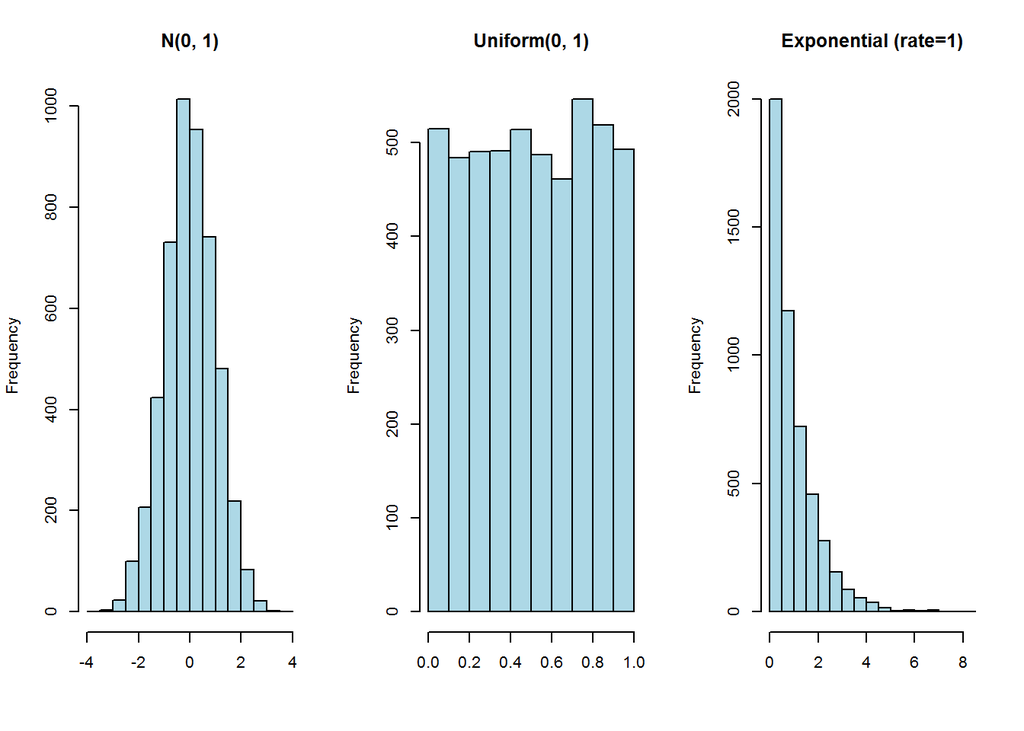

```
## $x
## $x[[1]]
##      Min.   1st Qu.    Median      Mean   3rd Qu.      Max.
## -3.711000 -0.637800 -0.000217  0.006543  0.671800  3.633000
##
## $x[[2]]
##      Min.   1st Qu.    Median      Mean   3rd Qu.      Max.
## 0.0001241 0.2518000 0.5012000 0.5028000 0.7566000 0.9999000
##
## $x[[3]]
##    Min. 1st Qu.  Median    Mean 3rd Qu.    Max.
## 0.00001 0.29140 0.68340 0.98260 1.37900 8.46300
##
##
## $main
## $main[[1]]
##    Length     Class      Mode
##         1 character character
##
## $main[[2]]
##    Length     Class      Mode
##         1 character character
##
## $main[[3]]
##    Length     Class      Mode
##         1 character character
```

```r
# Chaining is available by way of the %>% operator
pretty_titles <- c("N(0, 1)", "Uniform(0, 1)", "Exponential (rate=1)")
set.seed(1607120947)
x <- invoke_map(list(rnorm, runif, rexp), n=5000)
foo <- function(x) { map(x, .f=summary) }
par(mfrow=c(1, 3))
pwalk(list(x=x, main=pretty_titles), .f=hist, xlab="", col="light blue") %>% map(.f=foo)
```

```r
par(mfrow=c(1, 1))
```

#### *Writing Robust Functions*

There are two potentially desirable behaviors with functions:

- Relaxed (default R approach) - make reasonable guesses about what you mean, which is particularly useful for interactive analyses
- Robust (programming) - strict functions that throw errors rather than guessing in light of uncertainty

As a best practice, R functions that will be used for programming (as opposed to interactive command line work) should be written in a robust manner. Three standard problems should be avoided/mitigated:

- Type-unstable - may return a vector one time, and a list the next
- Non-standard evaluation - can use succinct API, but can introduce ambiguity
- Hidden arguments - dependence on global functions/environments

There are several methods available for throwing errors within an R function:

- stopifnot(expression) will stop and throw an error unless expression is TRUE
- if (expression) { stop(“Error”, call.=FALSE) }
- if (expression) { stop(" ‘x’ should be a character vector“, call.=FALSE) }
  - call.=FALSE means that the call to the function should not be shown (???) - Hadley recommends this

One example that commonly creates surprises is the [,] operator for extraction. Adding [ , , drop=FALSE] ensures that you will still have what you passed (e.g., a matrix or data frame) rather than conversion of a chunk of data to a vector.

Another common source of error is sapply() which will return a vector when it can and a list otherwise. The map() and map_typ() functions in purrr are designed to be type-stable; if the output is not as expected, they will error out.

Non-standard evaluations take advantage of the existence of something else (e.g., a variable in the parent environment that has not been passed). This can cause confusion and improper results.

- subset(mtcars, disp > 400) takes advantage of disp being an element of mtcars; disp would crash if called outside subset
- This can cause problems when it is embedded inside a function
- ggplot and dplyr frequently have these behaviors also
  - The risk is that you can also put variables from the global environment in to the same call

Pure functions have the key properties that 1) their output depends only on their inputs, and 2) they do not impact the outside world other than by way of their return value. Specifically, the function should not depend on how the user has configured their global options as shown in options(), nor should it modify those options() settings upon return of control to the parent environment.

A few examples are shown below:

```r
# Throwing errors to stop a function (cannot actually run these!)
# stopifnot(FALSE)
# if (FALSE) { stop("Error: ", call.=FALSE) }
# if (FALSE) { stop("Error: This condition needed to be set as TRUE", call.=FALSE) }

# Behavior of [,] and [,,drop=FALSE]
mtxTest <- matrix(data=1:9, nrow=3, byrow=TRUE)
class(mtxTest)
```

```
## [1] "matrix"
```

```r
mtxTest[1, ]
```

```
## [1] 1 2 3
```

```r
class(mtxTest[1, ])
```

```
## [1] "integer"
```

```r
mtxTest[1, , drop=FALSE]
```

```
##      [,1] [,2] [,3]
## [1,]    1    2    3
```

```r
class(mtxTest[1, , drop=FALSE])
```

```
## [1] "matrix"
```

```r
# Behavior of sapply() - may not get what you are expecting
foo <- function(x) { x^2 }
sapply(1:5, FUN=foo)
```

```
## [1]  1  4  9 16 25
```

```r
class(sapply(1:5, FUN=foo))
```

```
## [1] "numeric"
```

```r
sapply(c(1, list(1.5, 2, 2.5), 3, 4, 5), FUN=foo)
```

```
## [1]  1.00  2.25  4.00  6.25  9.00 16.00 25.00
```

```r
class(sapply(c(1, list(1.5, 2, 2.5), 3, 4, 5), FUN=foo))
```

```
## [1] "numeric"
```

```r
sapply(list(1, c(1.5, 2, 2.5), 3, 4, 5), FUN=foo)
```

```
## [[1]]
## [1] 1
##
## [[2]]
## [1] 2.25 4.00 6.25
##
## [[3]]
## [1] 9
##
## [[4]]
## [1] 16
##
## [[5]]
## [1] 25
```

```r
class(sapply(list(1, c(1.5, 2, 2.5), 3, 4, 5), FUN=foo))
```

```
## [1] "list"
```

This was a very enjoyable and instructive course.

### *Object Oriented Programming (OOP) in R: S3 and R6*

Chapter 1 - Introduction to Object Oriented Programming (OOP)

Typical R usage involves a functional programming style - data to function to new data to new function to newer values and etc. Object Oriented Programming (OOP) instead involves thinking about the data structures (objects), their functionalities, and the like:

- A method is just a function, talked about in an OOP context
- There are ~20 objects available in R; of particular interest are 1) lists and 2) environments
- Frequently, OOP is neither desirable nor necessary for data analysis; you actually prefer the functional programming style
- OOP is often better when you have a limited number of objects and you understand their behavior very well (e.g., industry SME such as Bioconductor)
  - An example would be the genomic range object
- OOP can also be better for areas like API where there are limited numbers of responses and they can be stored accordingly
- OOP can also be better for areas like GUI, as there tend to be just a small number of objects (buttons, drop-downs, and the like)
- In a nutshell, OOP is great for tool-building, while functional programming is best for data analysis

There are nine different options for OOP in R:

- No need to learn these five (5): R.oo (never really took off), OOP (defunct and no longer available), R5 (experimental and abandoned), mutatr (experimental and banadoned), proto (used early in ggplot2 but mostly deprecated now)
- S3 (fundamental R skill) - around since the 1980s; mature and widely used; a very simple system that implements functions being able to work differently on different objects; one-trick pony, but “it’s a great trick”
- S4 has been around since S version 4, mostly “a little weird and not necessarily recommended to learn as a first choice”; caveated that Bioconductor is a big user of S4
- ReferenceClasses is an attempt to behave similarly to Java, C# and the like - encapsulation and inheritance and the like
- R6 covers much of the same ground as ReferenceClasses, but in a much simpler manner
- Gist is to 1) use S3 regularly, and 2) use R6 when you need higher power and/or functionality than S3

How does R distinguish types of variables?

- Generally, class() is sufficient to interrogate the type of a variable
- If class() returns “matrix” then it may be helpful to know what the matrix contains; typeof() will distinguish that it is “integer” or “double” or “character” or the like
  - The typeof() query and result can be particularly important in S3
- The functions mode() and storage.mode() exist for compatability with older versions of S; should know they exist but no need to use them per se

Assigning Classes and Implicit Classes:

- The class can be reassigned, for example with class(x) <- “random_numbers”
- While class() can be overridden, typeof() cannot; typeof(x) will be the same even if class(x) has been reassigned
- If typeof(x) is “double” then x would be said to have an implicit class of “numeric”
  - And, as such, is.numeric(x) will still return TRUE
  - Additionally, length(x) and mean(x) and the like will still work properly, treating x as the numeric that it is

Example code includes:

```r
# Create these variables
a_numeric_vector <- rlnorm(50)
a_factor <- factor(
  sample(c(LETTERS[1:5], NA), 50, replace = TRUE)
)
a_data_frame <- data.frame(
  n = a_numeric_vector,
  f = a_factor
)
a_linear_model <- lm(dist ~ speed, cars)

# Call summary() on the numeric vector
summary(a_numeric_vector)
```

```
##    Min. 1st Qu.  Median    Mean 3rd Qu.    Max.
## 0.08694 0.58120 1.06400 1.63500 1.48800 7.43600
```

```r
# Do the same for the other three objects
summary(a_factor)
```

```
##    A    B    C    D    E NA's
##    5    9    8   11   11    6
```

```r
summary(a_data_frame)
```

```
##        n              f
##  Min.   :0.08694   A   : 5
##  1st Qu.:0.58121   B   : 9
##  Median :1.06361   C   : 8
##  Mean   :1.63546   D   :11
##  3rd Qu.:1.48764   E   :11
##  Max.   :7.43560   NA's: 6
```

```r
summary(a_linear_model)
```

```
##
## Call:
## lm(formula = dist ~ speed, data = cars)
##
## Residuals:
##     Min      1Q  Median      3Q     Max
## -29.069  -9.525  -2.272   9.215  43.201
##
## Coefficients:
##             Estimate Std. Error t value Pr(>|t|)
## (Intercept) -17.5791     6.7584  -2.601   0.0123 *
## speed         3.9324     0.4155   9.464 1.49e-12 ***
## ---
## Signif. codes:  0 '***' 0.001 '**' 0.01 '*' 0.05 '.' 0.1 ' ' 1
##
## Residual standard error: 15.38 on 48 degrees of freedom
## Multiple R-squared:  0.6511, Adjusted R-squared:  0.6438
## F-statistic: 89.57 on 1 and 48 DF,  p-value: 1.49e-12
```

```r
type_info <-
function(x)
{
  c(
    class = class(x),
    typeof = typeof(x),
    mode = mode(x),
    storage.mode = storage.mode(x)
  )
}

# Create list of example variables
some_vars <- list(
  an_integer_vector = rpois(24, lambda = 5),
  a_numeric_vector = rbeta(24, shape1 = 1, shape2 = 1),
  an_integer_array = array(rbinom(24, size = 8, prob = 0.5), dim = c(2, 3, 4)),
  a_numeric_array = array(rweibull(24, shape = 1, scale = 1), dim = c(2, 3, 4)),
  a_data_frame = data.frame(int = rgeom(24, prob = 0.5), num = runif(24)),
  a_factor = factor(month.abb),
  a_formula = y ~ x,
  a_closure_function = mean,
  a_builtin_function = length,
  a_special_function = `if`
)

# Loop over some_vars calling type_info() on each element to explore them
lapply(some_vars, FUN=type_info)
```

```
## $an_integer_vector
##        class       typeof         mode storage.mode
##    "integer"    "integer"    "numeric"    "integer"
##
## $a_numeric_vector
##        class       typeof         mode storage.mode
##    "numeric"     "double"    "numeric"     "double"
##
## $an_integer_array
##        class       typeof         mode storage.mode
##      "array"    "integer"    "numeric"    "integer"
##
## $a_numeric_array
##        class       typeof         mode storage.mode
##      "array"     "double"    "numeric"     "double"
##
## $a_data_frame
##        class       typeof         mode storage.mode
## "data.frame"       "list"       "list"       "list"
##
## $a_factor
##        class       typeof         mode storage.mode
##     "factor"    "integer"    "numeric"    "integer"
##
## $a_formula
##        class       typeof         mode storage.mode
##    "formula"   "language"       "call"   "language"
##
## $a_closure_function
##        class       typeof         mode storage.mode
##   "function"    "closure"   "function"   "function"
##
## $a_builtin_function
##        class       typeof         mode storage.mode
##   "function"    "builtin"   "function"   "function"
##
## $a_special_function
##        class       typeof         mode storage.mode
##   "function"    "special"   "function"   "function"
```

```r
whiteChess <- list(king="g1", queen="h4", bishops=c("c2", "g5"), knights=character(0), rooks=c("f1", "f6"), pawns=c("a2", "b2", "d4", "e3", "g2", "h2"))
blackChess <- list(king="g8", queen="d7", bishops=c("b7", "e7"), knights=character(0), rooks=c("a6", "f8"), pawns=c("a5", "c3", "c4", "d5", "f7", "g6"))
chess <- list(white=whiteChess, black=blackChess)

# Explore the structure of chess
str(chess)
```

```
## List of 2
##  $ white:List of 6
##   ..$ king   : chr "g1"
##   ..$ queen  : chr "h4"
##   ..$ bishops: chr [1:2] "c2" "g5"
##   ..$ knights: chr(0)
##   ..$ rooks  : chr [1:2] "f1" "f6"
##   ..$ pawns  : chr [1:6] "a2" "b2" "d4" "e3" ...
##  $ black:List of 6
##   ..$ king   : chr "g8"
##   ..$ queen  : chr "d7"
##   ..$ bishops: chr [1:2] "b7" "e7"
##   ..$ knights: chr(0)
##   ..$ rooks  : chr [1:2] "a6" "f8"
##   ..$ pawns  : chr [1:6] "a5" "c3" "c4" "d5" ...
```

```r
# Override the class of chess
class(chess) <- "chess_game"

# Is chess still a list?
is.list(chess)
```

```
## [1] TRUE
```

```r
# How many pieces are left on the board?
length(unlist(chess))
```

```
## [1] 24
```

```r
type_info(chess)  # note that typeof(), mode(), and storage.mode() all remained as list
```

```
##        class       typeof         mode storage.mode
## "chess_game"       "list"       "list"       "list"
```

Chapter 2 - Using S3

Function overloading is the property of a function of input-dependent behavior:

- The primary purpose is to make coding easier - otherwise, there would need to be many more functions
- The S3 system exists to make this simpler; specifically, S3 splits a function in to “generic” and “method”
- Methods always need to be named as generic.class; for example, print.Date or summary.factor or unique.array; the generic.default can be used as the default for all other cases
  - The generic function will then call UseMethod(“”)
- The method signatures contain the generic signatures (everything the method needs can be passed by the generic)
- Arguments can be passed between methods using the ellipsis ( . ); best practice is to include this in both the generic and the method
- Due to the feature of using generic.Method to call the various functions, naming functions with dots in them is bad practice (known as “lower.leopard.case” and is a bad idea to use)
  - Preferable is lower_snake_case or lowerCamelCase
- Can be tested using pryr::is_s3_generic() and pryr::is_s3_method()

Methodical Thinking - determining which methods are available for an S3 generic:

- Can pass the string quoted or not - methods(“mean”) and methods(mean) will both return the methods of mean
- Alternately, methods(class = “glm”) or methods(class = glm) will show all the generics that have a method for “glm”
  - This is more generous than just S3; will return both the S3 methods and the S4 methods
  - For ONLY the S3 methods, use .S3methods(class = “glm”)
  - For ONLY the S4 methods, use .S4methods(class = “glm”)
- Generally, the methods() command is the best to use

S3 and Primitive Functions:

- Most of the time for an R user is typically spent on writing, debugging, and maintaining code; as such, these tasks are often optimized by R
- However, sometimes the time need to run the code is vital; these functions are typically written in C rather than R
  - The trade-off is that C code is typically harder to write and also harder to debug
  - R has several interfaces to the C language
- Primitive - direct access through a few fundamental features reserved in base R (a function that uses this access is called a “Primitive Function” and will be .Primitive(“”))
  - .S3PrimitiveGenerics will list all of the S3 generic functions with primitive access to C
  - The primitive generic will have C go directly to the “typeof” without worrying about what class the user may have created; other generics will bomb out if the class cannot be handled

Too Much Class:

- A variable may be a member of more than one class (common with things that are tbl_df and data.frame at the same time)
- Generally, the most specific class should be listed first with the more generic classes listed last; good practice is to keep the original class at the end of the string
- The inherits() function is a nice way to see whether something belongs to a class - for example, inherits(x, “numeric”) will be TRUE is x can use the generic.numeric functions
  - Generally, this is slower than using a specific function such as is.numeric(x), so the advice is to use the specific functions as and when they are available
- The NextMethod(“function”) in a generic.method will call the next class to be acted on; can only be used if there are additional classes to be acted on (???)

Example code includes:

```r
# Create get_n_elements
get_n_elements <- function(x, ...) {
  UseMethod("get_n_elements")
}

# View get_n_elements
get_n_elements
```

```
## function(x, ...) {
##   UseMethod("get_n_elements")
## }
```

```r
# Create a data.frame method for get_n_elements
get_n_elements.data.frame <- function(x, ...) {
  nrow(x) * ncol(x)
}

# Call the method on the sleep dataset
n_elements_sleep <- get_n_elements(sleep)

# View the result
n_elements_sleep
```

```
## [1] 60
```

```r
# View pre-defined objects
# ls.str()  ## Do not run, this can be a cluster with many variables loaded . . .

# Create a default method for get_n_elements
get_n_elements.default <- function(x, ...) {
  length(unlist(x))
}

# Call the method on the ability.cov dataset
n_elements_ability.cov <- get_n_elements(ability.cov)


# Find methods for print
methods("print")
```

```
##   [1] print.acf*
##   [2] print.AES*
##   [3] print.anova*
##   [4] print.aov*
##   [5] print.aovlist*
##   [6] print.ar*
##   [7] print.Arima*
##   [8] print.arima0*
##   [9] print.AsIs
##  [10] print.aspell*
##  [11] print.aspell_inspect_context*
##  [12] print.bibentry*
##  [13] print.Bibtex*
##  [14] print.browseVignettes*
##  [15] print.by
```

[output cut: 181 more lines]

```r
# Commented due to no dataset "hair" on my machine
# View the structure of hair
# str(hair)

# What primitive generics are available?
.S3PrimitiveGenerics
```

```
##  [1] "anyNA"          "as.character"   "as.complex"     "as.double"
##  [5] "as.environment" "as.integer"     "as.logical"     "as.numeric"
##  [9] "as.raw"         "c"              "dim"            "dim<-"
## [13] "dimnames"       "dimnames<-"     "is.array"       "is.finite"
## [17] "is.infinite"    "is.matrix"      "is.na"          "is.nan"
## [21] "is.numeric"     "length"         "length<-"       "levels<-"
## [25] "names"          "names<-"        "rep"            "seq.int"
## [29] "xtfrm"
```

```r
# Does length.hairstylist exist?
# exists("length.hairstylist")

# What is the length of hair?
# length(hair)


kitty <- "Miaow!"

# Assign classes
class(kitty) <- c("cat", "mammal", "character")

# Does kitty inherit from cat/mammal/character vector?
inherits(kitty, "cat")
```

```
## [1] TRUE
```

```r
inherits(kitty, "mammal")
```

```
## [1] TRUE
```

```r
inherits(kitty, "character")
```

```
## [1] TRUE
```

```r
# Is kitty a character vector?
is.character(kitty)
```

```
## [1] TRUE
```

```r
# Does kitty inherit from dog?
inherits(kitty, "dog")
```

```
## [1] FALSE
```

```r
what_am_i <-
function(x, ...)
{
  UseMethod("what_am_i")
}

# cat method
what_am_i.cat <- function(x, ...)
{
  # Write a message
  print("I'm a cat")
  # Call NextMethod
  NextMethod("what_am_i")
}

# mammal method
what_am_i.mammal <- function(x, ...)
{
  # Write a message
  print("I'm a mammal")
  # Call NextMethod
  NextMethod("what_am_i")
}

# character method
what_am_i.character <- function(x, ...)
{
  # Write a message
  print("I'm a character vector")
}

# Call what_am_i()
what_am_i(kitty)
```

```
## [1] "I'm a cat"
## [1] "I'm a mammal"
## [1] "I'm a character vector"
```

Chapter 3 - Using R6

Object factory - R6 provides a means of storing data and objects within the same variable:

- First step is to create a “class generator” (template for objects) defining what can be stored in it and what actions can be applied to it
  - Can also be referred to as the “factory”; it can create the objects
- Factories are defined using R6::R6Class(“”, private=list(<the object’s data, must be a named list>), public=, active=)
- The $new() method of the defined factory will create a new object based on the factory’s pre-defined elements

Hiding Complexity with Encapsulation - should be able to use something even if the internal (hidden) functionality is very complicated:

- The term “encapsulation” means separating the implementation from the user interface
- Generally, the encapsulation for R6 is contained in the private=list() aspect of the factory
- The user-interface data for R6 is contained in the public=list() aspect of the factory; each aspect of this list would typically be a function
  - The function might access field in the private list, using private$ to achieve this
  - The function might access fields in the public list, using self$ to achieve this

Generally, data available in the “private” area of a class is not available to users:

- From time to time, you may want to grant “controlled access” to this “private” data – “getting” (OOP for reading) the data or “setting” (OOP for writing) the data
- R6 achieves this through “Active Bindings”; these are defined like functions, but accessed like data variables
- The “active bindings” are added to the active=list() component of an R6::R6Class()
- R6 requires that different names be used throughout; a common best practice is for all “private” variables to start with two periods (..)
- By convention, “setting” is a function that takes a single argument named “value”

Example code includes:

```r
# Define microwave_oven_factory
microwave_oven_factory <- R6::R6Class(
  "MicrowaveOven",
  private=list(power_rating_watts=800)
)

# View the microwave_oven_factory
microwave_oven_factory
```

```
## <MicrowaveOven> object generator
##   Public:
##     clone: function
##   Private:
##     power_rating_watts: 800
##   Parent env: <environment: R_GlobalEnv>
##   Locked objects: TRUE
##   Locked class: FALSE
##   Portable: TRUE
```

```r
# Make a new microwave oven
microwave_oven <- microwave_oven_factory$new()


# Add a cook method to the factory definition
microwave_oven_factory <- R6::R6Class(
  "MicrowaveOven",
  private = list(
    power_rating_watts = 800
  ),
  public = list(
    cook = function(time_seconds) {
      Sys.sleep(time_seconds)
      print("Your food is cooked!")
    }
  )
)

# Create microwave oven object
a_microwave_oven <- microwave_oven_factory$new()

# Call cook method for 1 second
a_microwave_oven$cook(time_seconds=1)
```

```
## [1] "Your food is cooked!"
```

```r
# Add a close_door() method
microwave_oven_factory <- R6::R6Class(
  "MicrowaveOven",
  private = list(
    power_rating_watts = 800,
    door_is_open = FALSE
  ),
  public = list(
    cook = function(time_seconds) {
      Sys.sleep(time_seconds)
      print("Your food is cooked!")
    },
    open_door = function() {
      private$door_is_open = TRUE
    },
    close_door = function() {
      private$door_is_open = FALSE
    }
  )
)


# Add an initialize method
microwave_oven_factory <- R6::R6Class(
  "MicrowaveOven",
  private = list(
    power_rating_watts = 800,
    door_is_open = FALSE
  ),
  public = list(
    cook = function(time_seconds) {
      Sys.sleep(time_seconds)
      print("Your food is cooked!")
    },
    open_door = function() {
      private$door_is_open = TRUE
    },
    close_door = function() {
      private$door_is_open = FALSE
    },
    # Add initialize() method here
    initialize = function(power_rating_watts, door_is_open) {
      if (!missing(power_rating_watts)) {
        private$power_rating_watts <- power_rating_watts
      }
      if (!missing(door_is_open)) {
        private$door_is_open <- door_is_open
      }
    }
  )
)

# Make a microwave
a_microwave_oven <- microwave_oven_factory$new(power_rating_watts=650, door_is_open=TRUE)


# Add a binding for power rating
microwave_oven_factory <- R6::R6Class(
  "MicrowaveOven",
  private = list(
    ..power_rating_watts = 800
  ),
  active = list(
    # add the binding here
    power_rating_watts = function() {
      private$..power_rating_watts
    }

  )
)

# Make a microwave
a_microwave_oven <- microwave_oven_factory$new()

# Get the power rating
a_microwave_oven$power_rating_watts
```

```
## [1] 800
```

```r
# Add a binding for power rating
microwave_oven_factory <- R6::R6Class(
  "MicrowaveOven",
  private = list(
    ..power_rating_watts = 800,
    ..power_level_watts = 800
  ),
  # Add active list containing an active binding
  active=list(
    power_level_watts = function(value) {
      if (missing(value)) {
        private$..power_level_watts
      } else {
        assertive.types::assert_is_a_number(value, severity="warning")
        assertive.numbers::assert_all_are_in_closed_range(value,
                                                          lower=0,
                                                          upper=private$..power_rating_watts,
                                                          severity="warning"
                                                          )
        private$..power_level_watts <- value
      }
    }
  )
)

# Make a microwave
a_microwave_oven <- microwave_oven_factory$new()

# Get the power level
a_microwave_oven$power_level_watts
```

```
## [1] 800
```

```r
# Try to set the power level to "400"
a_microwave_oven$power_level_watts <- "400"
# Try to set the power level to 1600 watts
a_microwave_oven$power_level_watts <- 1600
# Set the power level to 400 watts
a_microwave_oven$power_level_watts <- 400
```

Chapter 4 - R6 Inheritance

Inheritance is an attempt to avoid “copy and paste” from one class to another (dependent, fancier, or the like) class:

- “Parent” is the class that you inherit from
- “Children” are the classes that inherit from you
- Setting inherit= inside R6::R6Class() will send over all the private, public, and active from the parent
  - You can still add public functions and the like
- Inheritance works only in one direction - children take from parents, not the other way around
- The class() argument will be both the “parent” class and the “child” class

Extend or Override to create additional functionality:

- To override functionality, you define things with the same name as they have in the parent
- To extend functionality, you define new variables and functions, which will only be available in the child class
- The prefixes allow for access to elements from the parent, even when those have been overridden
  - private$ accesses private fields
  - self$ accesses public methods in self
  - super$ accesses public methods in parent

Multiple Levels of Inheritance - a can inherit from b that inherited from c and the like:

- By default, R6 classes only have access to their direct parent (no use of super$super$ or the like to get at the grandparent)
- This can be addressed by an active binding in the child - active=list(super_ = function() super ) # defaults to be named _super since super is a reserved word
- So, the call would become super$super_$

Example code includes:

```r
microwave_oven_factory <-
    R6::R6Class("MicrowaveOven",
                private=list(..power_rating_watts=800,
                             ..power_level_watts=800,
                             ..door_is_open=FALSE
                             ),
                public=list(cook=function(time) Sys.sleep(time),
                            open_door=function() private$..door_is_open <- TRUE,
                            close_door = function() private$..door_is_open <- FALSE
                            ),
                active=list(power_rating_watts=function() private$..power_rating_watts,
                            power_level_watts = function(value) {
                                if (missing(value)) {
                                    private$..power_level_watts
                                    } else {
                                        private$..power_level_watts <-
                                            max(0,
                                                min(private$..power_rating_watts,
                                                    as.numeric(value)
                                                    )
                                                )
                                    }
                                }
                            )
                )

# Explore the microwave oven class
microwave_oven_factory
```

```
## <MicrowaveOven> object generator
##   Public:
##     cook: function
##     open_door: function
##     close_door: function
##     clone: function
##   Active bindings:
##     power_rating_watts: function
##     power_level_watts: function
##   Private:
##     ..power_rating_watts: 800
##     ..power_level_watts: 800
##     ..door_is_open: FALSE
##   Parent env: <environment: R_GlobalEnv>
##   Locked objects: TRUE
##   Locked class: FALSE
##   Portable: TRUE
```

```r
# Define a fancy microwave class inheriting from microwave oven
fancy_microwave_oven_factory <- R6::R6Class(
  "FancyMicrowaveOven",
  inherit=microwave_oven_factory
)


# Explore microwave oven classes
microwave_oven_factory
```

```
## <MicrowaveOven> object generator
##   Public:
##     cook: function
##     open_door: function
##     close_door: function
##     clone: function
##   Active bindings:
##     power_rating_watts: function
##     power_level_watts: function
##   Private:
##     ..power_rating_watts: 800
##     ..power_level_watts: 800
##     ..door_is_open: FALSE
##   Parent env: <environment: R_GlobalEnv>
##   Locked objects: TRUE
##   Locked class: FALSE
##   Portable: TRUE
```

```r
fancy_microwave_oven_factory
```

```
## <FancyMicrowaveOven> object generator
##   Public:
##     clone: function
##   Parent env: <environment: R_GlobalEnv>
##   Locked objects: TRUE
##   Locked class: FALSE
##   Portable: TRUE
```

```r
# Instantiate both types of microwave
a_microwave_oven <- microwave_oven_factory$new()
a_fancy_microwave <- fancy_microwave_oven_factory$new()

# Get power rating for each microwave
microwave_power_rating <- a_microwave_oven$power_level_watts
fancy_microwave_power_rating <- a_fancy_microwave$power_level_watts

# Verify that these are the same
identical(microwave_power_rating, fancy_microwave_power_rating)
```

```
## [1] TRUE
```

```r
# Cook with each microwave
a_microwave_oven$cook(1)
a_fancy_microwave$cook(1)

# Explore microwave oven class
microwave_oven_factory
```

```
## <MicrowaveOven> object generator
##   Public:
##     cook: function
##     open_door: function
##     close_door: function
##     clone: function
##   Active bindings:
##     power_rating_watts: function
##     power_level_watts: function
##   Private:
##     ..power_rating_watts: 800
##     ..power_level_watts: 800
##     ..door_is_open: FALSE
##   Parent env: <environment: R_GlobalEnv>
##   Locked objects: TRUE
##   Locked class: FALSE
##   Portable: TRUE
```

```r
# Extend the class definition
fancy_microwave_oven_factory <- R6::R6Class(
  "FancyMicrowaveOven",
  inherit = microwave_oven_factory,
  # Add a public list with a cook baked potato method
  public = list(
    cook_baked_potato=function() {
      self$cook(3)
    }
  )
)

# Instantiate a fancy microwave
a_fancy_microwave <- fancy_microwave_oven_factory$new()

# Call the cook_baked_potato() method
a_fancy_microwave$cook_baked_potato()


# Explore microwave oven class
microwave_oven_factory
```

```
## <MicrowaveOven> object generator
##   Public:
##     cook: function
##     open_door: function
##     close_door: function
##     clone: function
##   Active bindings:
##     power_rating_watts: function
##     power_level_watts: function
##   Private:
##     ..power_rating_watts: 800
##     ..power_level_watts: 800
##     ..door_is_open: FALSE
##   Parent env: <environment: R_GlobalEnv>
##   Locked objects: TRUE
##   Locked class: FALSE
##   Portable: TRUE
```

```r
# Update the class definition
fancy_microwave_oven_factory <- R6::R6Class(
  "FancyMicrowaveOven",
  inherit = microwave_oven_factory,
  # Add a public list with a cook method
  public = list(
    cook = function(time_seconds) {
      super$cook(time_seconds)
      message("Enjoy your dinner!")
    }
  )

)

# Instantiate a fancy microwave
a_fancy_microwave <- fancy_microwave_oven_factory$new()

# Call the cook() method
a_fancy_microwave$cook(1)
```

```
## Enjoy your dinner!
```

```r
# Expose the parent functionality
fancy_microwave_oven_factory <- R6::R6Class(
  "FancyMicrowaveOven",
  inherit = microwave_oven_factory,
  public = list(
    cook_baked_potato = function() {
      self$cook(3)
    },
    cook = function(time_seconds) {
      super$cook(time_seconds)
      message("Enjoy your dinner!")
    }
  ),
  # Add an active element with a super_ binding
  active = list(
    super_ = function() super
  )
)

# Instantiate a fancy microwave
a_fancy_microwave <- fancy_microwave_oven_factory$new()

# Call the super_ binding
a_fancy_microwave$super_
```

```
## <environment: 0x000000000a61fc78>
```

```r
ascii_pizza_slice <- "   __\n // \"\"--.._\n||  (_)  _ \"-._\n||    _ (_)    '-.\n||   (_)   __..-'\n \\\\__..--\"\""


# Explore other microwaves
microwave_oven_factory
```

```
## <MicrowaveOven> object generator
##   Public:
##     cook: function
##     open_door: function
##     close_door: function
##     clone: function
##   Active bindings:
##     power_rating_watts: function
##     power_level_watts: function
##   Private:
##     ..power_rating_watts: 800
##     ..power_level_watts: 800
##     ..door_is_open: FALSE
##   Parent env: <environment: R_GlobalEnv>
##   Locked objects: TRUE
##   Locked class: FALSE
##   Portable: TRUE
```

```r
fancy_microwave_oven_factory
```

```
## <FancyMicrowaveOven> object generator
##   Public:
##     cook_baked_potato: function
##     cook: function
##     clone: function
##   Active bindings:
##     super_: function
##   Parent env: <environment: R_GlobalEnv>
##   Locked objects: TRUE
##   Locked class: FALSE
##   Portable: TRUE
```

```r
# Define a high-end microwave oven class
high_end_microwave_oven_factory <- R6::R6Class(
  "HighEndMicrowaveOven",
  inherit=fancy_microwave_oven_factory,
  public=list(
    cook=function(time_seconds) {
      super$super_$cook(time_seconds)
      message(ascii_pizza_slice)
    }
  )
)

# Instantiate a high-end microwave oven
a_high_end_microwave <- high_end_microwave_oven_factory$new()

# Use it to cook for one second
a_high_end_microwave$cook(1)
```

```
##    __
##  // ""--.._
## ||  (_)  _ "-._
## ||    _ (_)    '-.
## ||   (_)   __..-'
##  \\__..--""
```

Chapter 5 - Advanced R6 Usage

Environments, Reference Behavior, and Static Fields:

- New environments can be called using the new.env() # environments are always created empty
- Adding elements to an environment is very similar in syntax to adding elements to a list # The ls.str() is the best way to look at these
- One large behavioral change is that if environment A is copied to environment B, then changes made in environment A will be reflected in environment B
- R typically uses “copy by value”, where environment use “copy by reference”
- The R6 class can take advantage of the “copying by reference”, specifically by adding a shared={} to the private list of the environment
  - e <- new.env()
  - assign any variables that you like to e in later lines
  - e # just a return of the environment
- The fields can then be accessed through an active binding, using private$shared$ # can either retrieve the value or modify the value this way

Cloning Objects - R6 is built using environments, so the “copy by reference” is part and parcel of R6:

- The clone() method in R6 will instead copy by value
- So, if you set a_clone <- a_thing$clone(), a_clone will be a “copy by value” (and specifically not a “copy by reference”) of a_thing
  - There is also an argument deep=TRUE that can be inside clone(), which will make sure “copy by value” applies to all elements inside the class

Shut it Down - if the R6 object is linked to any databases or has any side effects, it can be a good idea to shut it down:

- Counterpart to initialize() is finalize(), which are the actions to take when the R6 object is detsroyed
- The rm() function does not always make the finalize() happen; rather, it will occur during garbage collection
- To force R to run the garbage collection, you can request the gc() at the command line

Example code includes:

```r
# Define a new environment
env <- new.env()

# Add an element named perfect
env$perfect <- c(6, 28, 496)

# Add an element named bases
env[["bases"]] <- c("A", "C", "G", "T")


# Assign lst and env
lst <- list(
  perfect = c(6, 28, 496),
  bases = c("A", "C", "G", "T")
)
env <- list2env(lst)

# Copy lst
lst2 <- lst

# Change lst's bases element
lst$bases <- c("A", "C", "G", "U")

# Test lst and lst2 identical
identical(lst$bases, lst2$bases)
```

```
## [1] FALSE
```

```r
# Copy env
env2 <- env

# Change env's bases element
env$bases <- c("A", "C", "G", "U")

# Test env and env2 identical
identical(env$bases, env2$bases)
```

```
## [1] TRUE
```

```r
# Complete the class definition
env_microwave_oven_factory <- R6::R6Class(
  "MicrowaveOven",
  private = list(
    shared = {
      # Create a new environment named e
      e <- new.env()
      # Assign safety_warning into e
      e$safety_warning <- "Warning. Do not try to cook metal objects."
      # Return e
      e
    }
  ),
  active = list(
    # Add the safety_warning binding
    safety_warning = function(value) {
      if (missing(value)) {
        private$shared$safety_warning
      } else {
        private$shared$safety_warning <- value
      }
    }
  )
)

# Create two microwave ovens
a_microwave_oven <- env_microwave_oven_factory$new()
another_microwave_oven <- env_microwave_oven_factory$new()

# Change the safety warning for a_microwave_oven
a_microwave_oven$safety_warning <- "Warning. If the food is too hot you may scald yourself."

# Verify that the warning has change for another_microwave
another_microwave_oven$safety_warning
```

```
## [1] "Warning. If the food is too hot you may scald yourself."
```

```r
# Still uses microwave_oven_factory as defined in Chapter 4
# Create a microwave oven
a_microwave_oven <- microwave_oven_factory$new()

# Copy a_microwave_oven using <-
assigned_microwave_oven <- a_microwave_oven

# Copy a_microwave_oven using clone()
cloned_microwave_oven <- a_microwave_oven$clone()

# Change a_microwave_oven's power level
a_microwave_oven$power_level_watts <- 400

# Check a_microwave_oven & assigned_microwave_oven same
identical(a_microwave_oven$power_level_watts, assigned_microwave_oven$power_level_watts)
```

```
## [1] TRUE
```

```r
# Check a_microwave_oven & cloned_microwave_oven different
!identical(a_microwave_oven$power_level_watts, cloned_microwave_oven$power_level_watts)
```

```
## [1] TRUE
```

```r
# Commented, due to never defined power_plug
# Create a microwave oven
# a_microwave_oven <- microwave_oven_factory$new()

# Look at its power plug
# a_microwave_oven$power_plug

# Copy a_microwave_oven using clone(), no args
# cloned_microwave_oven <- a_microwave_oven$clone()

# Copy a_microwave_oven using clone(), deep = TRUE
# deep_cloned_microwave_oven <- a_microwave_oven$clone(deep=TRUE)

# Change a_microwave_oven's power plug type
# a_microwave_oven$power_plug$type <- "British"

# Check a_microwave_oven & cloned_microwave_oven same
# identical(a_microwave_oven$power_plug$type, cloned_microwave_oven$power_plug$type)

# Check a_microwave_oven & deep_cloned_microwave_oven different
# !identical(a_microwave_oven$power_plug$type, deep_cloned_microwave_oven$power_plug$type)


# Commented due to not having this SQL database
# Microwave_factory is pre-defined
# microwave_oven_factory

# Complete the class definition
# smart_microwave_oven_factory <- R6::R6Class(
#   "SmartMicrowaveOven",
#   inherit = microwave_oven_factory, # Specify inheritance
#   private = list(
#     conn = NULL
#   ),
#   public = list(
#     initialize = function() {
#       # Connect to the database
#       private$conn = dbConnect(SQLite(), "cooking-times.sqlite")
#     },
#     get_cooking_time = function(food) {
#       dbGetQuery(
#         private$conn,
#         sprintf("SELECT time_seconds FROM cooking_times WHERE food = '%s'", food)
#       )
#     },
#     finalize = function() {
#       message("Disconnecting from the cooking times database.")
#       dbDisconnect(private$conn)
#     }
#   )
# )

# Create a smart microwave object
# a_smart_microwave <- smart_microwave_oven_factory$new()

# Call the get_cooking_time() method
# a_smart_microwave$get_cooking_time("soup")

# Remove the smart microwave
# rm(a_smart_microwave)

# Force garbage collection
# gc()
```

A nice introduction to S3 and R6.

## Data Manipulation (dplyr, data.table, xts/zoo)

### *Data Manipulation (dplyr)*

The library(dplyr) is a grammar of data manipulation. It is written in C++ so you get the speed of C with the convenience of R. It is in essence the data frame to data frame portion of plyr (plyr was the original Split-Apply-Combine). May want to look in to count, transmute, and other verbs added post this summary.

The examples use data(hflights) from library(hflights):

```r
library(dplyr)
library(hflights)
data(hflights)
head(hflights)
```

```
##      Year Month DayofMonth DayOfWeek DepTime ArrTime UniqueCarrier
## 5424 2011     1          1         6    1400    1500            AA
## 5425 2011     1          2         7    1401    1501            AA
## 5426 2011     1          3         1    1352    1502            AA
## 5427 2011     1          4         2    1403    1513            AA
## 5428 2011     1          5         3    1405    1507            AA
## 5429 2011     1          6         4    1359    1503            AA
##      FlightNum TailNum ActualElapsedTime AirTime ArrDelay DepDelay Origin
## 5424       428  N576AA                60      40      -10        0    IAH
## 5425       428  N557AA                60      45       -9        1    IAH
## 5426       428  N541AA                70      48       -8       -8    IAH
## 5427       428  N403AA                70      39        3        3    IAH
## 5428       428  N492AA                62      44       -3        5    IAH
## 5429       428  N262AA                64      45       -7       -1    IAH
##      Dest Distance TaxiIn TaxiOut Cancelled CancellationCode Diverted
## 5424  DFW      224      7      13         0                         0
## 5425  DFW      224      6       9         0                         0
## 5426  DFW      224      5      17         0                         0
## 5427  DFW      224      9      22         0                         0
## 5428  DFW      224      9       9         0                         0
## 5429  DFW      224      6      13         0                         0
```

```r
summary(hflights)
```

```
##       Year          Month          DayofMonth      DayOfWeek
##  Min.   :2011   Min.   : 1.000   Min.   : 1.00   Min.   :1.000
##  1st Qu.:2011   1st Qu.: 4.000   1st Qu.: 8.00   1st Qu.:2.000
##  Median :2011   Median : 7.000   Median :16.00   Median :4.000
##  Mean   :2011   Mean   : 6.514   Mean   :15.74   Mean   :3.948
##  3rd Qu.:2011   3rd Qu.: 9.000   3rd Qu.:23.00   3rd Qu.:6.000
##  Max.   :2011   Max.   :12.000   Max.   :31.00   Max.   :7.000
##
##     DepTime        ArrTime     UniqueCarrier        FlightNum
##  Min.   :   1   Min.   :   1   Length:227496      Min.   :   1
##  1st Qu.:1021   1st Qu.:1215   Class :character   1st Qu.: 855
##  Median :1416   Median :1617   Mode  :character   Median :1696
##  Mean   :1396   Mean   :1578                      Mean   :1962
##  3rd Qu.:1801   3rd Qu.:1953                      3rd Qu.:2755
##  Max.   :2400   Max.   :2400                      Max.   :7290
##  NA's   :2905   NA's   :3066
##    TailNum          ActualElapsedTime    AirTime         ArrDelay
##  Length:227496      Min.   : 34.0     Min.   : 11.0   Min.   :-70.000
##  Class :character   1st Qu.: 77.0     1st Qu.: 58.0   1st Qu.: -8.000
##  Mode  :character   Median :128.0     Median :107.0   Median :  0.000
##                     Mean   :129.3     Mean   :108.1   Mean   :  7.094
##                     3rd Qu.:165.0     3rd Qu.:141.0   3rd Qu.: 11.000
##                     Max.   :575.0     Max.   :549.0   Max.   :978.000
##                     NA's   :3622      NA's   :3622    NA's   :3622
##     DepDelay          Origin              Dest              Distance
##  Min.   :-33.000   Length:227496      Length:227496      Min.   :  79.0
##  1st Qu.: -3.000   Class :character   Class :character   1st Qu.: 376.0
##  Median :  0.000   Mode  :character   Mode  :character   Median : 809.0
##  Mean   :  9.445                                         Mean   : 787.8
##  3rd Qu.:  9.000                                         3rd Qu.:1042.0
##  Max.   :981.000                                         Max.   :3904.0
##  NA's   :2905
##      TaxiIn           TaxiOut         Cancelled       CancellationCode
##  Min.   :  1.000   Min.   :  1.00   Min.   :0.00000   Length:227496
##  1st Qu.:  4.000   1st Qu.: 10.00   1st Qu.:0.00000   Class :character
##  Median :  5.000   Median : 14.00   Median :0.00000   Mode  :character
##  Mean   :  6.099   Mean   : 15.09   Mean   :0.01307
##  3rd Qu.:  7.000   3rd Qu.: 18.00   3rd Qu.:0.00000
##  Max.   :165.000   Max.   :163.00   Max.   :1.00000
##  NA's   :3066      NA's   :2947
##     Diverted
##  Min.   :0.000000
##  1st Qu.:0.000000
##  Median :0.000000
##  Mean   :0.002853
##  3rd Qu.:0.000000
##  Max.   :1.000000
##
```

The “tbl” is a special type of data frame, which is very helpful for printing:

- tbl_df(myFrame) # can store or whatever - will be a tbl_df, tbl, and data.frame
  - Display is modified to fit the window display - will scale with the window
- glimpse(myFrame) # lets you see al the variables and first few records for each (sort of like str)
- as.data.frame(tbl_df(myFrame)) # this will be the data frame
  - identical(as.data.frame(tbl_df(hflights)), hflights) # FALSE
  - sum(is.na(as.data.frame(tbl_df(hflights))) != is.na(hflights)) # 0
  - sum(as.data.frame(tbl_df(hflights)) != hflights, na.rm=TRUE) # 0

An interesting way to do a lookup table:

- two <- c(“AA”, “AS”)
- lut <- c(“AA” = “American”, “AS” = “Alaska”, “B6” = “JetBlue”)
- two <- lut[two]
- two

See for example:

```r
lut <- c("AA" = "American", "AS" = "Alaska", "B6" = "JetBlue", "CO" = "Continental",
         "DL" = "Delta", "OO" = "SkyWest", "UA" = "United", "US" = "US_Airways",
         "WN" = "Southwest", "EV" = "Atlantic_Southeast", "F9" = "Frontier",
         "FL" = "AirTran", "MQ" = "American_Eagle", "XE" = "ExpressJet", "YV" = "Mesa"
         )
hflights$Carrier <- lut[hflights$UniqueCarrier]
glimpse(hflights)
```

```
## Observations: 227,496
## Variables: 22
## $ Year              <int> 2011, 2011, 2011, 2011, 2011, 2011, 2011, 20...
## $ Month             <int> 1, 1, 1, 1, 1, 1, 1, 1, 1, 1, 1, 1, 1, 1, 1,...
## $ DayofMonth        <int> 1, 2, 3, 4, 5, 6, 7, 8, 9, 10, 11, 12, 13, 1...
## $ DayOfWeek         <int> 6, 7, 1, 2, 3, 4, 5, 6, 7, 1, 2, 3, 4, 5, 6,...
## $ DepTime           <int> 1400, 1401, 1352, 1403, 1405, 1359, 1359, 13...
## $ ArrTime           <int> 1500, 1501, 1502, 1513, 1507, 1503, 1509, 14...
## $ UniqueCarrier     <chr> "AA", "AA", "AA", "AA", "AA", "AA", "AA", "A...
## $ FlightNum         <int> 428, 428, 428, 428, 428, 428, 428, 428, 428,...
## $ TailNum           <chr> "N576AA", "N557AA", "N541AA", "N403AA", "N49...
## $ ActualElapsedTime <int> 60, 60, 70, 70, 62, 64, 70, 59, 71, 70, 70, ...
## $ AirTime           <int> 40, 45, 48, 39, 44, 45, 43, 40, 41, 45, 42, ...
## $ ArrDelay          <int> -10, -9, -8, 3, -3, -7, -1, -16, 44, 43, 29,...
## $ DepDelay          <int> 0, 1, -8, 3, 5, -1, -1, -5, 43, 43, 29, 19, ...
## $ Origin            <chr> "IAH", "IAH", "IAH", "IAH", "IAH", "IAH", "I...
## $ Dest              <chr> "DFW", "DFW", "DFW", "DFW", "DFW", "DFW", "D...
## $ Distance          <int> 224, 224, 224, 224, 224, 224, 224, 224, 224,...
## $ TaxiIn            <int> 7, 6, 5, 9, 9, 6, 12, 7, 8, 6, 8, 4, 6, 5, 6...
## $ TaxiOut           <int> 13, 9, 17, 22, 9, 13, 15, 12, 22, 19, 20, 11...
## $ Cancelled         <int> 0, 0, 0, 0, 0, 0, 0, 0, 0, 0, 0, 0, 0, 0, 0,...
## $ CancellationCode  <chr> "", "", "", "", "", "", "", "", "", "", "", ...
## $ Diverted          <int> 0, 0, 0, 0, 0, 0, 0, 0, 0, 0, 0, 0, 0, 0, 0,...
## $ Carrier           <chr> "American", "American", "American", "America...
```

There are five main verbs in dplyr:

- select - subset of columns from a dataset
  - select(df, . . . ) where . . . Are the columns to be kept
  - starts_with(“X”): every name that starts with “X”,
  - ends_with(“X”): every name that ends with “X”,
  - contains(“X”): every name that contains “X”,
  - matches(“X”): every name that matches “X”, where “X” can be a regular expression,
  - num_range(“x”, 1:5): the variables named x01, x02, x03, x04 and x05,
  - one_of(x): every name that appears in x, which should be a character vector.
  - filter - subset of rows from a dataset
    - filter(df, .) where … are 1+ logical tests (so make sure to use == or all.equal() or the like)
- arrange - reorder rows in a dataset
  - arrange(df, .) where . are the colunns to reorder by
- mutate - create new columns in a dataset
  - mutate(df, .) where each . is a formula for a new variable to be created
- summarize - create summary statistics for a dataset
  - summarize(df, .) where each . is a formula like newVar = thisEquation
    - only aggregate functions (vector as input, single number as output) should be used
  - dplyr adds several additional aggregate functions such as first, last, nth, n, n_distinct
    - first(x) - The first element of vector x.
    - last(x) - The last element of vector x.
    - nth(x, n) - The nth element of vector x.
    - n() - The number of rows in the data.frame or group of observations that summarise() describes.
    - n_distinct(x) - The number of unique values in vector x.
- In general:
  - select and mutate operate on the variables
  - filter and arrange operate on the observations
  - summarize operates on groups of observations
  - All of these are much cleaner if the data are tidy
- There is also the option to use chaining %>% to process multiple commands
  - Especially useful for memory storage and readability
  - The pipe operator (%>%) comes from the magrittr package by Stefan Bache
  - object %>% function(object will go first)
  - c(1, 2, 3) %>% sum() # 6
  - c(1, 2, 3, NA) %>% mean(na.rm=TRUE) # 2

There is also the group_by capability for summaries of sub-groups:

- group_by(df, .) where the . is what to group the data by
  - The magic is when you run summarize() on data with group_by run on it; results will be by group
  - If you have group_by(df, a, b) %>% summarize(timeSum = sum(time)) # all observations by a-b
  - If you have group_by(df, a, b) %>% summarize(timeSum = sum(time)) %>% summarize(timeA = sum(timeSum)) # all observations by a
  - If you have group_by(df, a, b) %>% summarize(timeSum = sum(time)) %>% summarize(timeA = sum(timeSum)) %>% summarize(timeAll = sum(timeA)) # all observations

The dplyr library can also work with databases. It only loads the data that you need, and you do not need to know the relevant SQL code – dplyr writes the SQL code for you.

Basic select and mutate examples include:

```r
data(hflights)

# Make it faster, as well as a prettier printer
hflights <- tbl_df(hflights)
hflights
```

```
## # A tibble: 227,496 × 21
##     Year Month DayofMonth DayOfWeek DepTime ArrTime UniqueCarrier
## *  <int> <int>      <int>     <int>   <int>   <int>         <chr>
## 1   2011     1          1         6    1400    1500            AA
## 2   2011     1          2         7    1401    1501            AA
## 3   2011     1          3         1    1352    1502            AA
## 4   2011     1          4         2    1403    1513            AA
## 5   2011     1          5         3    1405    1507            AA
## 6   2011     1          6         4    1359    1503            AA
## 7   2011     1          7         5    1359    1509            AA
## 8   2011     1          8         6    1355    1454            AA
## 9   2011     1          9         7    1443    1554            AA
## 10  2011     1         10         1    1443    1553            AA
## # ... with 227,486 more rows, and 14 more variables: FlightNum <int>,
## #   TailNum <chr>, ActualElapsedTime <int>, AirTime <int>, ArrDelay <int>,
## #   DepDelay <int>, Origin <chr>, Dest <chr>, Distance <int>,
## #   TaxiIn <int>, TaxiOut <int>, Cancelled <int>, CancellationCode <chr>,
## #   Diverted <int>
```

```r
class(hflights)
```

```
## [1] "tbl_df"     "tbl"        "data.frame"
```

```r
# Select examples
select(hflights, ActualElapsedTime, AirTime, ArrDelay, DepDelay)
```

```
## # A tibble: 227,496 × 4
##    ActualElapsedTime AirTime ArrDelay DepDelay
## *              <int>   <int>    <int>    <int>
## 1                 60      40      -10        0
## 2                 60      45       -9        1
## 3                 70      48       -8       -8
## 4                 70      39        3        3
## 5                 62      44       -3        5
## 6                 64      45       -7       -1
## 7                 70      43       -1       -1
## 8                 59      40      -16       -5
## 9                 71      41       44       43
## 10                70      45       43       43
## # ... with 227,486 more rows
```

```r
select(hflights, Origin:Cancelled)
```

```
## # A tibble: 227,496 × 6
##    Origin  Dest Distance TaxiIn TaxiOut Cancelled
## *   <chr> <chr>    <int>  <int>   <int>     <int>
## 1     IAH   DFW      224      7      13         0
## 2     IAH   DFW      224      6       9         0
## 3     IAH   DFW      224      5      17         0
## 4     IAH   DFW      224      9      22         0
## 5     IAH   DFW      224      9       9         0
## 6     IAH   DFW      224      6      13         0
## 7     IAH   DFW      224     12      15         0
## 8     IAH   DFW      224      7      12         0
## 9     IAH   DFW      224      8      22         0
## 10    IAH   DFW      224      6      19         0
## # ... with 227,486 more rows
```

```r
select(hflights, Year:DayOfWeek, ArrDelay:Diverted)
```

```
## # A tibble: 227,496 × 14
##     Year Month DayofMonth DayOfWeek ArrDelay DepDelay Origin  Dest
## *  <int> <int>      <int>     <int>    <int>    <int>  <chr> <chr>
## 1   2011     1          1         6      -10        0    IAH   DFW
## 2   2011     1          2         7       -9        1    IAH   DFW
## 3   2011     1          3         1       -8       -8    IAH   DFW
## 4   2011     1          4         2        3        3    IAH   DFW
## 5   2011     1          5         3       -3        5    IAH   DFW
## 6   2011     1          6         4       -7       -1    IAH   DFW
## 7   2011     1          7         5       -1       -1    IAH   DFW
## 8   2011     1          8         6      -16       -5    IAH   DFW
## 9   2011     1          9         7       44       43    IAH   DFW
## 10  2011     1         10         1       43       43    IAH   DFW
## # ... with 227,486 more rows, and 6 more variables: Distance <int>,
## #   TaxiIn <int>, TaxiOut <int>, Cancelled <int>, CancellationCode <chr>,
## #   Diverted <int>
```

```r
select(hflights, ends_with("Delay"))
```

```
## # A tibble: 227,496 × 2
##    ArrDelay DepDelay
## *     <int>    <int>
## 1       -10        0
## 2        -9        1
## 3        -8       -8
## 4         3        3
## 5        -3        5
## 6        -7       -1
## 7        -1       -1
## 8       -16       -5
## 9        44       43
## 10       43       43
## # ... with 227,486 more rows
```

```r
select(hflights, UniqueCarrier, ends_with("Num"), starts_with("Cancel"))
```

```
## # A tibble: 227,496 × 5
##    UniqueCarrier FlightNum TailNum Cancelled CancellationCode
## *          <chr>     <int>   <chr>     <int>            <chr>
## 1             AA       428  N576AA         0
## 2             AA       428  N557AA         0
## 3             AA       428  N541AA         0
## 4             AA       428  N403AA         0
## 5             AA       428  N492AA         0
## 6             AA       428  N262AA         0
## 7             AA       428  N493AA         0
## 8             AA       428  N477AA         0
## 9             AA       428  N476AA         0
## 10            AA       428  N504AA         0
## # ... with 227,486 more rows
```

```r
select(hflights, ends_with("Time"), ends_with("Delay"))
```

```
## # A tibble: 227,496 × 6
##    DepTime ArrTime ActualElapsedTime AirTime ArrDelay DepDelay
## *    <int>   <int>             <int>   <int>    <int>    <int>
## 1     1400    1500                60      40      -10        0
## 2     1401    1501                60      45       -9        1
## 3     1352    1502                70      48       -8       -8
## 4     1403    1513                70      39        3        3
## 5     1405    1507                62      44       -3        5
## 6     1359    1503                64      45       -7       -1
## 7     1359    1509                70      43       -1       -1
## 8     1355    1454                59      40      -16       -5
## 9     1443    1554                71      41       44       43
## 10    1443    1553                70      45       43       43
## # ... with 227,486 more rows
```

```r
# Mutate example
m1 <- mutate(hflights, loss = ArrDelay - DepDelay, loss_ratio = loss / DepDelay)
class(m1)
```

```
## [1] "tbl_df"     "tbl"        "data.frame"
```

```r
m1
```

```
## # A tibble: 227,496 × 23
##     Year Month DayofMonth DayOfWeek DepTime ArrTime UniqueCarrier
##    <int> <int>      <int>     <int>   <int>   <int>         <chr>
## 1   2011     1          1         6    1400    1500            AA
## 2   2011     1          2         7    1401    1501            AA
## 3   2011     1          3         1    1352    1502            AA
## 4   2011     1          4         2    1403    1513            AA
## 5   2011     1          5         3    1405    1507            AA
## 6   2011     1          6         4    1359    1503            AA
## 7   2011     1          7         5    1359    1509            AA
## 8   2011     1          8         6    1355    1454            AA
## 9   2011     1          9         7    1443    1554            AA
## 10  2011     1         10         1    1443    1553            AA
## # ... with 227,486 more rows, and 16 more variables: FlightNum <int>,
## #   TailNum <chr>, ActualElapsedTime <int>, AirTime <int>, ArrDelay <int>,
## #   DepDelay <int>, Origin <chr>, Dest <chr>, Distance <int>,
## #   TaxiIn <int>, TaxiOut <int>, Cancelled <int>, CancellationCode <chr>,
## #   Diverted <int>, loss <int>, loss_ratio <dbl>
```

```r
glimpse(m1)
```

```
## Observations: 227,496
## Variables: 23
## $ Year              <int> 2011, 2011, 2011, 2011, 2011, 2011, 2011, 20...
## $ Month             <int> 1, 1, 1, 1, 1, 1, 1, 1, 1, 1, 1, 1, 1, 1, 1,...
## $ DayofMonth        <int> 1, 2, 3, 4, 5, 6, 7, 8, 9, 10, 11, 12, 13, 1...
## $ DayOfWeek         <int> 6, 7, 1, 2, 3, 4, 5, 6, 7, 1, 2, 3, 4, 5, 6,...
## $ DepTime           <int> 1400, 1401, 1352, 1403, 1405, 1359, 1359, 13...
## $ ArrTime           <int> 1500, 1501, 1502, 1513, 1507, 1503, 1509, 14...
## $ UniqueCarrier     <chr> "AA", "AA", "AA", "AA", "AA", "AA", "AA", "A...
## $ FlightNum         <int> 428, 428, 428, 428, 428, 428, 428, 428, 428,...
## $ TailNum           <chr> "N576AA", "N557AA", "N541AA", "N403AA", "N49...
## $ ActualElapsedTime <int> 60, 60, 70, 70, 62, 64, 70, 59, 71, 70, 70, ...
## $ AirTime           <int> 40, 45, 48, 39, 44, 45, 43, 40, 41, 45, 42, ...
## $ ArrDelay          <int> -10, -9, -8, 3, -3, -7, -1, -16, 44, 43, 29,...
## $ DepDelay          <int> 0, 1, -8, 3, 5, -1, -1, -5, 43, 43, 29, 19, ...
## $ Origin            <chr> "IAH", "IAH", "IAH", "IAH", "IAH", "IAH", "I...
## $ Dest              <chr> "DFW", "DFW", "DFW", "DFW", "DFW", "DFW", "D...
## $ Distance          <int> 224, 224, 224, 224, 224, 224, 224, 224, 224,...
## $ TaxiIn            <int> 7, 6, 5, 9, 9, 6, 12, 7, 8, 6, 8, 4, 6, 5, 6...
## $ TaxiOut           <int> 13, 9, 17, 22, 9, 13, 15, 12, 22, 19, 20, 11...
## $ Cancelled         <int> 0, 0, 0, 0, 0, 0, 0, 0, 0, 0, 0, 0, 0, 0, 0,...
## $ CancellationCode  <chr> "", "", "", "", "", "", "", "", "", "", "", ...
## $ Diverted          <int> 0, 0, 0, 0, 0, 0, 0, 0, 0, 0, 0, 0, 0, 0, 0,...
## $ loss              <int> -10, -10, 0, 0, -8, -6, 0, -11, 1, 0, 0, -14...
## $ loss_ratio        <dbl> -Inf, -10.00000000, 0.00000000, 0.00000000, ...
```

Additionally, examples for filter and arrange:

```r
# Examples for filter

filter(hflights, Distance >= 3000)  # All flights that traveled 3000 miles or more
```

```
## # A tibble: 527 × 21
##     Year Month DayofMonth DayOfWeek DepTime ArrTime UniqueCarrier
##    <int> <int>      <int>     <int>   <int>   <int>         <chr>
## 1   2011     1         31         1     924    1413            CO
## 2   2011     1         30         7     925    1410            CO
## 3   2011     1         29         6    1045    1445            CO
## 4   2011     1         28         5    1516    1916            CO
## 5   2011     1         27         4     950    1344            CO
## 6   2011     1         26         3     944    1350            CO
## 7   2011     1         25         2     924    1337            CO
## 8   2011     1         24         1    1144    1605            CO
## 9   2011     1         23         7     926    1335            CO
## 10  2011     1         22         6     942    1340            CO
## # ... with 517 more rows, and 14 more variables: FlightNum <int>,
## #   TailNum <chr>, ActualElapsedTime <int>, AirTime <int>, ArrDelay <int>,
## #   DepDelay <int>, Origin <chr>, Dest <chr>, Distance <int>,
## #   TaxiIn <int>, TaxiOut <int>, Cancelled <int>, CancellationCode <chr>,
## #   Diverted <int>
```

```r
filter(hflights, UniqueCarrier %in% c("B6", "WN", "DL"))
```

```
## # A tibble: 48,679 × 21
##     Year Month DayofMonth DayOfWeek DepTime ArrTime UniqueCarrier
##    <int> <int>      <int>     <int>   <int>   <int>         <chr>
## 1   2011     1          1         6     654    1124            B6
## 2   2011     1          1         6    1639    2110            B6
## 3   2011     1          2         7     703    1113            B6
## 4   2011     1          2         7    1604    2040            B6
## 5   2011     1          3         1     659    1100            B6
## 6   2011     1          3         1    1801    2200            B6
## 7   2011     1          4         2     654    1103            B6
## 8   2011     1          4         2    1608    2034            B6
## 9   2011     1          5         3     700    1103            B6
## 10  2011     1          5         3    1544    1954            B6
## # ... with 48,669 more rows, and 14 more variables: FlightNum <int>,
## #   TailNum <chr>, ActualElapsedTime <int>, AirTime <int>, ArrDelay <int>,
## #   DepDelay <int>, Origin <chr>, Dest <chr>, Distance <int>,
## #   TaxiIn <int>, TaxiOut <int>, Cancelled <int>, CancellationCode <chr>,
## #   Diverted <int>
```

```r
filter(hflights, (TaxiIn + TaxiOut) > AirTime)  # Flights where taxiing took longer than flying
```

```
## # A tibble: 1,389 × 21
##     Year Month DayofMonth DayOfWeek DepTime ArrTime UniqueCarrier
##    <int> <int>      <int>     <int>   <int>   <int>         <chr>
## 1   2011     1         24         1     731     904            AA
## 2   2011     1         30         7    1959    2132            AA
## 3   2011     1         24         1    1621    1749            AA
## 4   2011     1         10         1     941    1113            AA
## 5   2011     1         31         1    1301    1356            CO
## 6   2011     1         31         1    2113    2215            CO
## 7   2011     1         31         1    1434    1539            CO
## 8   2011     1         31         1     900    1006            CO
## 9   2011     1         30         7    1304    1408            CO
## 10  2011     1         30         7    2004    2128            CO
## # ... with 1,379 more rows, and 14 more variables: FlightNum <int>,
## #   TailNum <chr>, ActualElapsedTime <int>, AirTime <int>, ArrDelay <int>,
## #   DepDelay <int>, Origin <chr>, Dest <chr>, Distance <int>,
## #   TaxiIn <int>, TaxiOut <int>, Cancelled <int>, CancellationCode <chr>,
## #   Diverted <int>
```

```r
filter(hflights, DepTime < 500 | ArrTime > 2200)  # Flights departed before 5am or arrived after 10pm
```

```
## # A tibble: 27,799 × 21
##     Year Month DayofMonth DayOfWeek DepTime ArrTime UniqueCarrier
##    <int> <int>      <int>     <int>   <int>   <int>         <chr>
## 1   2011     1          4         2    2100    2207            AA
## 2   2011     1         14         5    2119    2229            AA
## 3   2011     1         10         1    1934    2235            AA
## 4   2011     1         26         3    1905    2211            AA
## 5   2011     1         30         7    1856    2209            AA
## 6   2011     1          9         7    1938    2228            AS
## 7   2011     1         31         1    1919    2231            CO
## 8   2011     1         31         1    2116    2344            CO
## 9   2011     1         31         1    1850    2211            CO
## 10  2011     1         31         1    2102    2216            CO
## # ... with 27,789 more rows, and 14 more variables: FlightNum <int>,
## #   TailNum <chr>, ActualElapsedTime <int>, AirTime <int>, ArrDelay <int>,
## #   DepDelay <int>, Origin <chr>, Dest <chr>, Distance <int>,
## #   TaxiIn <int>, TaxiOut <int>, Cancelled <int>, CancellationCode <chr>,
## #   Diverted <int>
```

```r
filter(hflights, DepDelay > 0, ArrDelay < 0)  # Flights that departed late but arrived ahead of schedule
```

```
## # A tibble: 27,712 × 21
##     Year Month DayofMonth DayOfWeek DepTime ArrTime UniqueCarrier
##    <int> <int>      <int>     <int>   <int>   <int>         <chr>
## 1   2011     1          2         7    1401    1501            AA
## 2   2011     1          5         3    1405    1507            AA
## 3   2011     1         18         2    1408    1508            AA
## 4   2011     1         18         2     721     827            AA
## 5   2011     1         12         3    2015    2113            AA
## 6   2011     1         13         4    2020    2116            AA
## 7   2011     1         26         3    2009    2103            AA
## 8   2011     1          1         6    1631    1736            AA
## 9   2011     1         10         1    1639    1740            AA
## 10  2011     1         12         3    1631    1739            AA
## # ... with 27,702 more rows, and 14 more variables: FlightNum <int>,
## #   TailNum <chr>, ActualElapsedTime <int>, AirTime <int>, ArrDelay <int>,
## #   DepDelay <int>, Origin <chr>, Dest <chr>, Distance <int>,
## #   TaxiIn <int>, TaxiOut <int>, Cancelled <int>, CancellationCode <chr>,
## #   Diverted <int>
```

```r
filter(hflights, Cancelled == 1, DepDelay > 0) # Flights that were cancelled after being delayed
```

```
## # A tibble: 40 × 21
##     Year Month DayofMonth DayOfWeek DepTime ArrTime UniqueCarrier
##    <int> <int>      <int>     <int>   <int>   <int>         <chr>
## 1   2011     1         26         3    1926      NA            CO
## 2   2011     1         11         2    1100      NA            US
## 3   2011     1         19         3    1811      NA            XE
## 4   2011     1          7         5    2028      NA            XE
## 5   2011     2          4         5    1638      NA            AA
## 6   2011     2          8         2    1057      NA            CO
## 7   2011     2          2         3     802      NA            XE
## 8   2011     2          9         3     904      NA            XE
## 9   2011     2          1         2    1508      NA            OO
## 10  2011     3         31         4    1016      NA            CO
## # ... with 30 more rows, and 14 more variables: FlightNum <int>,
## #   TailNum <chr>, ActualElapsedTime <int>, AirTime <int>, ArrDelay <int>,
## #   DepDelay <int>, Origin <chr>, Dest <chr>, Distance <int>,
## #   TaxiIn <int>, TaxiOut <int>, Cancelled <int>, CancellationCode <chr>,
## #   Diverted <int>
```

```r
c1 <- filter(hflights, Dest == "JFK")  # Flights that had JFK as their destination: c1
c2 <- mutate(c1, Date = paste(Year, Month, DayofMonth, sep="-"))  # Create a Date column: c2
select(c2, Date, DepTime, ArrTime, TailNum)  # Print out a selection of columns of c2
```

```
## # A tibble: 695 × 4
##        Date DepTime ArrTime TailNum
##       <chr>   <int>   <int>   <chr>
## 1  2011-1-1     654    1124  N324JB
## 2  2011-1-1    1639    2110  N324JB
## 3  2011-1-2     703    1113  N324JB
## 4  2011-1-2    1604    2040  N324JB
## 5  2011-1-3     659    1100  N229JB
## 6  2011-1-3    1801    2200  N206JB
## 7  2011-1-4     654    1103  N267JB
## 8  2011-1-4    1608    2034  N267JB
## 9  2011-1-5     700    1103  N708JB
## 10 2011-1-5    1544    1954  N644JB
## # ... with 685 more rows
```

```r
dtc <- filter(hflights, Cancelled == 1, !is.na(DepDelay))  # Definition of dtc


# Examples for arrange

arrange(dtc, DepDelay)  # Arrange dtc by departure delays
```

```
## # A tibble: 68 × 21
##     Year Month DayofMonth DayOfWeek DepTime ArrTime UniqueCarrier
##    <int> <int>      <int>     <int>   <int>   <int>         <chr>
## 1   2011     7         23         6     605      NA            F9
## 2   2011     1         17         1     916      NA            XE
## 3   2011    12          1         4     541      NA            US
## 4   2011    10         12         3    2022      NA            MQ
## 5   2011     7         29         5    1424      NA            CO
## 6   2011     9         29         4    1639      NA            OO
## 7   2011     2          9         3     555      NA            MQ
## 8   2011     5          9         1     715      NA            OO
## 9   2011     1         20         4    1413      NA            UA
## 10  2011     1         17         1     831      NA            WN
## # ... with 58 more rows, and 14 more variables: FlightNum <int>,
## #   TailNum <chr>, ActualElapsedTime <int>, AirTime <int>, ArrDelay <int>,
## #   DepDelay <int>, Origin <chr>, Dest <chr>, Distance <int>,
## #   TaxiIn <int>, TaxiOut <int>, Cancelled <int>, CancellationCode <chr>,
## #   Diverted <int>
```

```r
arrange(dtc, CancellationCode)  # Arrange dtc so that cancellation reasons are grouped
```

```
## # A tibble: 68 × 21
##     Year Month DayofMonth DayOfWeek DepTime ArrTime UniqueCarrier
##    <int> <int>      <int>     <int>   <int>   <int>         <chr>
## 1   2011     1         20         4    1413      NA            UA
## 2   2011     1          7         5    2028      NA            XE
## 3   2011     2          4         5    1638      NA            AA
## 4   2011     2          8         2    1057      NA            CO
## 5   2011     2          1         2    1508      NA            OO
## 6   2011     2         21         1    2257      NA            OO
## 7   2011     2          9         3     555      NA            MQ
## 8   2011     3         18         5     727      NA            UA
## 9   2011     4          4         1    1632      NA            DL
## 10  2011     4          8         5    1608      NA            WN
## # ... with 58 more rows, and 14 more variables: FlightNum <int>,
## #   TailNum <chr>, ActualElapsedTime <int>, AirTime <int>, ArrDelay <int>,
## #   DepDelay <int>, Origin <chr>, Dest <chr>, Distance <int>,
## #   TaxiIn <int>, TaxiOut <int>, Cancelled <int>, CancellationCode <chr>,
## #   Diverted <int>
```

```r
arrange(dtc, UniqueCarrier, DepDelay)  # Arrange dtc according to carrier and departure delays
```

```
## # A tibble: 68 × 21
##     Year Month DayofMonth DayOfWeek DepTime ArrTime UniqueCarrier
##    <int> <int>      <int>     <int>   <int>   <int>         <chr>
## 1   2011     8         18         4    1808      NA            AA
## 2   2011     2          4         5    1638      NA            AA
## 3   2011     7         29         5    1424      NA            CO
## 4   2011     1         26         3    1703      NA            CO
## 5   2011     8         11         4    1320      NA            CO
## 6   2011     7         25         1    1654      NA            CO
## 7   2011     1         26         3    1926      NA            CO
## 8   2011     3         31         4    1016      NA            CO
## 9   2011     2          8         2    1057      NA            CO
## 10  2011     4          4         1    1632      NA            DL
## # ... with 58 more rows, and 14 more variables: FlightNum <int>,
## #   TailNum <chr>, ActualElapsedTime <int>, AirTime <int>, ArrDelay <int>,
## #   DepDelay <int>, Origin <chr>, Dest <chr>, Distance <int>,
## #   TaxiIn <int>, TaxiOut <int>, Cancelled <int>, CancellationCode <chr>,
## #   Diverted <int>
```

```r
arrange(hflights, UniqueCarrier, desc(DepDelay))  # Arrange by carrier and decreasing departure delays
```

```
## # A tibble: 227,496 × 21
##     Year Month DayofMonth DayOfWeek DepTime ArrTime UniqueCarrier
##    <int> <int>      <int>     <int>   <int>   <int>         <chr>
## 1   2011    12         12         1     650     808            AA
## 2   2011    11         19         6    1752    1910            AA
## 3   2011    12         22         4    1728    1848            AA
## 4   2011    10         23         7    2305       2            AA
## 5   2011     9         27         2    1206    1300            AA
## 6   2011     3         17         4    1647    1747            AA
## 7   2011     6         21         2     955    1315            AA
## 8   2011     5         20         5    2359     130            AA
## 9   2011     4         19         2    2023    2142            AA
## 10  2011     5         12         4    2133      53            AA
## # ... with 227,486 more rows, and 14 more variables: FlightNum <int>,
## #   TailNum <chr>, ActualElapsedTime <int>, AirTime <int>, ArrDelay <int>,
## #   DepDelay <int>, Origin <chr>, Dest <chr>, Distance <int>,
## #   TaxiIn <int>, TaxiOut <int>, Cancelled <int>, CancellationCode <chr>,
## #   Diverted <int>
```

```r
arrange(hflights, DepDelay + ArrDelay)  # Arrange flights by total delay (normal order)
```

```
## # A tibble: 227,496 × 21
##     Year Month DayofMonth DayOfWeek DepTime ArrTime UniqueCarrier
##    <int> <int>      <int>     <int>   <int>   <int>         <chr>
## 1   2011     7          3         7    1914    2039            XE
## 2   2011     8         31         3     934    1039            OO
## 3   2011     8         21         7     935    1039            OO
## 4   2011     8         28         7    2059    2206            OO
## 5   2011     8         29         1     935    1041            OO
## 6   2011    12         25         7     741     926            OO
## 7   2011     1         30         7     620     812            OO
## 8   2011     8          3         3    1741    1810            XE
## 9   2011     8          4         4     930    1041            OO
## 10  2011     8         18         4     939    1043            OO
## # ... with 227,486 more rows, and 14 more variables: FlightNum <int>,
## #   TailNum <chr>, ActualElapsedTime <int>, AirTime <int>, ArrDelay <int>,
## #   DepDelay <int>, Origin <chr>, Dest <chr>, Distance <int>,
## #   TaxiIn <int>, TaxiOut <int>, Cancelled <int>, CancellationCode <chr>,
## #   Diverted <int>
```

Additionally, examples for the summarize verb:

```r
# Print out a summary with variables min_dist and max_dist
summarize(hflights, min_dist = min(Distance), max_dist = max(Distance))
```

```
## # A tibble: 1 × 2
##   min_dist max_dist
##      <int>    <int>
## 1       79     3904
```

```r
# Print out a summary with variable max_div
summarize(filter(hflights, Diverted == 1), max_div = max(Distance))
```

```
## # A tibble: 1 × 1
##   max_div
##     <int>
## 1    3904
```

```r
# Remove rows that have NA ArrDelay: temp1
temp1 <- filter(hflights, !is.na(ArrDelay))

# Generate summary about ArrDelay column of temp1
summarize(temp1, earliest=min(ArrDelay), average=mean(ArrDelay), latest=max(ArrDelay), sd=sd(ArrDelay))
```

```
## # A tibble: 1 × 4
##   earliest  average latest       sd
##      <int>    <dbl>  <int>    <dbl>
## 1      -70 7.094334    978 30.70852
```

```r
# Keep rows that have no NA TaxiIn and no NA TaxiOut: temp2
temp2 <- filter(hflights, !is.na(TaxiIn), !is.na(TaxiOut))

# Print the maximum taxiing difference of temp2 with summarise()
summarize(temp2, max_taxi_diff = max(abs(TaxiIn - TaxiOut)))
```

```
## # A tibble: 1 × 1
##   max_taxi_diff
##           <int>
## 1           160
```

```r
# Generate summarizing statistics for hflights
summarize(hflights, n_obs = n(), n_carrier = n_distinct(UniqueCarrier), n_dest = n_distinct(Dest))
```

```
## # A tibble: 1 × 3
##    n_obs n_carrier n_dest
##    <int>     <int>  <int>
## 1 227496        15    116
```

```r
# All American Airline flights
aa <- filter(hflights, UniqueCarrier == "AA")

# Generate summarizing statistics for aa
summarize(aa, n_flights = n(), n_canc = sum(Cancelled), avg_delay = mean(ArrDelay, na.rm=TRUE))
```

```
## # A tibble: 1 × 3
##   n_flights n_canc avg_delay
##       <int>  <int>     <dbl>
## 1      3244     60 0.8917558
```

Additionally, examples for the pipe/chain as per magrittr:

```r
# Find the average delta in taxi times
hflights %>%
    mutate(diff = (TaxiOut - TaxiIn)) %>%
    filter(!is.na(diff)) %>%
    summarize(avg = mean(diff))
```

```
## # A tibble: 1 × 1
##        avg
##      <dbl>
## 1 8.992064
```

```r
# Find flights that average less than 70 mph assuming 100 wasted minutes per flight
hflights %>%
    mutate(RealTime = ActualElapsedTime + 100, mph = 60 * Distance / RealTime) %>%
    filter(!is.na(mph), mph < 70) %>%
    summarize(n_less = n(), n_dest = n_distinct(Dest), min_dist = min(Distance), max_dist = max(Distance))
```

```
## # A tibble: 1 × 4
##   n_less n_dest min_dist max_dist
##    <int>  <int>    <int>    <int>
## 1   6726     13       79      305
```

```r
# Find flights that average less than 105 mph, or that are diverted/cancelled
hflights %>%
  mutate(RealTime = ActualElapsedTime + 100, mph = Distance / RealTime * 60) %>%
  filter(mph < 105 | Cancelled == 1 | Diverted == 1) %>%
  summarize(n_non = n(), n_dest = n_distinct(Dest), min_dist = min(Distance), max_dist = max(Distance))
```

```
## # A tibble: 1 × 4
##   n_non n_dest min_dist max_dist
##   <int>  <int>    <int>    <int>
## 1 42400    113       79     3904
```

```r
# Find overnight flights
filter(hflights, !is.na(DepTime), !is.na(ArrTime), DepTime > ArrTime) %>%
    summarize(num = n())
```

```
## # A tibble: 1 × 1
##     num
##   <int>
## 1  2718
```

There is also the group_by capability, typically for use with summarize:

```r
# Make an ordered per-carrier summary of hflights
group_by(hflights, UniqueCarrier) %>%
    summarize(p_canc = 100 * mean(Cancelled, na.rm=TRUE), avg_delay = mean(ArrDelay, na.rm=TRUE)) %>%
    arrange(avg_delay, p_canc)
```

```
## # A tibble: 15 × 3
##    UniqueCarrier    p_canc  avg_delay
##            <chr>     <dbl>      <dbl>
## 1             US 1.1268986 -0.6307692
## 2             AA 1.8495684  0.8917558
## 3             FL 0.9817672  1.8536239
## 4             AS 0.0000000  3.1923077
## 5             YV 1.2658228  4.0128205
## 6             DL 1.5903067  6.0841374
## 7             CO 0.6782614  6.0986983
## 8             MQ 2.9044750  7.1529751
## 9             EV 3.4482759  7.2569543
## 10            WN 1.5504047  7.5871430
## 11            F9 0.7159905  7.6682692
## 12            XE 1.5495599  8.1865242
## 13            OO 1.3946828  8.6934922
## 14            B6 2.5899281  9.8588410
## 15            UA 1.6409266 10.4628628
```

```r
# Ordered overview of average arrival delays per carrier
hflights %>%
    filter(!is.na(ArrDelay), ArrDelay > 0) %>%
    group_by(UniqueCarrier) %>%
    summarize(avg = mean(ArrDelay)) %>%
    mutate(rank = rank(avg)) %>%
    arrange(rank)
```

```
## # A tibble: 15 × 3
##    UniqueCarrier      avg  rank
##            <chr>    <dbl> <dbl>
## 1             YV 18.67568     1
## 2             F9 18.68683     2
## 3             US 20.70235     3
## 4             CO 22.13374     4
## 5             AS 22.91195     5
## 6             OO 24.14663     6
## 7             XE 24.19337     7
## 8             WN 25.27750     8
## 9             FL 27.85693     9
## 10            AA 28.49740    10
## 11            DL 32.12463    11
## 12            UA 32.48067    12
## 13            MQ 38.75135    13
## 14            EV 40.24231    14
## 15            B6 45.47744    15
```

```r
# How many airplanes only flew to one destination?
hflights %>%
  group_by(TailNum) %>%
  summarise(destPerTail = n_distinct(Dest)) %>%
  filter(destPerTail == 1) %>%
  summarise(nplanes=n())
```

```
## # A tibble: 1 × 1
##   nplanes
##     <int>
## 1    1526
```

```r
# Find the most visited destination for each carrier
hflights %>%
  group_by(UniqueCarrier, Dest) %>%
  summarise(n = n()) %>%
  mutate(rank = rank(-n)) %>%
  filter(rank == 1)
```

```
## Source: local data frame [15 x 4]
## Groups: UniqueCarrier [15]
##
##    UniqueCarrier  Dest     n  rank
##            <chr> <chr> <int> <dbl>
## 1             AA   DFW  2105     1
## 2             AS   SEA   365     1
## 3             B6   JFK   695     1
## 4             CO   EWR  3924     1
## 5             DL   ATL  2396     1
## 6             EV   DTW   851     1
## 7             F9   DEN   837     1
## 8             FL   ATL  2029     1
## 9             MQ   DFW  2424     1
## 10            OO   COS  1335     1
## 11            UA   SFO   643     1
## 12            US   CLT  2212     1
## 13            WN   DAL  8243     1
## 14            XE   CRP  3175     1
## 15            YV   CLT    71     1
```

```r
# Use summarise to calculate n_carrier
library(data.table)
hflights2 <- as.data.table(hflights)
hflights2 %>%
    summarize(n_carrier = n_distinct(UniqueCarrier))
```

```
##   n_carrier
## 1        15
```

And, dplyr can be used with databases, including writing the SQL query that matches to the dplyr request. The results are cached to avoid constantly pinging the server:

```r
# Set up a connection to the mysql database
my_db <- src_mysql(dbname = "dplyr",
                   host = "courses.csrrinzqubik.us-east-1.rds.amazonaws.com",
                   port = 3306,
                   user = "student",
                   password = "datacamp")

# Reference a table within that source: nycflights
nycflights <- tbl(my_db, "dplyr")

# glimpse at nycflights
glimpse(nycflights)
```

```
## Observations: 336,776
## Variables: 17
## $ id        (int) 1, 2, 3, 4, 5, 6, 7, 8, 9, 10, 11, 12, 13, 14, 15, 1...
## $ year      (int) 2013, 2013, 2013, 2013, 2013, 2013, 2013, 2013, 2013...
## $ month     (int) 1, 1, 1, 1, 1, 1, 1, 1, 1, 1, 1, 1, 1, 1, 1, 1, 1, 1...
## $ day       (int) 1, 1, 1, 1, 1, 1, 1, 1, 1, 1, 1, 1, 1, 1, 1, 1, 1, 1...
## $ dep_time  (int) 517, 533, 542, 544, 554, 554, 555, 557, 557, 558, 55...
## $ dep_delay (int) 2, 4, 2, -1, -6, -4, -5, -3, -3, -2, -2, -2, -2, -2,...
## $ arr_time  (int) 830, 850, 923, 1004, 812, 740, 913, 709, 838, 753, 8...
## $ arr_delay (int) 11, 20, 33, -18, -25, 12, 19, -14, -8, 8, -2, -3, 7,...
## $ carrier   (chr) "UA", "UA", "AA", "B6", "DL", "UA", "B6", "EV", "B6"...
## $ tailnum   (chr) "N14228", "N24211", "N619AA", "N804JB", "N668DN", "N...
## $ flight    (int) 1545, 1714, 1141, 725, 461, 1696, 507, 5708, 79, 301...
## $ origin    (chr) "EWR", "LGA", "JFK", "JFK", "LGA", "EWR", "EWR", "LG...
## $ dest      (chr) "IAH", "IAH", "MIA", "BQN", "ATL", "ORD", "FLL", "IA...
## $ air_time  (int) 227, 227, 160, 183, 116, 150, 158, 53, 140, 138, 149...
## $ distance  (int) 1400, 1416, 1089, 1576, 762, 719, 1065, 229, 944, 73...
## $ hour      (int) 5, 5, 5, 5, 5, 5, 5, 5, 5, 5, 5, 5, 5, 5, 5, 5, 5, 6...
## $ minute    (int) 17, 33, 42, 44, 54, 54, 55, 57, 57, 58, 58, 58, 58, ...
```

```r
# Ordered, grouped summary of nycflights
nycflights %>%
    group_by(carrier) %>%
    summarize(n_flights = n(), avg_delay = mean(arr_delay)) %>%
    arrange(avg_delay)
```

```
## Source: mysql 5.6.23-log [student@courses.csrrinzqubik.us-east-1.rds.amazonaws.com:/dplyr]
## From: <derived table> [?? x 3]
## Arrange: avg_delay
```

```
##    carrier n_flights avg_delay
##      (chr)     (dbl)     (dbl)
## 1       AS       714   -9.8613
## 2       HA       342   -6.9152
## 3       AA     32729    0.3556
## 4       DL     48110    1.6289
## 5       VX      5162    1.7487
## 6       US     20536    2.0565
## 7       UA     58665    3.5045
## 8       9E     18460    6.9135
## 9       B6     54635    9.3565
## 10      WN     12275    9.4675
## ..     ...       ...       ...
```

### *Data Manipulation (dplyr joins)*

Overall Course Overview - Goal is to have data in a single, tidy table

However, real-world data is typically split across multiple tables; this course will be about handling that:

- Chapter 1 - Mutating Joins (matching data from different tables even if they occur in a different order)
- Chapter 2 - Filtering Joins (surgically extract rows from combinations of datasets
- Chapter 3 - Assembling Data (best practices such as bind.rows, bind.columns, and data.frame)
- Chapter 4 - Advanced Joining (diagnose and avoid errors)
- Chapter 5 - Case Study

Builds on the above course about basic dplyr. More than one way to handle things, as is common in R; base::merge() has some similar functions, however:

- dplyr joining preserves row orders better than merge
- dplyr joining has easier syntax
- dplyr joining can act on databases, spark, and the like
- dplyr is a front-end languages, allowing connections to many different back-ends (useful for big data)

Chapter 1 - Mutating Joins

Keys are the columns that are “matched” between datasets that are being joined:

- Keys can be single columns or combinations of columns, where matched keys identify data from multiple tables that belongs together
- dplyr will treat the first table as the “primary” table; thus, this will be the “primary key”
- Keys appearing in other tables will be “secondary keys” or “foreign keys”

Joins can be run in several manners:

- The left_join(table1, table2, by=“quotedVariable”) syntax will keep all rows of table1 in their original order, with matches from table2 (NA if a row in table1 is not matched to table2)
  - The by variable can be a concatenation, for example, by=c(“mergeVar1”, “mergeVar2”)
- The right_join(table1, table2, by=“quotedVariable”) is identical to left_join, except that table2 is now primary (order and all records preserved) and table1 is secondary (merged in where possible)
- The dplyr joins will work with many types of “tables” - data frames, tibbles (tbl_df), and tbl references
- A nice way to see the tibble printing on a data frame is to write tibble::as_tibble(myFrame)

Variations on joins - the left_join and right_join are “mutating joins”, which is to say that they return a copy of the “primary” data with columns added as appropriate:

- The inner_join() is somewhat different in that it will only return the full-on matches (it will be a subset of both datasets in the command)
- The full_join() is somewhat different in that it will return the data from both tables, with NA to reflect non-matched data (it will be a superset of both datasets in the command)
- The joins take frame and return frames, making them ideal for the pipe operator ( %>% )

Example code includes:

```r
artFirst <- "Jimmy ; George ; Mick ; Tom ; Davy ; John ; Paul ; Jimmy ; Joe ; Elvis ; Keith ; Paul ; Ringo ; Joe ; Brian ; Nancy"
artLast <- "Buffett ; Harrison ; Jagger ; Jones ; Jones ; Lennon ; McCartney ; Page ; Perry ; Presley ; Richards ; Simon ; Starr ; Walsh ; Wilson ; Wilson"
artInstrument <- "Guitar ; Guitar ; Vocals ; Vocals ; Vocals ; Guitar ; Bass ; Guitar ; Guitar ; Vocals ; Guitar ; Guitar ; Drums ; Guitar ; Vocals ; Vocals"
bandFirst <- "John ; John Paul ; Jimmy ; Robert ; George ; John ; Paul ; Ringo ; Jimmy ; Mick ; Keith ; Charlie ; Ronnie"
bandLast <- "Bonham ; Jones ; Page ; Plant ; Harrison ; Lennon ; McCartney ; Starr ; Buffett ; Jagger ; Richards ; Watts ; Woods"
bandBand <- "Led Zeppelin ; Led Zeppelin ; Led Zeppelin ; Led Zeppelin ; The Beatles ; The Beatles ; The Beatles ; The Beatles ; The Coral Reefers ; The Rolling Stones ; The Rolling Stones ; The Rolling Stones ; The Rolling Stones"

artists <- data.frame( first=strsplit(artFirst, " ; ")[[1]] ,
                       last=strsplit(artLast, " ; ")[[1]] ,
                       instrument=strsplit(artInstrument, " ; ")[[1]] ,
                       stringsAsFactors=FALSE
                       )
bands <- data.frame( first=strsplit(bandFirst, " ; ")[[1]] ,
                     last=strsplit(bandLast, " ; ")[[1]] ,
                     band=strsplit(bandBand, " ; ")[[1]] ,
                     stringsAsFactors=FALSE
                     )

library(dplyr)


# Complete the code to join artists to bands
bands2 <- left_join(bands, artists, by = c("first", "last"))

# Examine the results
bands2
```

```
##        first      last               band instrument
## 1       John    Bonham       Led Zeppelin       <NA>
## 2  John Paul     Jones       Led Zeppelin       <NA>
## 3      Jimmy      Page       Led Zeppelin     Guitar
## 4     Robert     Plant       Led Zeppelin       <NA>
## 5     George  Harrison        The Beatles     Guitar
## 6       John    Lennon        The Beatles     Guitar
## 7       Paul McCartney        The Beatles       Bass
## 8      Ringo     Starr        The Beatles      Drums
## 9      Jimmy   Buffett  The Coral Reefers     Guitar
## 10      Mick    Jagger The Rolling Stones     Vocals
## 11     Keith  Richards The Rolling Stones     Guitar
## 12   Charlie     Watts The Rolling Stones       <NA>
## 13    Ronnie     Woods The Rolling Stones       <NA>
```

```r
# Note how this would be WRONG even though the code executes fine
left_join(bands, artists, by = c("first"))
```

```
##        first    last.x               band    last.y instrument
## 1       John    Bonham       Led Zeppelin    Lennon     Guitar
## 2  John Paul     Jones       Led Zeppelin      <NA>       <NA>
## 3      Jimmy      Page       Led Zeppelin   Buffett     Guitar
## 4      Jimmy      Page       Led Zeppelin      Page     Guitar
## 5     Robert     Plant       Led Zeppelin      <NA>       <NA>
## 6     George  Harrison        The Beatles  Harrison     Guitar
## 7       John    Lennon        The Beatles    Lennon     Guitar
## 8       Paul McCartney        The Beatles McCartney       Bass
## 9       Paul McCartney        The Beatles     Simon     Guitar
## 10     Ringo     Starr        The Beatles     Starr      Drums
## 11     Jimmy   Buffett  The Coral Reefers   Buffett     Guitar
## 12     Jimmy   Buffett  The Coral Reefers      Page     Guitar
## 13      Mick    Jagger The Rolling Stones    Jagger     Vocals
## 14     Keith  Richards The Rolling Stones  Richards     Guitar
## 15   Charlie     Watts The Rolling Stones      <NA>       <NA>
## 16    Ronnie     Woods The Rolling Stones      <NA>       <NA>
```

```r
# Finish the code below to recreate bands3 with a right join
bands2 <- left_join(bands, artists, by = c("first", "last"))
bands3 <- right_join(artists, bands, by = c("first", "last"))

# Check that bands3 is equal to bands2
setequal(bands2, bands3)
```

```
## TRUE
```

```r
songData <- "Come Together : Abbey Road : John : Lennon ; Dream On : Aerosmith : Steven : Tyler ; Hello, Goodbye : Magical Mystery Tour : Paul : McCartney ; It's Not Unusual : Along Came Jones : Tom : Jones"
albumsData <- "A Hard Day's Night : The Beatles : 1964 ; Magical Mystery Tour : The Beatles : 1967 ; Beggar's Banquet : The Rolling Stones : 1968 ; Abbey Road : The Beatles : 1969 ; Led Zeppelin IV : Led Zeppelin : 1971 ; The Dark Side of the Moon : Pink Floyd : 1973 ; Aerosmith : Aerosmith : 1973 ; Rumours : Fleetwood Mac : 1977 ; Hotel California : Eagles : 1982"

songs <- as.data.frame( t(sapply(strsplit(songData, " ; ")[[1]],
                                 FUN=function(x) { strsplit(x, " : ")[[1]] } ,
                                 USE.NAMES=FALSE
                                 )
                          ) , stringsAsFactors=FALSE
                        )
albums <- as.data.frame( t(sapply(strsplit(albumsData, " ; ")[[1]],
                                  FUN=function(x) { strsplit(x, " : ")[[1]] } ,
                                  USE.NAMES=FALSE
                                  ))
                         , stringsAsFactors=FALSE
                         )
names(songs) <- c("song", "album", "first", "last")
names(albums) <- c("album", "band", "year")


# Join albums to songs using inner_join()
inner_join(songs, albums, by="album")
```

```
##             song                album  first      last        band year
## 1  Come Together           Abbey Road   John    Lennon The Beatles 1969
## 2       Dream On            Aerosmith Steven     Tyler   Aerosmith 1973
## 3 Hello, Goodbye Magical Mystery Tour   Paul McCartney The Beatles 1967
```

```r
# Join bands to artists using full_join()
full_join(artists, bands, by=c("first", "last"))
```

```
##        first      last instrument               band
## 1      Jimmy   Buffett     Guitar  The Coral Reefers
## 2     George  Harrison     Guitar        The Beatles
## 3       Mick    Jagger     Vocals The Rolling Stones
## 4        Tom     Jones     Vocals               <NA>
## 5       Davy     Jones     Vocals               <NA>
## 6       John    Lennon     Guitar        The Beatles
## 7       Paul McCartney       Bass        The Beatles
## 8      Jimmy      Page     Guitar       Led Zeppelin
## 9        Joe     Perry     Guitar               <NA>
## 10     Elvis   Presley     Vocals               <NA>
## 11     Keith  Richards     Guitar The Rolling Stones
## 12      Paul     Simon     Guitar               <NA>
## 13     Ringo     Starr      Drums        The Beatles
## 14       Joe     Walsh     Guitar               <NA>
## 15     Brian    Wilson     Vocals               <NA>
## 16     Nancy    Wilson     Vocals               <NA>
## 17      John    Bonham       <NA>       Led Zeppelin
## 18 John Paul     Jones       <NA>       Led Zeppelin
## 19    Robert     Plant       <NA>       Led Zeppelin
## 20   Charlie     Watts       <NA> The Rolling Stones
## 21    Ronnie     Woods       <NA> The Rolling Stones
```

```r
# Find guitarists in bands dataset (don't change)
temp <- left_join(bands, artists, by = c("first", "last"))
temp <- filter(temp, instrument == "Guitar")
select(temp, first, last, band)
```

```
##    first     last               band
## 1  Jimmy     Page       Led Zeppelin
## 2 George Harrison        The Beatles
## 3   John   Lennon        The Beatles
## 4  Jimmy  Buffett  The Coral Reefers
## 5  Keith Richards The Rolling Stones
```

```r
# Reproduce code above using pipes
bands %>%
  left_join(artists, by = c("first", "last")) %>%
  filter(instrument == "Guitar") %>%
  select(first, last, band)
```

```
##    first     last               band
## 1  Jimmy     Page       Led Zeppelin
## 2 George Harrison        The Beatles
## 3   John   Lennon        The Beatles
## 4  Jimmy  Buffett  The Coral Reefers
## 5  Keith Richards The Rolling Stones
```

```r
goalData <- "Tom : John : Paul ; Jones : Lennon : McCartney ; Vocals : Guitar : Bass ; NA : The Beatles : The Beatles ; It's Not Unusual : Come Together : Hello, Goodbye ; Along Came Jones : Abbey Road : Magical Mystery Tour"
goal <- as.data.frame( sapply(strsplit(goalData, " ; ")[[1]],
                              FUN=function(x) { strsplit(x, " : ")[[1]] } ,
                              USE.NAMES=FALSE
                              ) , stringsAsFactors=FALSE
                       )
names(goal) <- c("first", "last", "instrument", "band", "song", "album")
goal[goal == "NA"] <- NA  # Fix the text that is "NA"

# Examine the contents of the goal dataset
goal
```

```
##   first      last instrument        band             song
## 1   Tom     Jones     Vocals        <NA> It's Not Unusual
## 2  John    Lennon     Guitar The Beatles    Come Together
## 3  Paul McCartney       Bass The Beatles   Hello, Goodbye
##                  album
## 1     Along Came Jones
## 2           Abbey Road
## 3 Magical Mystery Tour
```

```r
# Create goal2 using full_join() and inner_join()
goal2 <- artists %>%
  full_join(bands, by=c("first", "last")) %>%
  inner_join(songs, by=c("first", "last"))


# Check that goal and goal2 are the same
setequal(goal, goal2)
```

```
## TRUE
```

```r
sum(goal != goal2, na.rm=TRUE)
```

```
## [1] 0
```

```r
# Create one table that combines all information
artists %>%
  full_join(bands, by=c("first", "last")) %>%
  full_join(songs, by=c("first", "last")) %>%
  full_join(albums, by=c("album", "band"))
```

```
##        first      last instrument               band             song
## 1      Jimmy   Buffett     Guitar  The Coral Reefers             <NA>
## 2     George  Harrison     Guitar        The Beatles             <NA>
## 3       Mick    Jagger     Vocals The Rolling Stones             <NA>
## 4        Tom     Jones     Vocals               <NA> It's Not Unusual
## 5       Davy     Jones     Vocals               <NA>             <NA>
## 6       John    Lennon     Guitar        The Beatles    Come Together
## 7       Paul McCartney       Bass        The Beatles   Hello, Goodbye
## 8      Jimmy      Page     Guitar       Led Zeppelin             <NA>
## 9        Joe     Perry     Guitar               <NA>             <NA>
## 10     Elvis   Presley     Vocals               <NA>             <NA>
## 11     Keith  Richards     Guitar The Rolling Stones             <NA>
## 12      Paul     Simon     Guitar               <NA>             <NA>
## 13     Ringo     Starr      Drums        The Beatles             <NA>
## 14       Joe     Walsh     Guitar               <NA>             <NA>
```

[output cut: 45 more lines]

Chapter 2

Filtering joins return a copy of the primary data frame that has been filtered rather than augmented:

- semi_join(a, b, by=“x”) # returns a copy of a, filtered to include only those rows that have a matching by=“x” record within b
- semi_join() is a way to quickly check which rows will match for a planned mutating join (advance QC/QA)
- semi_join() can also be a clever way to filter, saving steps in writing a very long filter statement

The anti_join() is the opposite of the semi_join() in that it keeps only rows that DO NOT have a match:

- anti_join(a, b, by=“x”) # returns a copy of a, filtered to include only those rows that DO NOT have a matching by=“x” record within b

Set operations are used when two datasets contain the exact same variables:

- union() will be the union of the two datasets # rows are only returned once, even if they were duplicates in an input dataset and/or appeared in both datasets
- intersect() will be the overlap of the two datasets
- setdiff() will be the observations in dataset number one that are not in dataset number two

Comparing datasets can also be run using setequal():

- setequal(a, b) will return TRUE if every row of a is also a row of b, even if the rows happen to be in different orders
- The identical() function is much less robust since it requires that the data be in the same order

Example code includes:

```r
# Data sets still available from the previous module

# View the output of semi_join()
artists %>%
  semi_join(songs, by = c("first", "last"))
```

```
##   first      last instrument
## 1  John    Lennon     Guitar
## 2  Paul McCartney       Bass
## 3   Tom     Jones     Vocals
```

```r
# Create the same result
artists %>%
  right_join(songs, by = c("first", "last")) %>%
  filter(!is.na(instrument)) %>%
  select(first, last, instrument)
```

```
##   first      last instrument
## 1  John    Lennon     Guitar
## 2  Paul McCartney       Bass
## 3   Tom     Jones     Vocals
```

```r
albums %>%
  # Collect the albums made by a band
  semi_join(bands, by="band") %>%
  # Count the albums made by a band
  nrow()
```

```
## [1] 5
```

```r
# Create data set tracks and matches

trackTrack <- "Can't Buy Me Love ; I Feel Fine ; A Hard Day's Night ; Sound of Silence ; Help! ; Ticket to Ride ; I am a Rock ; Yellow Submarine / Eleanor Rigby ; Homeward Bound ; Scarborough Fair ; Penny Lane ; Strawberry Fields Forever ; Hello, Goodbye ; Ruby Tuesday ; All You Need Is Love ; Hey Jude ; Lady Madonna ; Get Back ; Sympathy for the Devil ; Brown Sugar ; Happy"
trackBand <- "The Beatles ; The Beatles ; The Beatles ; Simon and Garfunkel ; The Beatles ; The Beatles ; Simon and Garfunkel ; The Beatles ; Simon and Garfunkel ; Simon and Garfunkel ; The Beatles ; The Beatles ; The Beatles ; The Rolling Stones ; The Beatles ; The Beatles ; The Beatles ; The Beatles ; The Rolling Stones ; The Rolling Stones ; The Rolling Stones"
trackLabel <- "Parlophone ; Parlophone ; Parlophone ; Columbia ; Parlophone ; Parlophone ; Columbia ; Parlophone ; Columbia ; Columbia ; Parlophone ; Parlophone ; Parlophone ; Decca ; Parlophone ; Apple ; Parlophone ; Apple ; Decca ; Rolling Stones Records ; Rolling Stones Records"
trackYear <- "1964 ; 1964 ; 1964 ; 1964 ; 1965 ; 1965 ; 1965 ; 1966 ; 1966 ; 1966 ; 1967 ; 1967 ; 1967 ; 1967 ; 1967 ; 1968 ; 1968 ; 1969 ; 1969 ; 1971 ; 1972"
trackFirst <- "Paul ; John ; John ; Paul ; John ; John ; Paul ; Paul ; Paul ; unknown ; Paul ; John ; Paul ; Keith ; John ; Paul ; Paul ; Paul ; Mick ; Mick ; Keith"
trackLast <- "McCartney ; Lennon ; Lennon ; Simon ; Lennon ; Lennon ; Simon ; McCartney ; Simon ; unknown ; McCartney ; Lennon ; McCartney ; Richards ; Lennon ; McCartney ; McCartney ; McCartney ; Jagger ; Jagger ; Richards"


tracks <- data.frame(track=strsplit(trackTrack, " ; ")[[1]],
                     band=strsplit(trackBand, " ; ")[[1]],
                     label=strsplit(trackLabel, " ; ")[[1]],
                     year=as.integer(strsplit(trackYear, " ; ")[[1]]),
                     first=strsplit(trackFirst, " ; ")[[1]],
                     last=strsplit(trackLast, " ; ")[[1]],
                     stringsAsFactors = FALSE
                     )
matches <- data.frame(band=c("The Beatles", "The Beatles", "Simon and Garfunkel"),
                      year=c(1964L, 1965L, 1966L),
                      first=c("Paul", "John", "Paul"),
                      stringsAsFactors=FALSE
                      )

# Comparison of effort required
tracks %>% semi_join(
  matches,
  by = c("band", "year", "first")
)
```

```
##               track                band      label year first      last
## 1 Can't Buy Me Love         The Beatles Parlophone 1964  Paul McCartney
## 2             Help!         The Beatles Parlophone 1965  John    Lennon
## 3    Ticket to Ride         The Beatles Parlophone 1965  John    Lennon
## 4    Homeward Bound Simon and Garfunkel   Columbia 1966  Paul     Simon
```

```r
tracks %>% filter(
  (band == "The Beatles" &
     year == 1964 & first == "Paul") |
    (band == "The Beatles" &
       year == 1965 & first == "John") |
    (band == "Simon and Garfunkel" &
       year == 1966 & first == "Paul")
)
```

```
##               track                band      label year first      last
## 1 Can't Buy Me Love         The Beatles Parlophone 1964  Paul McCartney
## 2             Help!         The Beatles Parlophone 1965  John    Lennon
## 3    Ticket to Ride         The Beatles Parlophone 1965  John    Lennon
## 4    Homeward Bound Simon and Garfunkel   Columbia 1966  Paul     Simon
```

```r
# Return rows of artists that don't have bands info
artists %>%
  anti_join(bands, by=c("first", "last"))
```

```
##   first    last instrument
## 1 Elvis Presley     Vocals
## 2 Brian  Wilson     Vocals
## 3 Nancy  Wilson     Vocals
## 4   Tom   Jones     Vocals
## 5  Davy   Jones     Vocals
## 6  Paul   Simon     Guitar
## 7   Joe   Walsh     Guitar
## 8   Joe   Perry     Guitar
```

```r
# Return rows of artists that don't have bands info
artists %>%
  anti_join(bands, by=c("first", "last"))
```

```
##   first    last instrument
## 1 Elvis Presley     Vocals
## 2 Brian  Wilson     Vocals
## 3 Nancy  Wilson     Vocals
## 4   Tom   Jones     Vocals
## 5  Davy   Jones     Vocals
## 6  Paul   Simon     Guitar
## 7   Joe   Walsh     Guitar
## 8   Joe   Perry     Guitar
```

```r
albumMyLabel <- "Abbey Road ; A Hard Days Night ; Magical Mystery Tour ; Led Zeppelin IV ; The Dark Side of the Moon ; Hotel California ; Rumours ; Aerosmith ; Beggar's Banquet"
labelMyLabel <- "Apple ; Parlophone ; Parlophone ; Atlantic ; Harvest ; Asylum ; Warner Brothers ; Columbia ; Decca"
myLabels <- data.frame(album=strsplit(albumMyLabel, " ; ")[[1]],
                       label=strsplit(labelMyLabel, " ; ")[[1]],
                       stringsAsFactors=FALSE
                       )

# Check whether album names in labels are mis-entered
myLabels %>%
  anti_join(albums, by="album")
```

```
##               album      label
## 1 A Hard Days Night Parlophone
```

```r
# Determine which key joins labels and songs
myLabels
```

```
##                       album           label
## 1                Abbey Road           Apple
## 2         A Hard Days Night      Parlophone
## 3      Magical Mystery Tour      Parlophone
## 4           Led Zeppelin IV        Atlantic
## 5 The Dark Side of the Moon         Harvest
## 6          Hotel California          Asylum
## 7                   Rumours Warner Brothers
## 8                 Aerosmith        Columbia
## 9          Beggar's Banquet           Decca
```

```r
songs
```

```
##               song                album  first      last
## 1    Come Together           Abbey Road   John    Lennon
## 2         Dream On            Aerosmith Steven     Tyler
## 3   Hello, Goodbye Magical Mystery Tour   Paul McCartney
## 4 It's Not Unusual     Along Came Jones    Tom     Jones
```

```r
# Check your understanding
songs %>%
  # Find the rows of songs that match a row in labels
  semi_join(myLabels, by="album") %>%
  # Number of matches between labels and songs
  nrow()
```

```
## [1] 3
```

```r
songAerosmith <- "Make It ; Somebody ; Dream On ; One Way Street ; Mama Kin ; Write me a Letter ; Moving Out ; Walking the Dog"
lengthAerosmith <- "13260 ; 13500 ; 16080 ; 25200 ; 15900 ; 15060 ; 18180 ; 11520"
songGreatestHits <- "Dream On ; Mama Kin ; Same Old Song and Dance ; Seasons of Winter ; Sweet Emotion ; Walk this Way ; Big Ten Inch Record ; Last Child ; Back in the Saddle ; Draw the Line ; Kings and Queens ; Come Together ; Remember (Walking in the Sand) ; Lightning Strikes ; Chip Away the Stone ; Sweet Emotion (remix) ; One Way Street (live)"
lengthGreatestHits <- "16080 ; 16020 ; 11040 ; 17820 ; 11700 ; 12780 ; 8100 ; 12480 ; 16860 ; 12240 ; 13680 ; 13620 ; 14700 ; 16080 ; 14460 ; 16560 ; 24000"
songLive <- "Back in the Saddle ; Sweet Emotion ; Lord of the Thighs ; Toys in the Attic ; Last Child ; Come Together ; Walk this Way ; Sick as a Dog ; Dream On ; Chip Away the Stone ; Sight for Sore Eyes ; Mama Kin ; S.O.S. (Too Bad) ; I Ain't Got You ; Mother Popcorn/Draw the Line ; Train Kept A-Rollin'/Strangers in the Night"
lengthLive <- "15900 ; 16920 ; 26280 ; 13500 ; 12240 ; 17460 ; 13560 ; 16920 ; 16260 ; 15120 ; 11880 ; 13380 ; 9960 ; 14220 ; 41700 ; 17460"

aerosmith <- data.frame(song=strsplit(songAerosmith, " ; ")[[1]],
                        length=as.integer(strsplit(lengthAerosmith, " ; ")[[1]]),
                        stringsAsFactors=FALSE
                        )
greatest_hits <- data.frame(song=strsplit(songGreatestHits, " ; ")[[1]],
                            length=as.integer(strsplit(lengthGreatestHits, " ; ")[[1]]),
                            stringsAsFactors=FALSE
                            )
myLive <- data.frame(song=strsplit(songLive, " ; ")[[1]],
                     length=as.integer(strsplit(lengthLive, " ; ")[[1]]),
                     stringsAsFactors=FALSE
                     )

aerosmith %>%
  # Create the new dataset using a set operation
  union(greatest_hits) %>%
  # Count the total number of songs
  nrow()
```

```
## [1] 24
```

```r
# Create the new dataset using a set operation
aerosmith %>%
  intersect(greatest_hits)
```

```
##       song length
## 1 Dream On  16080
```

```r
# Select the song names from live
live_songs <- myLive %>% select(song)

# Select the song names from greatest_hits
greatest_songs <- greatest_hits %>% select(song)

# Create the new dataset using a set operation
live_songs %>%
  setdiff(greatest_songs)
```

```
##                                          song
## 1                          Lord of the Thighs
## 2                           Toys in the Attic
## 3                               Sick as a Dog
## 4                         Sight for Sore Eyes
## 5                            S.O.S. (Too Bad)
## 6                             I Ain't Got You
## 7                Mother Popcorn/Draw the Line
## 8 Train Kept A-Rollin'/Strangers in the Night
```

```r
# Select songs from live and greatest_hits
live_songs <- select(myLive, song)
greatest_songs <- select(greatest_hits, song)

# Return the songs that only exist in one dataset
union(setdiff(live_songs, greatest_songs), setdiff(greatest_songs, live_songs))
```

```
##                                           song
## 1                           Lord of the Thighs
## 2                            Toys in the Attic
## 3                                Sick as a Dog
## 4                          Sight for Sore Eyes
## 5                             S.O.S. (Too Bad)
## 6                              I Ain't Got You
## 7                 Mother Popcorn/Draw the Line
## 8  Train Kept A-Rollin'/Strangers in the Night
## 9                      Same Old Song and Dance
## 10                           Seasons of Winter
## 11                         Big Ten Inch Record
## 12                               Draw the Line
## 13                            Kings and Queens
## 14              Remember (Walking in the Sand)
## 15                           Lightning Strikes
## 16                       Sweet Emotion (remix)
## 17                       One Way Street (live)
```

```r
# DO NOT HAVE DATA - NEED TO SKIP
# Check if same order: definitive and complete
# identical(definitive, complete)

# Check if any order: definitive and complete
# setequal(definitive, complete)

# Songs in definitive but not complete
# setdiff(definitive, complete)

# Songs in complete but not definitive
# setdiff(complete, definitive)


# Return songs in definitive that are not in complete
# definitive %>%
#   anti_join(complete, by=c("song", "album"))

# Return songs in complete that are not in definitive
# complete %>%
#   anti_join(definitive, by=c("song", "album"))


# Check if same order: definitive and union of complete and soundtrack
# identical(definitive, union(complete, soundtrack))

# Check if any order: definitive and union of complete and soundtrack
# setequal(definitive, union(complete, soundtrack))
```

Chapter 3 - Assembling Data

Binding is the process of either combining columns for datasets that have the same rows, or combining rows for datasets that have the same columns:

- dplyr::bind_rows(a, b, …) is the dplyr equivalent for rbind
- dplyr::bind_cols(a, b, …) is the dplyr equivalent for cbind
- Binding, especially by column, can be dangerous since if the data had ever been re-sorted the join would be meaningless
- Binding through dplyr is generally faste and returns a tibble
- Binding rows through dplyr allows a .id to reflect the original table - so bind_rows(a, b, .id=“band”) will create a new column “band” describing the source for that row

Building a better data frame - equivalents for data.frame and as.data.frame:

- The dplyr equivalents are data_frame() and as_data_frame()
- data_frame() will 1) never change underlying vector types (specifically, no strings to factors conversions), 2) never add row names, 3) never change column names, 4) never recycle vectors of length greater than one
- data_frame() evaluates arguments lazily, and in order, meaning that the first column can be used as an input to the second column; it also returns a tibble (tbl_df)

Working with data types - R typically behaves intuitively:

- Combining data sometimes leads to creating a column that consists of two different data types (e.g., numbers stored as integer vectors and numbers stored as character vectors)
- Atomic data types include “logical”, “character”, “double”, “integer”, “complex”, and “raw”; these can be ascertained using typeof()
- The class() of a vector can be assigned using attributes; a common example is attributes(x) <- list(class=“factor”, levels=LETTERS[1:4])

General coercion rules - more specific types of data will generally be converted to less specific types of data:

- If there are any characters, the whole thing will become a character
- If there are any doubles, the integers and logicals (TRUE -> 1, FALSE -> 0) will become doubles
- If there are any integers, the logicals will become integers
- Factors are a somewhat special case, in that as.character() will return the factor labels, while as.numeric() will return the number for the factor
  - Sometimes, as.numeric(as.character()) is needed
- The dplyr functions will typically throw an error if a combination of data would require coercion
- The one exception to this is with combining factors, where dplyr converts the factors to strings, combines them, and then throws a warning
  - This further means that dplyr will coerce a factor to a character in the event that a factor and a character are requested to be combined

Example code includes:

```r
songSideOne <- "Speak to Me ; Breathe ; On the Run ; Time ; The Great Gig in the Sky"
lengthSideOne <- "5400 ; 9780 ; 12600 ; 24780 ; 15300"
songSideTwo <-"Money ; Us and Them ; Any Colour You Like ; Brain Damage ; Eclipse"
lengthSideTwo <-"23400 ; 28260 ; 12240 ; 13800 ; 7380"

side_one <- data.frame(song=strsplit(songSideOne, " ; ")[[1]],
                       length=as.integer(strsplit(lengthSideOne, " ; ")[[1]]),
                       stringsAsFactors=FALSE
                       )
side_two <- data.frame(song=strsplit(songSideTwo, " ; ")[[1]],
                       length=as.integer(strsplit(lengthSideTwo, " ; ")[[1]]),
                       stringsAsFactors=FALSE
                       )

# Examine side_one and side_two
side_one
```

```
##                       song length
## 1              Speak to Me   5400
## 2                  Breathe   9780
## 3               On the Run  12600
## 4                     Time  24780
## 5 The Great Gig in the Sky  15300
```

```r
side_two
```

```
##                  song length
## 1               Money  23400
## 2         Us and Them  28260
## 3 Any Colour You Like  12240
## 4        Brain Damage  13800
## 5             Eclipse   7380
```

```r
# Bind side_one and side_two into a single dataset
side_one %>%
  bind_rows(side_two)
```

```
##                        song length
## 1               Speak to Me   5400
## 2                   Breathe   9780
## 3                On the Run  12600
## 4                      Time  24780
## 5  The Great Gig in the Sky  15300
## 6                     Money  23400
## 7               Us and Them  28260
## 8       Any Colour You Like  12240
## 9              Brain Damage  13800
## 10                  Eclipse   7380
```

```r
# Create shorter version of jimi
jimi <- list(data.frame(song=c("Purple Haze", "Hey Joe", "Fire"),
                        length=c(9960L, 12180L, 9240L),
                        stringsAsFactors=FALSE
                        ),
             data.frame(song=c("EXP", "Little Wing", "Little Miss Lover", "Bold as Love"),
                        length=c(6900L, 8640L, 8400L, 15060L),
                        stringsAsFactors=FALSE
                        ),
             data.frame(song=c("Voodoo Chile", "Gypsy Eyes"),
                        length=c(54000L, 13380L),
                        stringsAsFactors=FALSE
                        )
             )
names(jimi) <- c("Are You Experienced", "Axis: Bold As Love", "Electric Ladyland")
discography <- data.frame(album=names(jimi),
                          year=c(1967L, 1967L, 1968L),
                          stringsAsFactors=FALSE
                          )


# Examine discography and jimi
discography
```

```
##                 album year
## 1 Are You Experienced 1967
## 2  Axis: Bold As Love 1967
## 3   Electric Ladyland 1968
```

```r
jimi
```

```
## $`Are You Experienced`
##          song length
## 1 Purple Haze   9960
## 2     Hey Joe  12180
## 3        Fire   9240
##
## $`Axis: Bold As Love`
##                song length
## 1               EXP   6900
## 2       Little Wing   8640
## 3 Little Miss Lover   8400
## 4      Bold as Love  15060
##
## $`Electric Ladyland`
##           song length
## 1 Voodoo Chile  54000
## 2   Gypsy Eyes  13380
```

```r
jimi %>%
  # Bind jimi into a single data frame
  bind_rows(.id="album") %>%
  # Make a complete data frame
  left_join(discography, by="album")
```

```
##                 album              song length year
## 1 Are You Experienced       Purple Haze   9960 1967
## 2 Are You Experienced           Hey Joe  12180 1967
## 3 Are You Experienced              Fire   9240 1967
## 4  Axis: Bold As Love               EXP   6900 1967
## 5  Axis: Bold As Love       Little Wing   8640 1967
## 6  Axis: Bold As Love Little Miss Lover   8400 1967
## 7  Axis: Bold As Love      Bold as Love  15060 1967
## 8   Electric Ladyland      Voodoo Chile  54000 1968
## 9   Electric Ladyland        Gypsy Eyes  13380 1968
```

```r
# Create the hank data
songHankYears <- "Move It On Over ; My Love for You (Has Turned to Hate) ; Never Again (Will I Knock on Your Door) ; On the Banks of the Old Ponchartrain ; Pan American ; Wealth Won't Save Your Soul ; A Mansion on the Hill ; Honky Tonkin' ; I Saw the Light ; I'm a Long Gone Daddy ; My Sweet Love Ain't Around ; I'm So Lonesome I Could Cry ; Lost Highway ; Lovesick Blues ; Mind Your Own Business ; My Bucket's Got a Hole in It ; Never Again (Will I Knock on Your Door) ; Wedding Bells ; You're Gonna Change (Or I'm Gonna Leave) ; I Just Don't Like This Kind of Living ; Long Gone Lonesome Blues ; Moanin' the Blues ; My Son Calls Another Man Daddy ; Nobody's Lonesome for Me ; They'll Never Take Her Love from Me ; Why Don't You Love Me ; Why Should We Try Anymore ; (I Heard That) Lonesome Whistle ; Baby, We're Really in Love ; Cold, Cold Heart ; Crazy Heart ; Dear John ; Hey Good Lookin' ; Howlin' At the Moon ; I Can't Help It (If I'm Still in Love With You) ; Half as Much ; Honky Tonk Blues ; I'll Never Get Out of This World Alive ; Jambalaya (On the Bayou) ; Settin' the Woods on Fire ; You Win Again ; Calling You ; I Won't Be Home No More ; Kaw-Liga ; Take These Chains from My Heart ; Weary Blues from Waitin' ; Your Cheatin' Heart ; (I'm Gonna) Sing, Sing, Sing ; How Can You Refuse Him Now ; I'm Satisfied with You ; You Better Keep It on Your Mind ; A Teardrop on a Rose ; At the First Fall of Snow ; Mother Is Gone ; Please Don't Let Me Love You ; Thank God ; A Home in Heaven ; California Zephyr ; Singing Waterfall ; There's No Room in My Heart for the Blues ; Leave Me Alone with the Blues ; Ready to Go Home ; The Waltz of the Wind ; Just Waitin' ; The Pale Horse and His Rider ; Kaw-Liga ; There's a Tear in My Beer"
yearHankYears <- "1947 ; 1947 ; 1947 ; 1947 ; 1947 ; 1947 ; 1948 ; 1948 ; 1948 ; 1948 ; 1948 ; 1949 ; 1949 ; 1949 ; 1949 ; 1949 ; 1949 ; 1949 ; 1949 ; 1950 ; 1950 ; 1950 ; 1950 ; 1950 ; 1950 ; 1950 ; 1950 ; 1951 ; 1951 ; 1951 ; 1951 ; 1951 ; 1951 ; 1951 ; 1951 ; 1952 ; 1952 ; 1952 ; 1952 ; 1952 ; 1952 ; 1953 ; 1953 ; 1953 ; 1953 ; 1953 ; 1953 ; 1954 ; 1954 ; 1954 ; 1954 ; 1955 ; 1955 ; 1955 ; 1955 ; 1955 ; 1956 ; 1956 ; 1956 ; 1956 ; 1957 ; 1957 ; 1957 ; 1958 ; 1965 ; 1966 ; 1989"
songHankCharts <- "(I Heard That) Lonesome Whistle ; (I'm Gonna) Sing, Sing, Sing ; A Home in Heaven ; A Mansion on the Hill ; A Teardrop on a Rose ; At the First Fall of Snow ; Baby, We're Really in Love ; California Zephyr ; Calling You ; Cold, Cold Heart ; Crazy Heart ; Dear John ; Half as Much ; Hey Good Lookin' ; Honky Tonk Blues ; Honky Tonkin' ; How Can You Refuse Him Now ; Howlin' At the Moon ; I Can't Help It (If I'm Still in Love With You) ; I Just Don't Like This Kind of Living ; I Saw the Light ; I Won't Be Home No More ; I'll Never Get Out of This World Alive ; I'm a Long Gone Daddy ; I'm Satisfied with You ; I'm So Lonesome I Could Cry ; Jambalaya (On the Bayou) ; Just Waitin' ; Kaw-Liga ; Kaw-Liga ; Leave Me Alone with the Blues ; Long Gone Lonesome Blues ; Lost Highway ; Lovesick Blues ; Mind Your Own Business ; Moanin' the Blues ; Mother Is Gone ; Move It On Over ; My Bucket's Got a Hole in It ; My Love for You (Has Turned to Hate) ; My Son Calls Another Man Daddy ; My Sweet Love Ain't Around ; Never Again (Will I Knock on Your Door) ; Never Again (Will I Knock on Your Door) ; Nobody's Lonesome for Me ; On the Banks of the Old Ponchartrain ; Pan American ; Please Don't Let Me Love You ; Ready to Go Home ; Settin' the Woods on Fire ; Singing Waterfall ; Take These Chains from My Heart ; Thank God ; The Pale Horse and His Rider ; The Waltz of the Wind ; There's a Tear in My Beer ; There's No Room in My Heart for the Blues ; They'll Never Take Her Love from Me ; Wealth Won't Save Your Soul ; Weary Blues from Waitin' ; Wedding Bells ; Why Don't You Love Me ; Why Should We Try Anymore ; You Better Keep It on Your Mind ; You Win Again ; You're Gonna Change (Or I'm Gonna Leave) ; Your Cheatin' Heart"
peakHankCharts <- "9 ; NA ; NA ; 12 ; NA ; NA ; 4 ; NA ; NA ; 1 ; 4 ; 8 ; 2 ; 1 ; 2 ; 14 ; NA ; 3 ; 2 ; 5 ; NA ; 4 ; 1 ; 6 ; NA ; 2 ; 1 ; NA ; 1 ; NA ; NA ; 1 ; 12 ; 1 ; 5 ; 1 ; NA ; 4 ; 2 ; NA ; 9 ; NA ; NA ; 6 ; 9 ; NA ; NA ; 9 ; NA ; 2 ; NA ; 1 ; NA ; NA ; NA ; 7 ; NA ; 5 ; NA ; 7 ; 2 ; 1 ; 9 ; NA ; 10 ; 4 ; 1"

hank_years <- data.frame(year=as.integer(strsplit(yearHankYears, " ; ")[[1]]),
                         song=strsplit(songHankYears, " ; ")[[1]],
                         stringsAsFactors=FALSE
                         )
hank_charts <- data.frame(song=strsplit(songHankCharts, " ; ")[[1]],
                          peak=as.integer(strsplit(peakHankCharts, " ; ")[[1]]),
                          stringsAsFactors=FALSE
                          )
# Examine hank_years and hank_charts
tibble::as_tibble(hank_years)
```

```
## # A tibble: 67 × 2
##     year                                    song
##    <int>                                   <chr>
## 1   1947                         Move It On Over
## 2   1947    My Love for You (Has Turned to Hate)
## 3   1947 Never Again (Will I Knock on Your Door)
## 4   1947    On the Banks of the Old Ponchartrain
## 5   1947                            Pan American
## 6   1947             Wealth Won't Save Your Soul
## 7   1948                   A Mansion on the Hill
## 8   1948                           Honky Tonkin'
## 9   1948                         I Saw the Light
## 10  1948                   I'm a Long Gone Daddy
## # ... with 57 more rows
```

```r
tibble::as_tibble(hank_charts)
```

```
## # A tibble: 67 × 2
##                               song  peak
##                              <chr> <int>
## 1  (I Heard That) Lonesome Whistle     9
## 2     (I'm Gonna) Sing, Sing, Sing    NA
## 3                 A Home in Heaven    NA
## 4            A Mansion on the Hill    12
## 5             A Teardrop on a Rose    NA
## 6        At the First Fall of Snow    NA
## 7       Baby, We're Really in Love     4
## 8                California Zephyr    NA
## 9                      Calling You    NA
## 10                Cold, Cold Heart     1
## # ... with 57 more rows
```

```r
a <- hank_years %>%
  # Reorder hank_years alphabetically by song title
  arrange(song) %>%
  # Select just the year column
  select(year) %>%
  # Bind the year column
  bind_cols(hank_charts) %>%
  # Arrange the finished dataset
  arrange(year, song)

a # see the results
```

```
##    year                                            song peak
## 1  1947                                 Move It On Over    4
## 2  1947            My Love for You (Has Turned to Hate)   NA
## 3  1947         Never Again (Will I Knock on Your Door)   NA
## 4  1947            On the Banks of the Old Ponchartrain   NA
## 5  1947                                    Pan American   NA
## 6  1947                     Wealth Won't Save Your Soul   NA
## 7  1948                           A Mansion on the Hill   12
## 8  1948                                   Honky Tonkin'   14
## 9  1948                          I'm Satisfied with You   NA
## 10 1948           I Just Don't Like This Kind of Living    5
## 11 1948                      My Sweet Love Ain't Around   NA
## 12 1949                         I Won't Be Home No More    4
## 13 1949                                    Lost Highway   12
## 14 1949                                  Lovesick Blues    1
```

[output cut: 53 more lines]

```r
hank_year <- a$year
hank_song <- a$song
hank_peak <- a$peak


# Make combined data frame using data_frame()
data_frame(year=hank_year, song=hank_song, peak=hank_peak) %>%
  # Extract songs where peak equals 1
  filter(peak == 1)
```

```
## # A tibble: 11 × 3
##     year                                   song  peak
##    <int>                                  <chr> <int>
## 1   1949                         Lovesick Blues     1
## 2   1950               Long Gone Lonesome Blues     1
## 3   1950                      Moanin' the Blues     1
## 4   1950                  Why Don't You Love Me     1
## 5   1951                       Cold, Cold Heart     1
## 6   1951                       Hey Good Lookin'     1
## 7   1951 I'll Never Get Out of This World Alive     1
## 8   1952               Jambalaya (On the Bayou)     1
## 9   1953                               Kaw-Liga     1
## 10  1953        Take These Chains from My Heart     1
## 11  1953                    Your Cheatin' Heart     1
```

```r
hank <- list(year=hank_year, song=hank_song, peak=hank_peak)


# Examine the contents of hank
hank
```

```
## $year
##  [1] 1947 1947 1947 1947 1947 1947 1948 1948 1948 1948 1948 1949 1949 1949
## [15] 1949 1949 1949 1949 1949 1950 1950 1950 1950 1950 1950 1950 1950 1951
## [29] 1951 1951 1951 1951 1951 1951 1951 1952 1952 1952 1952 1952 1952 1953
## [43] 1953 1953 1953 1953 1953 1954 1954 1954 1954 1955 1955 1955 1955 1955
## [57] 1956 1956 1956 1956 1957 1957 1957 1958 1965 1966 1989
##
## $song
##  [1] "Move It On Over"
##  [2] "My Love for You (Has Turned to Hate)"
##  [3] "Never Again (Will I Knock on Your Door)"
##  [4] "On the Banks of the Old Ponchartrain"
##  [5] "Pan American"
##  [6] "Wealth Won't Save Your Soul"
##  [7] "A Mansion on the Hill"
```

[output cut: 65 more lines]

```r
# Convert the hank list into a data frame
as_data_frame(hank) %>%
  # Extract songs where peak equals 1
  filter(peak == 1)
```

```
## # A tibble: 11 × 3
##     year                                   song  peak
##    <int>                                  <chr> <int>
## 1   1949                         Lovesick Blues     1
## 2   1950               Long Gone Lonesome Blues     1
## 3   1950                      Moanin' the Blues     1
## 4   1950                  Why Don't You Love Me     1
## 5   1951                       Cold, Cold Heart     1
## 6   1951                       Hey Good Lookin'     1
## 7   1951 I'll Never Get Out of This World Alive     1
## 8   1952               Jambalaya (On the Bayou)     1
## 9   1953                               Kaw-Liga     1
## 10  1953        Take These Chains from My Heart     1
## 11  1953                    Your Cheatin' Heart     1
```

```r
### ** DO NOT RUN DUE TO NOT HAVING DATASET
# Examine the contents of michael
# michael

# bind_rows(michael, .id="album") %>%
#   group_by(album) %>%
#   mutate(rank = min_rank(peak)) %>%
#   filter(rank == 1) %>%
#   select(-rank, -peak)


y <- factor(c(5, 6, 7, 6))
y
```

```
## [1] 5 6 7 6
## Levels: 5 6 7
```

```r
unclass(y)
```

```
## [1] 1 2 3 2
## attr(,"levels")
## [1] "5" "6" "7"
```

```r
as.character(y)
```

```
## [1] "5" "6" "7" "6"
```

```r
as.numeric(y)
```

```
## [1] 1 2 3 2
```

```r
as.numeric(as.character(y))
```

```
## [1] 5 6 7 6
```

```r
### ** DO NOT RUN DUE TO NOT HAVING DATASET
# seventies %>%
  # Coerce seventies$year into a useful numeric
  # mutate(year = as.numeric(as.character(year))) %>%
  # Bind the updated version of seventies to sixties
  # bind_rows(sixties) %>%
  # arrange(year)
```

Chapter 4 - Advanced Joining

What can go wrong? General issues can be considered as a 2x2 matrix, where key values and/or key columns can be either missing and/or duplicated:

- A missing key value is when you have an NA as one of the key columns - sometimes, just filter these out prior to joining
- Sometimes, a missing key column can be “located” in the rownames() of the underlying database
  - These can also be accessed using tibble::rownames_to_column(myDB, var=“newName”)
- Duplicate key values are often a sign that you need to expand the key - for exampe, from “last” to c(“last”, “first”)
  - dplyr will permit for duplicate key values, but it will do a full join on the matches (meaning the data can blow out very quickly)

Defining the keys - expanding on the previous approaches that have always used by= explicitly in the join function:

- If the by statement is ommitted, dplyr will join on all variable names that are in common across the datasets, throwing a note about the join variables used
- If the variables really have different names, dplyr prefers a named list in the by argument; for example, by=c(“member” = “name”) # member in data1 will match to name in data2
- If variables excluded from the by statement have the same names, dplyr will keep the columns from both datasets, appending the .x (primary) and .y (match) to the variable name
  - If .x and .y are not desired, can instead pass the argument suffix=c(“1”, “2”) # in this case, it will add 1 to the end of key and 2 to the end of match

Joining multiple tables is an extension of joining two tables:

- The purrr package helps facilitate this, with the purrr::reduce() applying functions in a recursive manner
- Basically, create a list of tables, specifically using list()
- Then, purrr::reduce(myList, , )
  - If the dplyr function is a join, then by might by one of the arguments - for example, purrr::reduce(myList, left_join, by=“name”)

Other implementations can be available:

- The merge() function in base R is a super-function, attemptint to enable every type of join in a single statement
- Can connect to databases - see vignette(“databases”, package=“dplyr”)

Example code includes:

```r
stage_songs <- data.frame(musical=c("Into the Woods", "West Side Story",
                                    "Cats", "Phantom of the Opera"
                                    ),
                          year=c(1986L, 1957L, 1981L, 1986L),
                          stringsAsFactors=FALSE
                          )
rownames(stage_songs) <- c("Children Will Listen", "Maria",
                           "Memory", "The Music of the Night"
                           )
stage_writers <- data.frame(song=rownames(stage_songs),
                            composer=c("Stephen Sondheim", "Louis Bernstein",
                                       "Andrew Lloyd Webber", "Andrew Lloyd Webber"
                                       ),
                            stringsAsFactors=FALSE
                            )


stage_songs %>%
  # Add row names as a column named song
  tibble::rownames_to_column(var="song") %>%
  # Left join stage_writers to stage_songs
  left_join(stage_writers, by="song")
```

```
##                     song              musical year            composer
## 1   Children Will Listen       Into the Woods 1986    Stephen Sondheim
## 2                  Maria      West Side Story 1957     Louis Bernstein
## 3                 Memory                 Cats 1981 Andrew Lloyd Webber
## 4 The Music of the Night Phantom of the Opera 1986 Andrew Lloyd Webber
```

```r
singers <- data.frame(movie=c(NA, "The Sound of Music"),
                      singer=c("Arnold Schwarzenegger", "Julie Andrews"),
                      stringsAsFactors=FALSE
                      )
two_songs <- data.frame(movie=c("The Sound of Music", NA),
                        song=c("Do-Re-Mi", "A Spoonful of Sugar"),
                        stringsAsFactors=FALSE
                        )

# Examine the result of joining singers to two_songs
two_songs %>% inner_join(singers, by = "movie")
```

```
##                movie                song                singer
## 1 The Sound of Music            Do-Re-Mi         Julie Andrews
## 2               <NA> A Spoonful of Sugar Arnold Schwarzenegger
```

```r
# Remove NA's from key before joining
two_songs %>%
  filter(!is.na(movie)) %>%
  inner_join(singers, by = "movie")
```

```
##                movie     song        singer
## 1 The Sound of Music Do-Re-Mi Julie Andrews
```

```r
movieMovieYears <- "The Road to Morocco ; Going My Way ; Anchors Aweigh ; Till the Clouds Roll By ; White Christmas ; The Tender Trap ; High Society ; The Joker is Wild ; Pal Joey ; Can-Can"
nameMovieYears <- "Bing Crosby ; Bing Crosby ; Frank Sinatra ; Frank Sinatra ; Bing Crosby ; Frank Sinatra ; Bing Crosby ; Frank Sinatra ; Frank Sinatra ; Frank Sinatra"
yearMovieYears <- "1942 ; 1944 ; 1945 ; 1946 ; 1954 ; 1955 ; 1956 ; 1957 ; 1957 ; 1960"
movieMovieStudios <- "The Road to Morocco ; Going My Way ; Anchors Aweigh ; Till the Clouds Roll By ; White Christmas ; The Tender Trap ; High Society ; The Joker is Wild ; Pal Joey ; Can-Can"
nameMovieStudios <- "Paramount Pictures ; Paramount Pictures ; Metro-Goldwyn-Mayer ; Metro-Goldwyn-Mayer ; Paramount Pictures ; Metro-Goldwyn-Mayer ; Metro-Goldwyn-Mayer ; Paramount Pictures ; Columbia Pictures ; Twentieth-Century Fox"

movie_years <- data.frame(movie=strsplit(movieMovieYears, " ; ")[[1]],
                          name=strsplit(nameMovieYears, " ; ")[[1]],
                          year=as.integer(strsplit(yearMovieYears, " ; ")[[1]]),
                          stringsAsFactors=FALSE
                          )
movie_studios <- data.frame(movie=strsplit(movieMovieStudios, " ; ")[[1]],
                            name=strsplit(nameMovieStudios, " ; ")[[1]],
                            stringsAsFactors=FALSE
                            )


movie_years %>%
  # Left join movie_studios to movie_years
  left_join(movie_studios, by="movie") %>%
  # Rename the columns: artist and studio
  rename(artist=name.x, studio=name.y)
```

```
##                      movie        artist year                studio
## 1      The Road to Morocco   Bing Crosby 1942    Paramount Pictures
## 2             Going My Way   Bing Crosby 1944    Paramount Pictures
## 3           Anchors Aweigh Frank Sinatra 1945   Metro-Goldwyn-Mayer
## 4  Till the Clouds Roll By Frank Sinatra 1946   Metro-Goldwyn-Mayer
## 5          White Christmas   Bing Crosby 1954    Paramount Pictures
## 6          The Tender Trap Frank Sinatra 1955   Metro-Goldwyn-Mayer
## 7             High Society   Bing Crosby 1956   Metro-Goldwyn-Mayer
## 8        The Joker is Wild Frank Sinatra 1957    Paramount Pictures
## 9                 Pal Joey Frank Sinatra 1957     Columbia Pictures
## 10                 Can-Can Frank Sinatra 1960 Twentieth-Century Fox
```

```r
elvis_movies <- data.frame(name=c("Jailhouse Rock", "Blue Hawaii",
                                  "Viva Las Vegas", "Clambake"
                                  ),
                           year=c(1957L, 1961L, 1963L, 1967L),
                           stringsAsFactors=FALSE
                           )
elvTemp <- "(You're So Square) Baby I Don't Care ; I Can't Help Falling in Love ; Jailhouse Rock ; Viva Las Vegas ; You Don't Know Me"
elvis_songs <- data.frame(name=strsplit(elvTemp, " ; ")[[1]],
                          movie=elvis_movies$name[c(1, 2, 1, 3, 4)],
                          stringsAsFactors=FALSE
                          )


# Identify the key column
elvis_songs
```

```
##                                   name          movie
## 1 (You're So Square) Baby I Don't Care Jailhouse Rock
## 2         I Can't Help Falling in Love    Blue Hawaii
## 3                       Jailhouse Rock Jailhouse Rock
## 4                       Viva Las Vegas Viva Las Vegas
## 5                    You Don't Know Me       Clambake
```

```r
elvis_movies
```

```
##             name year
## 1 Jailhouse Rock 1957
## 2    Blue Hawaii 1961
## 3 Viva Las Vegas 1963
## 4       Clambake 1967
```

```r
elvis_movies %>%
  # Left join elvis_songs to elvis_movies by this column
  left_join(elvis_songs, by=c("name"="movie")) %>%
  # Rename columns
  rename(movie=name, song=name.y)
```

```
##            movie year                                 song
## 1 Jailhouse Rock 1957 (You're So Square) Baby I Don't Care
## 2 Jailhouse Rock 1957                       Jailhouse Rock
## 3    Blue Hawaii 1961         I Can't Help Falling in Love
## 4 Viva Las Vegas 1963                       Viva Las Vegas
## 5       Clambake 1967                    You Don't Know Me
```

```r
mdData <- "Anchors Aweigh ; Can-Can ; Going My Way ; High Society ; Pal Joey ; The Joker is Wild ; The Road to Morocco ; The Tender Trap ; Till the Clouds Roll By ; White Christmas : George Sidney ; Walter Lang ; Leo McCarey ; Charles Walters ; George Sidney ; Charles Vidor ; David Butler ; Charles Walters ; Richard Whorf ; Michael Curtiz : Metro-Goldwyn-Mayer ; Twentieth-Century Fox ; Paramount Pictures ; Metro-Goldwyn-Mayer ; Columbia Pictures ; Paramount Pictures ; Paramount Pictures ; Metro-Goldwyn-Mayer ; Metro-Goldwyn-Mayer ; Paramount Pictures"
myData <- "The Road to Morocco ; Going My Way ; Anchors Aweigh ; Till the Clouds Roll By ; White Christmas ; The Tender Trap ; High Society ; The Joker is Wild ; Pal Joey ; Can-Can : Bing Crosby ; Bing Crosby ; Frank Sinatra ; Frank Sinatra ; Bing Crosby ; Frank Sinatra ; Bing Crosby ; Frank Sinatra ; Frank Sinatra ; Frank Sinatra : 1942 ; 1944 ; 1945 ; 1946 ; 1954 ; 1955 ; 1956 ; 1957 ; 1957 ; 1960"

movie_directors <- as.data.frame(lapply(strsplit(mdData, " : "),
                                        FUN=function(x) { strsplit(x, " ; ") }
                                        ),
                                 stringsAsFactors=FALSE
                                 )
names(movie_directors) <- c("name", "director", "studio")
movie_years <- as.data.frame(lapply(strsplit(myData, " : "),
                                    FUN=function(x) { strsplit(x, " ; ") }
                                    ),
                             stringsAsFactors=FALSE
                             )
names(movie_years) <- c("movie", "name", "year")
movie_years$year <- as.integer(movie_years$year)


# Identify the key columns
movie_directors
```

```
##                       name        director                studio
## 1           Anchors Aweigh   George Sidney   Metro-Goldwyn-Mayer
## 2                  Can-Can     Walter Lang Twentieth-Century Fox
## 3             Going My Way     Leo McCarey    Paramount Pictures
## 4             High Society Charles Walters   Metro-Goldwyn-Mayer
## 5                 Pal Joey   George Sidney     Columbia Pictures
## 6        The Joker is Wild   Charles Vidor    Paramount Pictures
## 7      The Road to Morocco    David Butler    Paramount Pictures
## 8          The Tender Trap Charles Walters   Metro-Goldwyn-Mayer
## 9  Till the Clouds Roll By   Richard Whorf   Metro-Goldwyn-Mayer
## 10         White Christmas  Michael Curtiz    Paramount Pictures
```

```r
movie_years
```

```
##                      movie          name year
## 1      The Road to Morocco   Bing Crosby 1942
## 2             Going My Way   Bing Crosby 1944
## 3           Anchors Aweigh Frank Sinatra 1945
## 4  Till the Clouds Roll By Frank Sinatra 1946
## 5          White Christmas   Bing Crosby 1954
## 6          The Tender Trap Frank Sinatra 1955
## 7             High Society   Bing Crosby 1956
## 8        The Joker is Wild Frank Sinatra 1957
## 9                 Pal Joey Frank Sinatra 1957
## 10                 Can-Can Frank Sinatra 1960
```

```r
movie_years %>%
  # Left join movie_directors to movie_years
  left_join(movie_directors, by=c("movie"="name")) %>%
  # Arrange the columns using select()
  rename(artist=name) %>%
  select(year, movie, artist, director, studio)
```

```
##    year                   movie        artist        director
## 1  1942     The Road to Morocco   Bing Crosby    David Butler
## 2  1944            Going My Way   Bing Crosby     Leo McCarey
## 3  1945          Anchors Aweigh Frank Sinatra   George Sidney
## 4  1946 Till the Clouds Roll By Frank Sinatra   Richard Whorf
## 5  1954         White Christmas   Bing Crosby  Michael Curtiz
## 6  1955         The Tender Trap Frank Sinatra Charles Walters
## 7  1956            High Society   Bing Crosby Charles Walters
## 8  1957       The Joker is Wild Frank Sinatra   Charles Vidor
## 9  1957                Pal Joey Frank Sinatra   George Sidney
## 10 1960                 Can-Can Frank Sinatra     Walter Lang
##                   studio
## 1     Paramount Pictures
## 2     Paramount Pictures
## 3    Metro-Goldwyn-Mayer
## 4    Metro-Goldwyn-Mayer
## 5     Paramount Pictures
## 6    Metro-Goldwyn-Mayer
## 7    Metro-Goldwyn-Mayer
## 8     Paramount Pictures
## 9      Columbia Pictures
## 10 Twentieth-Century Fox
```

```r
### *** DO NOT RUN DUE TO NOT HAVING DATA
# Place supergroups, more_bands, and more_artists into a list
# list(supergroups, more_bands, more_artists) %>%
  # Use reduce to join together the contents of the list
  # purrr::reduce(left_join, by=c("first", "last"))

# list(more_artists, more_bands, supergroups) %>%
  # Return rows of more_artists in all three datasets
  # purrr::reduce(semi_join, by=c("first", "last"))

# Data is available from previous
# Alter the code to perform the join with a dplyr function
merge(bands, artists, by = c("first", "last"), all.x = TRUE) %>%
  arrange(band)
```

```
##        first      last               band instrument
## 1      Jimmy      Page       Led Zeppelin     Guitar
## 2       John    Bonham       Led Zeppelin       <NA>
## 3  John Paul     Jones       Led Zeppelin       <NA>
## 4     Robert     Plant       Led Zeppelin       <NA>
## 5     George  Harrison        The Beatles     Guitar
## 6       John    Lennon        The Beatles     Guitar
## 7       Paul McCartney        The Beatles       Bass
## 8      Ringo     Starr        The Beatles      Drums
## 9      Jimmy   Buffett  The Coral Reefers     Guitar
## 10   Charlie     Watts The Rolling Stones       <NA>
## 11     Keith  Richards The Rolling Stones     Guitar
## 12      Mick    Jagger The Rolling Stones     Vocals
## 13    Ronnie     Woods The Rolling Stones       <NA>
```

```r
bands %>%
  left_join(artists, by=c("first", "last"))
```

```
##        first      last               band instrument
## 1       John    Bonham       Led Zeppelin       <NA>
## 2  John Paul     Jones       Led Zeppelin       <NA>
## 3      Jimmy      Page       Led Zeppelin     Guitar
## 4     Robert     Plant       Led Zeppelin       <NA>
## 5     George  Harrison        The Beatles     Guitar
## 6       John    Lennon        The Beatles     Guitar
## 7       Paul McCartney        The Beatles       Bass
## 8      Ringo     Starr        The Beatles      Drums
## 9      Jimmy   Buffett  The Coral Reefers     Guitar
## 10      Mick    Jagger The Rolling Stones     Vocals
## 11     Keith  Richards The Rolling Stones     Guitar
## 12   Charlie     Watts The Rolling Stones       <NA>
## 13    Ronnie     Woods The Rolling Stones       <NA>
```

Chapter 5 - Case Study

Lahman’s Baseball Database - the Sean Lahman package containing 26 tables, accessed through library(Lahman):

- Real-world relational data; statistics from 1871-2012
- Pioneered the effort to make sports statistics available to the general users

Using the “Salaries” data:

The dataset “HallOfFame” contains the votes and inductions by player:

- Chaining dplyr to assess who gets in the Hall of Fame

Example code includes:

```r
library(Lahman)
# This will be missing battingLabels, fieldingLabels, pitchingLabels, LahmanData
lahmanNames <- lapply(LahmanData[, "file"],
                      FUN=function(x) {
                          data.frame(var=names(get(x)), stringsAsFactors=FALSE)
                          }
                      )
names(lahmanNames) <- LahmanData$file


# Examine lahmanNames
lahmanNames
```

```
## $AllstarFull
##           var
## 1    playerID
## 2      yearID
## 3     gameNum
## 4      gameID
## 5      teamID
## 6        lgID
## 7          GP
## 8 startingPos
##
## $Appearances
##          var
## 1     yearID
## 2     teamID
```

[output cut: 395 more lines]

```r
# Find variables in common
purrr::reduce(lahmanNames, intersect)
```

```
## [1] var
## <0 rows> (or 0-length row.names)
```

```r
lahmanNames %>%
  # Bind the data frames in lahmanNames
  bind_rows(.id="dataframe") %>%
  # Group the result by var
  group_by(var) %>%
  # Tally the number of appearances
  tally() %>%
  # Filter the data
  filter(n > 1) %>%
  # Arrange the results
  arrange(-n)
```

```
## # A tibble: 57 × 2
##         var     n
##       <chr> <int>
## 1    yearID    21
## 2  playerID    19
## 3      lgID    17
## 4    teamID    13
## 5         G    10
## 6         L     6
## 7         W     6
## 8        BB     5
## 9        CS     5
## 10       GS     5
## # ... with 47 more rows
```

```r
lahmanNames %>%
  # Bind the data frames
  bind_rows(.id="dataframe") %>%
  # Filter the results
  filter(var=="playerID") %>%
  # Extract the dataframe variable
  `$`(dataframe)
```

```
##  [1] "AllstarFull"         "Appearances"         "AwardsManagers"
##  [4] "AwardsPlayers"       "AwardsShareManagers" "AwardsSharePlayers"
##  [7] "Batting"             "BattingPost"         "CollegePlaying"
## [10] "Fielding"            "FieldingOF"          "FieldingPost"
## [13] "HallOfFame"          "Managers"            "ManagersHalf"
## [16] "Master"              "Pitching"            "PitchingPost"
## [19] "Salaries"
```

```r
players <- Master %>%
  # Return the columns playerID, nameFirst and nameLast
  select(playerID, nameFirst, nameLast) %>%
  # Return one row for each distinct player
  distinct()


players %>%
  # Find all players who do not appear in Salaries
  anti_join(Salaries, by="playerID") %>%
  # Count them
  count()
```

```
## # A tibble: 1 × 1
##       n
##   <int>
## 1 13888
```

```r
players %>%
  anti_join(Salaries, by = "playerID") %>%
  # How many unsalaried players appear in Appearances?
  semi_join(Appearances, by="playerID") %>%
  count()
```

```
## # A tibble: 1 × 1
##       n
##   <int>
## 1 13695
```

```r
players %>%
  # Find all players who do not appear in Salaries
  anti_join(Salaries, by="playerID") %>%
  # Join them to Appearances
  left_join(Appearances, by="playerID") %>%
  # Calculate total_games for each player
  group_by(playerID) %>%
  summarize(total_games=sum(G_all, na.rm=TRUE)) %>%
  # Arrange in descending order by total_games
  arrange(-total_games)
```

```
## # A tibble: 13,888 × 2
##     playerID total_games
##        <chr>       <int>
## 1  yastrca01        3308
## 2  aaronha01        3298
## 3   cobbty01        3034
## 4  musiast01        3026
## 5   mayswi01        2992
## 6  robinbr01        2896
## 7  kalinal01        2834
## 8  collied01        2826
## 9  robinfr02        2808
## 10 wagneho01        2794
## # ... with 13,878 more rows
```

```r
players %>%
  # Find unsalaried players
  anti_join(Salaries, by="playerID") %>%
  # Join Batting to the unsalaried players
  left_join(Batting, by="playerID") %>%
  # Group by player
  group_by(playerID) %>%
  # Sum at-bats for each player
  summarize(total_games=sum(AB, na.rm=TRUE)) %>%
  # Arrange in descending order
  arrange(-total_games)
```

```
## # A tibble: 13,888 × 2
##     playerID total_games
##        <chr>       <int>
## 1  aaronha01       12364
## 2  yastrca01       11988
## 3   cobbty01       11434
## 4  musiast01       10972
## 5   mayswi01       10881
## 6  robinbr01       10654
## 7  wagneho01       10430
## 8  brocklo01       10332
## 9  ansonca01       10277
## 10 aparilu01       10230
## # ... with 13,878 more rows
```

```r
# Find the distinct players that appear in HallOfFame
nominated <- HallOfFame %>%
  select(playerID) %>%
  distinct()

nominated %>%
  # Count the number of players in nominated
  count()
```

```
## # A tibble: 1 × 1
##       n
##   <int>
## 1  1239
```

```r
nominated_full <- nominated %>%
  # Join to Master
  left_join(Master, by="playerID") %>%
  # Return playerID, nameFirst, nameLast
  select(playerID, nameFirst, nameLast)


# Find distinct players in HallOfFame with inducted == "Y"
inducted <- HallOfFame %>%
  filter(inducted == "Y") %>%
  select(playerID) %>%
  distinct()

inducted %>%
  # Count the number of players in nominated
  count()
```

```
## # A tibble: 1 × 1
##       n
##   <int>
## 1   312
```

```r
inducted_full <- inducted %>%
  # Join to Master
  left_join(Master, by="playerID") %>%
  # Return playerID, nameFirst, nameLast
  select(playerID, nameFirst, nameLast)


# Tally the number of awards in AwardsPlayers by playerID
nAwards <- AwardsPlayers %>%
  group_by(playerID) %>%
  tally()

nAwards %>%
  # Filter to just the players in inducted
  semi_join(inducted, by="playerID") %>%
  # Calculate the mean number of awards per player
  summarize(avg_n=mean(n, na.rm=TRUE))
```

```
## # A tibble: 1 × 1
##      avg_n
##      <dbl>
## 1 12.10582
```

```r
nAwards %>%
  # Filter to just the players in nominated
  semi_join(nominated, by="playerID") %>%
  # Filter to players NOT in inducted
  anti_join(inducted, by="playerID") %>%
  # Calculate the mean number of awards per player
  summarize(avg_n=mean(n, na.rm=TRUE))
```

```
## # A tibble: 1 × 1
##     avg_n
##     <dbl>
## 1 4.18985
```

```r
# Find the players who are in nominated, but not inducted
notInducted <- nominated %>%
  setdiff(inducted)

Salaries %>%
  # Find the players who are in notInducted
  semi_join(notInducted, by="playerID") %>%
  # Calculate the max salary by player
  group_by(playerID) %>%
  summarize(max_salary=max(salary)) %>%
  # Calculate the average of the max salaries
  summarize(avg_salary=mean(max_salary))
```

```
## # A tibble: 1 × 1
##   avg_salary
##        <dbl>
## 1    4876812
```

```r
# Repeat for players who were inducted
Salaries %>%
  semi_join(inducted, by="playerID") %>%
  group_by(playerID) %>%
  summarize(max_salary=max(salary)) %>%
  summarize(avg_salary=mean(max_salary))
```

```
## # A tibble: 1 × 1
##   avg_salary
##        <dbl>
## 1    5673190
```

```r
Appearances %>%
  # Filter Appearances against nominated
  semi_join(nominated, by="playerID") %>%
  # Find last year played by player
  group_by(playerID) %>%
  summarize(last_year=max(yearID)) %>%
  # Join to full HallOfFame
  left_join(HallOfFame, by="playerID") %>%
  # Filter for unusual observations
  filter((yearID - last_year) < 1)
```

```
## # A tibble: 39 × 10
##     playerID last_year yearID         votedBy ballots needed votes
##        <chr>     <int>  <int>           <chr>   <int>  <int> <int>
## 1  cissebi01      1938   1937           BBWAA     201    151     1
## 2  cochrmi01      1937   1936           BBWAA     226    170    80
## 3   deandi01      1947   1945           BBWAA     247    186    17
## 4   deandi01      1947   1946    Final Ballot     263    198    45
## 5   deandi01      1947   1946 Nominating Vote     202     NA    40
## 6   deandi01      1947   1947           BBWAA     161    121    88
## 7  dickebi01      1946   1945           BBWAA     247    186    17
## 8  dickebi01      1946   1946 Nominating Vote     202     NA    40
## 9  dickebi01      1946   1946    Final Ballot     263    198    32
## 10 dimagjo01      1951   1945           BBWAA     247    186     1
## # ... with 29 more rows, and 3 more variables: inducted <fctr>,
## #   category <fctr>, needed_note <chr>
```

### *Data Manipulation (data.table)*

The data.table library is designed to simplify and speed up work with large datasets. The language is broadly analogous to SQL, with syntax that includes equivalents for SELECT, WHERE, and GROUP BY. Some general attributes of a data.table object include:

- Set of columns; every column is the same length but may be of different type
- Goal #1: Reduce programming time (fewer function calls, less variable name repetition)
- Goal #2: Reduce compute time (fast aggregation, update by reference
- Currently in-memory (64-bit and 100 GB is routine; one-quarter-terabyte RAM is available through Amazon EC2 for a few dollars per hours)
- Ordered joins (useful in finance/time series and also genomics)

NOTE - all data.table are also data.frame, and if a package is not aware of data.table, then it will act as data.frame for that package.

General syntax is:

- myDataTable[condition, data/transforms, order by]
  - Extracts all rows that meet condition, provides the requested data/transforms, and orders accordingly
  - Analogous to SQL - WHERE, SELECT, GROUP BY
  - DT[i, j, by]

Example table creation:

- DT <- data.table(A = 1:6, B=c(“a”, “b”, “c”), C=rnorm(6), D=TRUE)
  - “We like character vectors in data.table”
  - Need to use 1L for integer, and NA_integer_ for NA/integer (rather than boolean)
  - DT[3:5, ] is the same as DT[3:5] – either will return rows 3-5
  - Note that .N contains the number of rows
- Select columns in data.table (second argument)
  - .(B, C) is the same as list(B, C) and will select the columns named “B” and “C”
  - .(mysum = sum(B)) will sum the entirety of column B for the rows requested and call the column mysum
  - .(B, C= sum(C)) will recycle sum(C) everywhere and also pull B
  - DT[,plot(A, C)] will plot A vs C
  - DT[ , B] will return a VECTOR and not a data.table
  - DT[ , .(B)] will return a data.table
- Using a by variable allows for sum/mean/etc. by grouping:
  - DT[ , .(mysum = sum(B)), by=.(C)] will sum column B BY each C for the rows requested, and call the column mysum
  - DT[ , .(mysum = sum(B)), by=.(myMod = C%%2)] will sum column B BY each Cmod2 for the rows requested, and call the column mysum
  - Can skip the .() if you have just a single SELECT or a single GROUP BY
    - Order depends on what it finds first – not necessarily sorted, just aggregated BY

Some example code includes:

```r
library(data.table)

DT <- data.table(a = c(1, 2), b=LETTERS[1:4])
str(DT)
```

```
## Classes 'data.table' and 'data.frame':   4 obs. of  2 variables:
##  $ a: num  1 2 1 2
##  $ b: chr  "A" "B" "C" "D"
##  - attr(*, ".internal.selfref")=<externalptr>
```

```r
DT
```

```
##    a b
## 1: 1 A
## 2: 2 B
## 3: 1 C
## 4: 2 D
```

```r
# Print the second to last row of DT using .N
DT[.N-1]
```

```
##    a b
## 1: 1 C
```

```r
# Print the column names of DT
names(DT)
```

```
## [1] "a" "b"
```

```r
# Print the number or rows and columns of DT
dim(DT)
```

```
## [1] 4 2
```

```r
# Select row 2 twice and row 3, returning a data.table with three rows where row 2 is a duplicate of row 1.
DT[c(2, 2:3)]
```

```
##    a b
## 1: 2 B
## 2: 2 B
## 3: 1 C
```

```r
DT <- data.table(A = 1:5, B = letters[1:5], C = 6:10)
str(DT)
```

```
## Classes 'data.table' and 'data.frame':   5 obs. of  3 variables:
##  $ A: int  1 2 3 4 5
##  $ B: chr  "a" "b" "c" "d" ...
##  $ C: int  6 7 8 9 10
##  - attr(*, ".internal.selfref")=<externalptr>
```

```r
DT
```

```
##    A B  C
## 1: 1 a  6
## 2: 2 b  7
## 3: 3 c  8
## 4: 4 d  9
## 5: 5 e 10
```

```r
# Subset rows 1 and 3, and columns B and C
DT[c(1, 3), .(B, C)]
```

```
##    B C
## 1: a 6
## 2: c 8
```

```r
# Assign to ans the correct value
ans <- DT[ , .(B, val=A*C)]
ans
```

```
##    B val
## 1: a   6
## 2: b  14
## 3: c  24
## 4: d  36
## 5: e  50
```

```r
# Fill in the blanks such that ans2 equals target
target <- data.table(B = c("a", "b", "c", "d", "e", "a", "b", "c", "d", "e"),
                     val = as.integer(c(6:10, 1:5))
                     )
ans2 <- DT[, .(B, val = c(C, A))]
identical(target, ans2)
```

```
## [1] TRUE
```

```r
DT <- as.data.table(iris)
str(DT)
```

```
## Classes 'data.table' and 'data.frame':   150 obs. of  5 variables:
##  $ Sepal.Length: num  5.1 4.9 4.7 4.6 5 5.4 4.6 5 4.4 4.9 ...
##  $ Sepal.Width : num  3.5 3 3.2 3.1 3.6 3.9 3.4 3.4 2.9 3.1 ...
##  $ Petal.Length: num  1.4 1.4 1.3 1.5 1.4 1.7 1.4 1.5 1.4 1.5 ...
##  $ Petal.Width : num  0.2 0.2 0.2 0.2 0.2 0.4 0.3 0.2 0.2 0.1 ...
##  $ Species     : Factor w/ 3 levels "setosa","versicolor",..: 1 1 1 1 1 1 1 1 1 1 ...
##  - attr(*, ".internal.selfref")=<externalptr>
```

```r
# For each Species, print the mean Sepal.Length
DT[ , mean(Sepal.Length), Species]
```

```
##       Species    V1
## 1:     setosa 5.006
## 2: versicolor 5.936
## 3:  virginica 6.588
```

```r
# Print mean Sepal.Length, grouping by first letter of Species
DT[ , mean(Sepal.Length), substr(Species, 1, 1)]
```

```
##    substr    V1
## 1:      s 5.006
## 2:      v 6.262
```

```r
str(DT)
```

```
## Classes 'data.table' and 'data.frame':   150 obs. of  5 variables:
##  $ Sepal.Length: num  5.1 4.9 4.7 4.6 5 5.4 4.6 5 4.4 4.9 ...
##  $ Sepal.Width : num  3.5 3 3.2 3.1 3.6 3.9 3.4 3.4 2.9 3.1 ...
##  $ Petal.Length: num  1.4 1.4 1.3 1.5 1.4 1.7 1.4 1.5 1.4 1.5 ...
##  $ Petal.Width : num  0.2 0.2 0.2 0.2 0.2 0.4 0.3 0.2 0.2 0.1 ...
##  $ Species     : Factor w/ 3 levels "setosa","versicolor",..: 1 1 1 1 1 1 1 1 1 1 ...
##  - attr(*, ".internal.selfref")=<externalptr>
```

```r
identical(DT, as.data.table(iris))
```

```
## [1] TRUE
```

```r
# Group the specimens by Sepal area (to the nearest 10 cm2) and count how many occur in each group.
DT[, .N, by = 10 * round(Sepal.Length * Sepal.Width / 10)]
```

```
##    round   N
## 1:    20 117
## 2:    10  29
## 3:    30   4
```

```r
# Now name the output columns `Area` and `Count`
DT[, .(Count=.N), by = .(Area = 10 * round(Sepal.Length * Sepal.Width / 10))]
```

```
##    Area Count
## 1:   20   117
## 2:   10    29
## 3:   30     4
```

```r
# Create the data.table DT
set.seed(1L)
DT <- data.table(A = rep(letters[2:1], each = 4L),
                 B = rep(1:4, each = 2L),
                 C = sample(8)
                 )
str(DT)
```

```
## Classes 'data.table' and 'data.frame':   8 obs. of  3 variables:
##  $ A: chr  "b" "b" "b" "b" ...
##  $ B: int  1 1 2 2 3 3 4 4
##  $ C: int  3 8 4 5 1 7 2 6
##  - attr(*, ".internal.selfref")=<externalptr>
```

```r
DT
```

```
##    A B C
## 1: b 1 3
## 2: b 1 8
## 3: b 2 4
## 4: b 2 5
## 5: a 3 1
## 6: a 3 7
## 7: a 4 2
## 8: a 4 6
```

```r
# Create the new data.table, DT2
DT2 <- DT[, .(C = cumsum(C)), by = .(A, B)]
str(DT2)
```

```
## Classes 'data.table' and 'data.frame':   8 obs. of  3 variables:
##  $ A: chr  "b" "b" "b" "b" ...
##  $ B: int  1 1 2 2 3 3 4 4
##  $ C: int  3 11 4 9 1 8 2 8
##  - attr(*, ".internal.selfref")=<externalptr>
```

```r
DT2
```

```
##    A B  C
## 1: b 1  3
## 2: b 1 11
## 3: b 2  4
## 4: b 2  9
## 5: a 3  1
## 6: a 3  8
## 7: a 4  2
## 8: a 4  8
```

```r
# Select from DT2 the last two values from C while you group by A
DT2[, .(C = tail(C, 2)), by = A]
```

```
##    A C
## 1: b 4
## 2: b 9
## 3: a 2
## 4: a 8
```

The chaining operation in data.table is run as [statement][next statement].

- The .SD means “Subset of Data”
  - By default, .SD means all of the columns other than the columns specified in by (and only accessible in j)
  - DT[ , lapply(.SD, median), by = Species]
  - Recall that .() is just an alias to a list, so it is not needed for lapply (which always returns a list anyway)
- The := operator is for adding by reference
  - If it already exists, it is updated as per the call
  - If it does not already exist, it is created
  - DT[ , c(“x”, “z”) := .(rev(x), 10:6)] # will reverse x and create z as 10-9-8-7-6]
  - Anything with := NULL will remove the columns instantly
  - DT[ , MyCols :=NULL] will look for a column called MyCols
  - DT[, (MyCols) := NULL] will use whatever MyCols references, allowing for MyCols to be a variable
  - DT[2:4, z:=sum(y), by=x] # Will create z as requested for rows 2:4 and create z=NA everywhere else; interesting (and risky perhaps .)
- The set() syntax is another option:
  - for (i in 1:5) DT[i, z := i+1]
  - for (i in 1:5) set(DT, i, 3L, i+1]) # take DT, act on column 3 (happens to be z in this example) and makes it i+1
- The setnames() syntax is yet another option
  - setnames(DT, “old”, “new”)
- The setcolorder() syntax is yet another option
  - setcolorder(DT, c(new_order))
- A wrap up of the set() family:
  - set() is a loopable, low overhead version of :=
  - You can use setnames() to set or change column names
  - setcolorder() lets you reorder the columns of a data.table

Example code includes:

```r
set.seed(1L)
DT <- data.table(A = rep(letters[2:1], each = 4L),
                 B = rep(1:4, each = 2L),
                 C = sample(8))
str(DT)
```

```
## Classes 'data.table' and 'data.frame':   8 obs. of  3 variables:
##  $ A: chr  "b" "b" "b" "b" ...
##  $ B: int  1 1 2 2 3 3 4 4
##  $ C: int  3 8 4 5 1 7 2 6
##  - attr(*, ".internal.selfref")=<externalptr>
```

```r
DT
```

```
##    A B C
## 1: b 1 3
## 2: b 1 8
## 3: b 2 4
## 4: b 2 5
## 5: a 3 1
## 6: a 3 7
## 7: a 4 2
## 8: a 4 6
```

```r
# Perform operation using chaining
DT[ , .(C = cumsum(C)), by = .(A, B)][ , .(C = tail(C, 2)), by=.(A)]
```

```
##    A C
## 1: b 4
## 2: b 9
## 3: a 2
## 4: a 8
```

```r
data(iris)
DT <- as.data.table(iris)
str(DT)
```

```
## Classes 'data.table' and 'data.frame':   150 obs. of  5 variables:
##  $ Sepal.Length: num  5.1 4.9 4.7 4.6 5 5.4 4.6 5 4.4 4.9 ...
##  $ Sepal.Width : num  3.5 3 3.2 3.1 3.6 3.9 3.4 3.4 2.9 3.1 ...
##  $ Petal.Length: num  1.4 1.4 1.3 1.5 1.4 1.7 1.4 1.5 1.4 1.5 ...
##  $ Petal.Width : num  0.2 0.2 0.2 0.2 0.2 0.4 0.3 0.2 0.2 0.1 ...
##  $ Species     : Factor w/ 3 levels "setosa","versicolor",..: 1 1 1 1 1 1 1 1 1 1 ...
##  - attr(*, ".internal.selfref")=<externalptr>
```

```r
# Perform chained operations on DT
DT[ , .(Sepal.Length = median(Sepal.Length), Sepal.Width = median(Sepal.Width),
        Petal.Length = median(Petal.Length), Petal.Width = median(Petal.Width)),
        by=.(Species)][order(-Species)]
```

```
##       Species Sepal.Length Sepal.Width Petal.Length Petal.Width
## 1:  virginica          6.5         3.0         5.55         2.0
## 2: versicolor          5.9         2.8         4.35         1.3
## 3:     setosa          5.0         3.4         1.50         0.2
```

```r
# Mean of columns
# DT[ , lapply(.SD, FUN=mean), by=.(x)]

# Median of columns
# DT[ , lapply(.SD, FUN=median), by=.(x)]

# Calculate the sum of the Q columns
# DT[ , lapply(.SD, FUN=sum), , .SDcols=2:4]

# Calculate the sum of columns H1 and H2
# DT[ , lapply(.SD, FUN=sum), , .SDcols=paste0("H", 1:2)]

# Select all but the first row of groups 1 and 2, returning only the grp column and the Q columns
# foo = function(x) { x[-1] }
# DT[ , lapply(.SD, FUN=foo), by=.(grp), .SDcols=paste0("Q", 1:3)]

# Sum of all columns and the number of rows
# DT[, c(lapply(.SD, FUN=sum), .N), by=.(x), .SDcols=names(DT)]

# Cumulative sum of column x and y while grouping by x and z > 8
# DT[, lapply(.SD, FUN=cumsum), by=.(by1=x, by2=(z>8)), .SDcols=c("x", "y")]

# Chaining
# DT[, lapply(.SD, FUN=cumsum), by=.(by1=x, by2=(z>8)), .SDcols=c("x", "y")][ , lapply(.SD, FUN=max), by=.(by1), .SDcols=c("x", "y")]


# The data.table DT
DT <- data.table(A = letters[c(1, 1, 1, 2, 2)], B = 1:5)
str(DT)
```

```
## Classes 'data.table' and 'data.frame':   5 obs. of  2 variables:
##  $ A: chr  "a" "a" "a" "b" ...
##  $ B: int  1 2 3 4 5
##  - attr(*, ".internal.selfref")=<externalptr>
```

```r
DT
```

```
##    A B
## 1: a 1
## 2: a 2
## 3: a 3
## 4: b 4
## 5: b 5
```

```r
# Add column by reference: Total
DT[ , Total:=sum(B), by=.(A)]
DT
```

```
##    A B Total
## 1: a 1     6
## 2: a 2     6
## 3: a 3     6
## 4: b 4     9
## 5: b 5     9
```

```r
# Add 1 to column B
DT[c(2,4) , B:=B+1L, ]
DT
```

```
##    A B Total
## 1: a 1     6
## 2: a 3     6
## 3: a 3     6
## 4: b 5     9
## 5: b 5     9
```

```r
# Add a new column Total2
DT[2:4, Total2:=sum(B), by=.(A)]
DT
```

```
##    A B Total Total2
## 1: a 1     6     NA
## 2: a 3     6      6
## 3: a 3     6      6
## 4: b 5     9      5
## 5: b 5     9     NA
```

```r
# Remove the Total column
DT[ , Total := NULL, ]
DT
```

```
##    A B Total2
## 1: a 1     NA
## 2: a 3      6
## 3: a 3      6
## 4: b 5      5
## 5: b 5     NA
```

```r
# Select the third column using `[[`
DT[[3]]
```

```
## [1] NA  6  6  5 NA
```

```r
# A data.table DT has been created for you
DT <- data.table(A = c(1, 1, 1, 2, 2), B = 1:5)
str(DT)
```

```
## Classes 'data.table' and 'data.frame':   5 obs. of  2 variables:
##  $ A: num  1 1 1 2 2
##  $ B: int  1 2 3 4 5
##  - attr(*, ".internal.selfref")=<externalptr>
```

```r
DT
```

```
##    A B
## 1: 1 1
## 2: 1 2
## 3: 1 3
## 4: 2 4
## 5: 2 5
```

```r
# Update B, add C and D
DT[ , c("B", "C", "D") := .(B + 1, A + B, 2), ]
DT
```

```
##    A B C D
## 1: 1 2 2 2
## 2: 1 3 3 2
## 3: 1 4 4 2
## 4: 2 5 6 2
## 5: 2 6 7 2
```

```r
# Delete my_cols
my_cols <- c("B", "C")
DT[ , (my_cols) := NULL, ]
DT
```

```
##    A D
## 1: 1 2
## 2: 1 2
## 3: 1 2
## 4: 2 2
## 5: 2 2
```

```r
# Delete column 2 by number
DT[[2]] <- NULL
DT
```

```
##    A
## 1: 1
## 2: 1
## 3: 1
## 4: 2
## 5: 2
```

```r
# Set the seed
# set.seed(1)

# Check the DT that is made available to you
# DT

# For loop with set
# for(i in 2:4) { set(DT, sample(nrow(DT), 3), i, NA) }

# Change the column names to lowercase
# setnames(DT, letters[1:4])

# Print the resulting DT to the console
# DT

# Define DT
DT <- data.table(a = letters[c(1, 1, 1, 2, 2)], b = 1)
str(DT)
```

```
## Classes 'data.table' and 'data.frame':   5 obs. of  2 variables:
##  $ a: chr  "a" "a" "a" "b" ...
##  $ b: num  1 1 1 1 1
##  - attr(*, ".internal.selfref")=<externalptr>
```

```r
DT
```

```
##    a b
## 1: a 1
## 2: a 1
## 3: a 1
## 4: b 1
## 5: b 1
```

```r
# Add a suffix "_2" to all column names
setnames(DT, paste0(names(DT), "_2"))
DT
```

```
##    a_2 b_2
## 1:   a   1
## 2:   a   1
## 3:   a   1
## 4:   b   1
## 5:   b   1
```

```r
# Change column name "a_2" to "A2"
setnames(DT, "a_2", "A2")
DT
```

```
##    A2 b_2
## 1:  a   1
## 2:  a   1
## 3:  a   1
## 4:  b   1
## 5:  b   1
```

```r
# Reverse the order of the columns
setcolorder(DT, 2:1)
DT
```

```
##    b_2 A2
## 1:   1  a
## 2:   1  a
## 3:   1  a
## 4:   1  b
## 5:   1  b
```

- Section 8 - Indexing (using column names in i)
  - DT[A == “a”] # returns only the rows where column A has value “a”
  - w <- DT[, A == “a”] # creates a new variable w that is the boolean evaluation of A == “a”
    - Note that this is a vector and not a list since it is not wrapped in .()
  - DT[w] will return the same thing as DT[A == “a”]
  - The data.table() package automatically creates an index the first time you use the variable
    - DT[A == “a”] # takes however long it needs
    - DT[A == “b”] # now runs very fast since it is indexed
- Section 9 - creating and using a key
  - setkey(DT, varname)
  - DT[“b”] # will find where varname that has been set as key is equal to “b”
  - DT[“b”, mult=“first”] # will return only the first match
  - DT[“b”, mult=“last”] # will return only the last match
  - If one of the requested keys is not found, a row with NA is returned
    - DT[c(“b”, “d”)] could return an NA
    - DT[c(“b”, “d”), nomatch = 0] will never return an NA; instead it will just skip the rows
  - If you create setkey(DT, A, B) then it will be indexed by both A and B
    - DT[.(“b”, 5)] # this will pull rows where A == “b” and B == 5
- Section 10 - Rolling joins (typically used for time series)
  - DT[.(“b”, 4), roll=TRUE] # If there is a “b”, 4 then it will find it; if not, then it will find the closest previous match
  - DT[.(“b”, 4), roll=“nearest”] # If there is a “b”, 4 then it will find it; if not, then it will find the nearest match
  - DT[.(“b”, 4), roll=+Inf] # If there is a “b”, 4 then it will find it; if not, then it will find the closest previous match
  - DT[.(“b”, 4), roll=-Inf] # If there is a “b”, 4 then it will find it; if not, then it will find the closest succeeding match
  - DT[.(“b”, 4), roll=2] # If there is a “b”, 4 then it will find it; if not, then it will find the closest previous match provided it was within 2
  - DT[.(“b”, 4), roll=-2] # If there is a “b”, 4 then it will find it; if not, then it will find the closest succeeding match provided it was within 2
  - DT[.(“b”, 4), roll=TRUE, rollends=FALSE] # If there is a “b”, 4 then it will find it; if not, then it will find the closest previous match, except it will not go beyond the data

Example code includes:

```r
# iris as a data.table
iris <- as.data.table(iris)

# Remove the "Sepal." prefix
names(iris) <- gsub("Sepal\\.", "", names(iris))

# Remove the two columns starting with "Petal"
iris[, c("Petal.Length", "Petal.Width") := NULL, ]

# Cleaned up iris data.table
str(iris)
```

```
## Classes 'data.table' and 'data.frame':   150 obs. of  3 variables:
##  $ Length : num  5.1 4.9 4.7 4.6 5 5.4 4.6 5 4.4 4.9 ...
##  $ Width  : num  3.5 3 3.2 3.1 3.6 3.9 3.4 3.4 2.9 3.1 ...
##  $ Species: Factor w/ 3 levels "setosa","versicolor",..: 1 1 1 1 1 1 1 1 1 1 ...
##  - attr(*, ".internal.selfref")=<externalptr>
```

```r
# Area is greater than 20 square centimeters
iris[ Width * Length > 20 ]
```

```
##     Length Width    Species
##  1:    5.4   3.9     setosa
##  2:    5.8   4.0     setosa
##  3:    5.7   4.4     setosa
##  4:    5.4   3.9     setosa
##  5:    5.7   3.8     setosa
##  6:    5.2   4.1     setosa
##  7:    5.5   4.2     setosa
##  8:    7.0   3.2 versicolor
##  9:    6.4   3.2 versicolor
## 10:    6.9   3.1 versicolor
## 11:    6.3   3.3 versicolor
## 12:    6.7   3.1 versicolor
## 13:    6.7   3.0 versicolor
## 14:    6.0   3.4 versicolor
```

[output cut: 28 more lines]

```r
# Add new boolean column
iris[, is_large := Width * Length > 25]
# Now large observations with is_large
iris[is_large == TRUE]
```

```
##    Length Width   Species is_large
## 1:    5.7   4.4    setosa     TRUE
## 2:    7.2   3.6 virginica     TRUE
## 3:    7.7   3.8 virginica     TRUE
## 4:    7.9   3.8 virginica     TRUE
```

```r
iris[(is_large)] # Also OK
```

```
##    Length Width   Species is_large
## 1:    5.7   4.4    setosa     TRUE
## 2:    7.2   3.6 virginica     TRUE
## 3:    7.7   3.8 virginica     TRUE
## 4:    7.9   3.8 virginica     TRUE
```

```r
# The 'keyed' data.table DT
DT <- data.table(A = letters[c(2, 1, 2, 3, 1, 2, 3)],
                 B = c(5, 4, 1, 9, 8, 8, 6),
                 C = 6:12)
setkey(DT, A, B)
str(DT)
```

```
## Classes 'data.table' and 'data.frame':   7 obs. of  3 variables:
##  $ A: chr  "a" "a" "b" "b" ...
##  $ B: num  4 8 1 5 8 6 9
##  $ C: int  7 10 8 6 11 12 9
##  - attr(*, ".internal.selfref")=<externalptr>
##  - attr(*, "sorted")= chr  "A" "B"
```

```r
DT
```

```
##    A B  C
## 1: a 4  7
## 2: a 8 10
## 3: b 1  8
## 4: b 5  6
## 5: b 8 11
## 6: c 6 12
## 7: c 9  9
```

```r
# Select the "b" group
DT["b"]
```

```
##    A B  C
## 1: b 1  8
## 2: b 5  6
## 3: b 8 11
```

```r
# "b" and "c" groups
DT[c("b", "c")]
```

```
##    A B  C
## 1: b 1  8
## 2: b 5  6
## 3: b 8 11
## 4: c 6 12
## 5: c 9  9
```

```r
# The first row of the "b" and "c" groups
DT[c("b", "c"), mult = "first"]
```

```
##    A B  C
## 1: b 1  8
## 2: c 6 12
```

```r
# First and last row of the "b" and "c" groups
DT[c("b", "c"), .SD[c(1, .N)], by = .EACHI]
```

```
##    A B  C
## 1: b 1  8
## 2: b 8 11
## 3: c 6 12
## 4: c 9  9
```

```r
# Copy and extend code for instruction 4: add printout
DT[c("b", "c"), { print(.SD); .SD[c(1, .N)] }, by = .EACHI]
```

```
##    B  C
## 1: 1  8
## 2: 5  6
## 3: 8 11
##    B  C
## 1: 6 12
## 2: 9  9
```

```
##    A B  C
## 1: b 1  8
## 2: b 8 11
## 3: c 6 12
## 4: c 9  9
```

```r
# Keyed data.table DT
DT <- data.table(A = letters[c(2, 1, 2, 3, 1, 2, 3)],
                 B = c(5, 4, 1, 9, 8, 8, 6),
                 C = 6:12,
                 key = "A,B")
str(DT)
```

```
## Classes 'data.table' and 'data.frame':   7 obs. of  3 variables:
##  $ A: chr  "a" "a" "b" "b" ...
##  $ B: num  4 8 1 5 8 6 9
##  $ C: int  7 10 8 6 11 12 9
##  - attr(*, "sorted")= chr  "A" "B"
##  - attr(*, ".internal.selfref")=<externalptr>
```

```r
DT
```

```
##    A B  C
## 1: a 4  7
## 2: a 8 10
## 3: b 1  8
## 4: b 5  6
## 5: b 8 11
## 6: c 6 12
## 7: c 9  9
```

```r
# Get the key of DT
key(DT)
```

```
## [1] "A" "B"
```

```r
# Row where A == "b" and B == 6
DT[.("b", 6)]
```

```
##    A B  C
## 1: b 6 NA
```

```r
# Return the prevailing row
DT[.("b", 6), roll=TRUE]
```

```
##    A B C
## 1: b 6 6
```

```r
# Return the nearest row
DT[.("b", 6), roll="nearest"]
```

```
##    A B C
## 1: b 6 6
```

```r
# Keyed data.table DT
DT <- data.table(A = letters[c(2, 1, 2, 3, 1, 2, 3)],
                 B = c(5, 4, 1, 9, 8, 8, 6),
                 C = 6:12,
                 key = "A,B")
str(DT)
```

```
## Classes 'data.table' and 'data.frame':   7 obs. of  3 variables:
##  $ A: chr  "a" "a" "b" "b" ...
##  $ B: num  4 8 1 5 8 6 9
##  $ C: int  7 10 8 6 11 12 9
##  - attr(*, "sorted")= chr  "A" "B"
##  - attr(*, ".internal.selfref")=<externalptr>
```

```r
DT
```

```
##    A B  C
## 1: a 4  7
## 2: a 8 10
## 3: b 1  8
## 4: b 5  6
## 5: b 8 11
## 6: c 6 12
## 7: c 9  9
```

```r
# Print the sequence (-2):10 for the "b" group
DT[.("b", (-2):10)]
```

```
##     A  B  C
##  1: b -2 NA
##  2: b -1 NA
##  3: b  0 NA
##  4: b  1  8
##  5: b  2 NA
##  6: b  3 NA
##  7: b  4 NA
##  8: b  5  6
##  9: b  6 NA
## 10: b  7 NA
## 11: b  8 11
## 12: b  9 NA
## 13: b 10 NA
```

```r
# Add code: carry the prevailing values forwards
DT[.("b", (-2):10), roll=TRUE]
```

```
##     A  B  C
##  1: b -2 NA
##  2: b -1 NA
##  3: b  0 NA
##  4: b  1  8
##  5: b  2  8
##  6: b  3  8
##  7: b  4  8
##  8: b  5  6
##  9: b  6  6
## 10: b  7  6
## 11: b  8 11
## 12: b  9 11
## 13: b 10 11
```

```r
# Add code: carry the first observation backwards
DT[.("b", (-2):10), roll=TRUE, rollends=TRUE]
```

```
##     A  B  C
##  1: b -2  8
##  2: b -1  8
##  3: b  0  8
##  4: b  1  8
##  5: b  2  8
##  6: b  3  8
##  7: b  4  8
##  8: b  5  6
##  9: b  6  6
## 10: b  7  6
## 11: b  8 11
## 12: b  9 11
## 13: b 10 11
```

### *Data Manipulation (xts and zoo)*

Jeff Ryan, the creator of quantmod and organizer of the R/Finance conference, has developed xts and zoo to simplify working with time series data. The course will cover five areas (chapters):

- Chapter 1: Create, import, and export time series
- Chapter 2: Subset, extract, and more
- Chapter 3: Merge and modify time series
- Chapter 4: Apply and aggregate by time
- Chapter 5: Advanced and extra features of xts

“xts” stands for extensible time series. The core of each “xts” is a “zoo” object, consisting of a matrix plus an index.

- Basically, it is data plus an array of times
  - x <- matrix(data=1:4, ncol=2)
  - idx <- as.Date(c(“2015-01-01”, “2015-02-01”))
    - The idx needs to be “time based”, though the type of time object can be flexible - Date, POSIX times, timeData, chron, . . .
    - The index should be in increasing order of time (earlier at the type)
- The xts functions allow for joining the index and the data
  - X <- xts(x, order.by = idx) # Can add arguments unique=TRUE (force times to be unique) and tzone=“” to override the system time-zone
  - If the “idx” that you passed is not sorted ascending (earliest times first), the xts call will sort both the “x” and the “idx” such that the resulting xts object is ascending in time

There are a few special behaviors of xts:

- The xts object is a matrix with associated times for each object
- Subsets will preserve the matrix form (even if taking just a single row or a single column – no drop=TRUE default)
- Attributes are (generally) preserved even when you subset
- The “xts” object is a subset of “zoo”, meaning that it preserves all the power of the “zoo” capability

The “xts” object can be de-constructed when needed:

- coredata(x, fmt=FALSE) brings back the matrix
- index(x) brings back the index

Data usually already exists and needs to be “wrangled” in to a proper format for xts/zoo. The easiest way to convert is using as.xts(). You can coerce truly external data after loading it, and can also save data with Can also save with write.zoo(x, “file”).

Subsetting based on time is a particular strength of xts. xts supports ISO8601:2004 (the standard, “right way”, to unambiguously consider times):

- Moving left-to-right for the most significant to least significant impact
- YYYY-MM-DDTHH:MM:SS format
- Specifying only the year (e.g., 2014) is fine, while specifying only the month (e.g., “02”) is not

xts allows for four methods of specifying dates or intervals:

1. One and two-sided intervals (“2004” or “2001/2005”)
2. Truncated representation (“201402/03”)
3. Time support (“2014-02-22 08:30:00”)
4. Repeating intervals (“T08:00/T09:00”)

Can also use some traditional R-like methods (since xts extends zoo, and zoo extends base R):

- Integer indexing - x[c(1, 2, 3), ]
- Logical vectors - x[index(x) > “2016-08-20”]
- Date objects - x[index(as.POSIXct(c(“2016-06-25”, “2016-06-27”)))]

Can set the flag which.i = TRUE to get back the correct records (row numbers). For example, index <- x[“2007-06-26/2007-06-28”, which.i = TRUE].

Description of key behaviors when working with an xts object:

- All subsets will preserve the matrix (drop=FALSE)
- Order is always preserved - cannot intentionally or uninetntionally reorder the data - requesting c(1, 2) or c(2, 1) returns the same thing
- Binary search and memcpy are leveraged, meaning that it works faster than base R
- Index and object attributes are always preserved

xts introduces a few relatives of the head() and tail() functionality. These are the first() and last() functions.

- first(edhec[, “Funds of Funds”], “4 months”)
- last(edhec[, “Funds of Funds”], “1 year”)
- Can uses a negative to mean “except”, such as “-4 months”
- The first() and last() can be nested within one another

Math operations using xts - xts is a matrix - need to be careful about matrix operations. Math operations are run only on the intersection of items:

- Only the intersecting observations will be (for example) added together – others are dropped!
- Sometimes it may be necessary to drop the xts class – drop=TRUE, coredata(), as.numeric(), etc.
- Special handling (described in the next chapter) may be needed when you want the union of dates

Merging time series is common. Merge (cbind, merge) combines by columns, but joining based on index.

- Syntax is merge (, join=“outer”, fill=NA) # Defaults are “outer” and NA join can also be “inner”, “left”, or “right”
- fill is available to allow missing values to be coerced as needed
- If you merge(x, as.Date(c(“2016-08-14”))) then you will have a new date (2016-08-14) in your database

Merge (rbind( combine by rows, though all rows must already have an index. Basically, the rbind MUST be used on a time series.

Missing data is common, and xts inherits all of the zoo methods for dealing with missing data. The locf is the “last observation carry forward” (latest value that is not NA) - called with na.locf:

- na.locf(object, na.rm=TRUE, fromLast = FALSE, maxgap = Inf)
- Generic function for replacing each NA with the most recent non-NA prior to it.

The NA can be managed in several ways:

- na.fill(object, fill, . ) # fill the NA with the fill value
- na.trim(object, . ) # remove NA that are at the beginning or end
- na.omit(object, . ) # remove all NA
- na.approx(object, . ) # interpolate NA based on distance from object

Lag operators and difference operations. Seasonality is a repeating pattern. There is often a need to compare seasonality – for example, compare Mondays. Stationarity refers to some bound of the series.

The lag() function will change the timestamp, so that (for example) today can be merged as last week:

- lag(x, k=1, na.pad=TRUE, . ) # positive k will shift the values FORWARD
- Note that base R and zoo are the opposite, where lag(k=) means move forward
- This is not what the literature recommends, and zoo follows the literature, with k= shifting time forward

The “one period lag first difference” is calculated as diff(x, lag=1, differences=1, arithmetic=TRUE, log=FALSE, na.pad=TRUE, . ).

There are two main approaches for applying functions on discrete periods or intervals:

- period.apply(x, INDEX, FUN, . )
  - INDEX should be a vector of end-points of a period
  - The end-point will be the last observation per interval
    - endpoints(x, on=“years”) will create an endpoint vector by year ## can be “days” or “seconds” or the like; always starts with 0
  - data(PerformanceAnalytics::edhec); edhec_4yr <- edhec[“1997/2001”]; ep <- endpoints(edhec_4yr, “years”); period.apply(edhec_4yr, INDEX=ep, FUN=mean)
  - There are shortcut functions like apply.yearly() which take care of all the indexing and endpoints automatically
- split(x, f=“months”)
  - This will split the data by month
  - Outcome would be a list by months

Time series aggregation can also be handled by xts:

- Useful to convert a univariate series to range bars (OHLC = Open, High, Low, Close)
  - Provides a summary of a particular period - start, max, min, end
  - to.period(x, period=“months”, k=1, indexAt, name=NULL, OHLC=TRUE, . )
    - indexAt lets you adjust labelling of outputs (default is end of period), while name lets you define the roots used in the columns
  - to.period(edhec[“1997/2001”, 1], “years”, name=“EDHEC”)
  - to.period(edhec[“1997/2001”, 1], “years”, name=“EDHEC”, indexAt=“firstof”)
  - to.period(edhec[“1997/2001”, 1], “years”, name=“EDHEC”, OHLC=FALSE) # will pull the last observation only

Time series data can also be managed in a “rolling” manner - discrete or continuous:

- Discrete rolling windows would be things like “month to date”
  - split() followed by lapply() using FUN=cumsum, cumprod, cummin, cummax
  - edhec.yrs <- split(edhec[, 1], f=“years”)
  - edhec.yrs <- lapply(edhec.yrs, FUN=cumsum)
  - edhec.ytd <- do.call(rbind, edhec.yrs)
- Continuous rolling windows are managed through:
  - rollapply(data, width, FUN, . , by=1, by.column = TRUE, fill= if (na.pad) NA, na.pad=TRUE, partial=TRUE, align=c(“right”, “center”, “left”))

Internals of xts such as indices and timezones:

- The index is always stored as fractional seconds since midnight 1970-01-01 UTC
- xts will use tclass (attribute for extraction) - if you passed in a date, you get back a date – indexClass()
- xts will use tzone (attribute for time zone) – indexTZ()
- xts will use indexFormat (attribute for optional display preferences) – indexFormat() <-
- Sys.setenv(TZ = “America/Chicago”)
  - help(OlsonNames)

Final topics:

- Periodicity - identify underlying regularity in the data (what type of data do we have)
  - May be irregular data, so this is just an estimate – periodicity()
- Counting – number of discrete periods (unique endpoints) – note that monthly data has the same answer for ndays() and nmonths()
  - Only makes sense to count periods if the data have HIGHER frequency than what you are trying to count
- Broken down time can be extracted with .index
  - index(Z); .indexmday(Z) # month day; .indexyday(Z) # year day; .indexyear(Z) + 1900
- Can align timing – align.time(x, n=60) # n is in seconds
  - make.index.unique(x, eps=1e-06, drop=FALSE, fromLast=FALSE, . ) will help to manage duplicates

Example code includes (cached to avoid future internet calls):

```r
library(xts)
library(zoo)

x <- matrix(data=1:4, ncol=2)
idx <- as.Date(c("2015-01-01", "2015-02-01"))

# Create the xts
X <- xts(x, order.by = idx)

# Decosntruct the xts
coredata(X, fmt=FALSE)
```

```
##      [,1] [,2]
## [1,]    1    3
## [2,]    2    4
```

```r
index(X)
```

```
## [1] "2015-01-01" "2015-02-01"
```

```r
# Working with the sunspots data
data(sunspots)
class(sunspots)
```

```
## [1] "ts"
```

```r
sunspots_xts <- as.xts(sunspots)
class(sunspots_xts)
```

```
## [1] "xts" "zoo"
```

```r
head(sunspots_xts)
```

```
##          [,1]
## Jan 1749 58.0
## Feb 1749 62.6
## Mar 1749 70.0
## Apr 1749 55.7
## May 1749 85.0
## Jun 1749 83.5
```

```r
# Example from chapter #1
ex_matrix <- xts(matrix(data=c(1, 1, 1, 2, 2, 2), ncol=2),
                 order.by=as.Date(c("2016-06-01", "2016-06-02", "2016-06-03"))
                 )
core <- coredata(ex_matrix)

# View the structure of ex_matrix
str(ex_matrix)
```

```
## An 'xts' object on 2016-06-01/2016-06-03 containing:
##   Data: num [1:3, 1:2] 1 1 1 2 2 2
##   Indexed by objects of class: [Date] TZ: UTC
##   xts Attributes:
##  NULL
```

```r
# Extract the 3rd observation of the 2nd column of ex_matrix
ex_matrix[3, 2]
```

```
##            [,1]
## 2016-06-03    2
```

```r
# Extract the 3rd observation of the 2nd column of core
core[3, 2]
```

```
## [1] 2
```

```r
# Create the object data using 5 random numbers
data <- rnorm(5)

# Create dates as a Date class object starting from 2016-01-01
dates <- seq(as.Date("2016-01-01"), length = 5, by = "days")

# Use xts() to create smith
smith <- xts(x = data, order.by = dates)

# Create bday (1899-05-08) using a POSIXct date class object
bday <- as.POSIXct("1899-05-08")

# Create hayek and add a new attribute called born
hayek <- xts(x = data, order.by = dates, born = bday)

# Extract the core data of hayek
hayek_core <- coredata(hayek)

# View the class of hayek_core
class(hayek_core)
```

```
## [1] "matrix"
```

```r
# Extract the index of hayek
hayek_index <- index(hayek)

# View the class of hayek_index
class(hayek_index)
```

```
## [1] "Date"
```

```r
# Create dates
dates <- as.Date("2016-01-01") + 0:4

# Create ts_a
ts_a <- xts(x = 1:5, order.by = dates)

# Create ts_b
ts_b <- xts(x = 1:5, order.by = as.POSIXct(dates))

# Extract the rows of ts_a using the index of ts_b
ts_a[index(ts_b)]
```

```
##            [,1]
## 2016-01-01    1
## 2016-01-02    2
## 2016-01-03    3
## 2016-01-04    4
## 2016-01-05    5
```

```r
# Extract the rows of ts_b using the index of ts_a
ts_b[index(ts_a)]
```

```
##      [,1]
```

```r
data(austres)

# Convert austres to an xts object called au
au <- as.xts(austres)

# Convert your xts object (au) into a matrix am
am <- as.matrix(au)

# Convert the original austres into a matrix am2
am2 <- as.matrix(austres)

# Create dat by reading tmp_file
tmp_file <- "http://s3.amazonaws.com/assets.datacamp.com/production/course_1127/datasets/tmp_file.csv"
dat <- read.csv(tmp_file)

# Convert dat into xts
xts(dat, order.by = as.Date(rownames(dat), "%m/%d/%Y"))
```

```
##            a b
## 2015-01-02 1 3
## 2015-02-03 2 4
```

```r
# Read tmp_file using read.zoo
dat_zoo <- read.zoo(tmp_file, index.column = 0, sep = ",", format = "%m/%d/%Y")

# Convert dat_zoo to xts
dat_xts <- as.xts(dat_zoo)

# Convert sunspots to xts using as.xts(). Save this as sunspots_xts
sunspots_xts <- as.xts(sunspots)

# Get the temporary file name
tmp <- tempfile()

# Write the xts object using zoo to tmp
write.zoo(sunspots_xts, sep = ",", file = tmp)

# Read the tmp file. FUN = as.yearmon converts strings such as Jan 1749 into a proper time class
sun <- read.zoo(tmp, sep = ",", FUN = as.yearmon)

# Convert sun into xts. Save this as sun_xts
sun_xts <- as.xts(sun)



data(edhec, package="PerformanceAnalytics")

head(edhec["2007-01", 1])
```

```
##            Convertible Arbitrage
## 2007-01-31                 0.013
```

```r
head(edhec["2007-01/2007-03", 1])
```

```
##            Convertible Arbitrage
## 2007-01-31                0.0130
## 2007-02-28                0.0117
## 2007-03-31                0.0060
```

```r
head(edhec["200701/03", 1])
```

```
##            Convertible Arbitrage
## 2007-01-31                0.0130
## 2007-02-28                0.0117
## 2007-03-31                0.0060
```

```r
first(edhec[, "Funds of Funds"], "4 months")
```

```
##            Funds of Funds
## 1997-01-31         0.0317
## 1997-02-28         0.0106
## 1997-03-31        -0.0077
## 1997-04-30         0.0009
```

```r
last(edhec[, "Funds of Funds"], "1 year")
```

```
##            Funds of Funds
## 2009-01-31         0.0060
## 2009-02-28        -0.0037
## 2009-03-31         0.0008
## 2009-04-30         0.0092
## 2009-05-31         0.0312
## 2009-06-30         0.0024
## 2009-07-31         0.0153
## 2009-08-31         0.0113
```

### *Data Manipulation Case Study (Exploratory Data Analysis)*

Chapter 1 - Data cleaning and summarization - ggplot2, dplyr, real-world dataset

United Nations dataset - voting history, from a scenario where every nation gets a vote:

- Rows for observations, columns for variables - rcid (roll call ID), session (year-long), vote (1=yes,2=abstain, 3=no, 8=not present, 9=not member), ccode (country code)
- His dataset “votes” appears to be adapted from package “unvotes” (course instructor wrote that package)
  - Tibble 508,929 x 4 with the columnse being rcid-session-vote-ccode
- Datasets within unvotes include
  - unvotes::un_votes - 711,275 x 3 with rcid-country-vote
  - unvotes::un_roll_calls - 5,356 x 9 with rcid-session-importantvote-date-unres-amend-para-short-descr
  - unvotes::un_roll_call_issues - 4,951 x 3 with rcid-short_name-issue
- Can get the sessions by merging together un_roll_calls (which is unique by rcid-session) with un_votes
  - May need to then 1) create the country to ccode mapping, and 2) created the vote (9=not member) for the not members
  - Conversion of session to year can be based on knowing that session 1 occurred in 1946

Grouping and Summarizing - make the dataset manageable:

- A common metric in this case study will be “percentage of yes votes”
- The dplyr::group_by() and dplyr::summarize() are very hand for this – n() means number of rows

Sorting and filtering summarized data:

- dplyr::arrange() is the sorting verb
- dplyr::filter() is often helpful after dplyr::arrange(), ensuring that “small n” samples do not dominate the top/bottom of a percentage list

Example code includes:

```r
# Grab only the sessions that are even numbered, then double-check that the list is unique by rcid
evenSessions <- unvotes::un_roll_calls %>%
    filter(session %% 2 == 0)
nrow(evenSessions) == nrow(evenSessions %>%
                               select(rcid) %>%
                               distinct()
                           )
```

```
## [1] TRUE
```

```r
# Double check that un_votes is unique on rcid-country, then inner_join the evenSessions file
nrow(unvotes::un_votes) == nrow(unvotes::un_votes %>%
                                    select(rcid, country) %>%
                                    distinct()
                                )
```

```
## [1] TRUE
```

```r
baseData <- unvotes::un_votes %>%
    inner_join(evenSessions, by="rcid") %>%
    select(rcid, session, vote, country)
str(baseData)
```

```
## Classes 'tbl_df', 'tbl' and 'data.frame':    353720 obs. of  4 variables:
##  $ rcid   : atomic  46 46 46 46 46 46 46 46 46 46 ...
##   ..- attr(*, "comment")= chr "rcid"
##  $ session: num  2 2 2 2 2 2 2 2 2 2 ...
##  $ vote   : Factor w/ 3 levels "abstain","no",..: 3 3 3 2 3 3 1 3 2 3 ...
##  $ country: chr  "Paraguay" "Honduras" "Luxembourg" "Poland" ...
```

```r
# Create the 1-2-3 system where 1=yes, 2=abstain, and 3=no
chrVotes <- as.character(baseData$vote)
fctVotes <- factor(chrVotes, levels=c("yes", "abstain", "no"))
intVotes <- as.integer(fctVotes)
table(chrVotes, intVotes)  # confirm that 1=yes, 2=abstain, 3=no
```

```
##          intVotes
## chrVotes       1      2      3
##   abstain      0  45444      0
##   no           0      0  25344
##   yes     282932      0      0
```

```r
baseData <- baseData %>%
    mutate(oldFctVote = vote, vote=intVotes)
str(baseData)  # 353,720 x 4
```

```
## Classes 'tbl_df', 'tbl' and 'data.frame':    353720 obs. of  5 variables:
##  $ rcid      : atomic  46 46 46 46 46 46 46 46 46 46 ...
##   ..- attr(*, "comment")= chr "rcid"
##  $ session   : num  2 2 2 2 2 2 2 2 2 2 ...
##  $ vote      : int  1 1 1 3 1 1 2 1 3 1 ...
##  $ country   : chr  "Paraguay" "Honduras" "Luxembourg" "Poland" ...
##  $ oldFctVote: Factor w/ 3 levels "abstain","no",..: 3 3 3 2 3 3 1 3 2 3 ...
```

```r
# Create the full table of all combinations of rcid-session x country
# (so that votes can be entered there as either 9-not member or 8-not present)
uqVotes <- distinct(baseData[,c("rcid", "session")])  # 2,590 x 2
uqCountry <- distinct(baseData[,c("country"),drop=FALSE])  # 200x1
uqVotes$dummy <- 1L
uqCountry$dummy <- 1L
uqVoteCountry <- full_join(uqVotes, uqCountry, by="dummy") # 518,000 x 4 (rcid-session-dummy-country)
missVoteCountry <- uqVoteCountry %>%
    select(-dummy) %>%
    setdiff(select(baseData, -vote, -oldFctVote))  # 164,280 x 3 (rcid-session-country)

# Create the unique list of session-country
# (countries that voted at least once in a session will be assumed
# to have been not members at any votes missed in that session)
uqSessionCountry <- baseData %>%
    select(session, country) %>%
    distinct()  # 4,744 x 2
nmVoteCountry <- missVoteCountry %>%
    anti_join(uqSessionCountry, by=c("session", "country")) # 132,147 x 3 (rcid-session-country)
npVoteCountry <- missVoteCountry %>%
    semi_join(uqSessionCountry, by=c("session", "country")) # 32,133 x 3 (rcid-session-country)

# Bind the rows together, noting their sources for the record
unvotes <- bind_rows(baseData,
                     mutate(nmVoteCountry, vote=9, oldFctVote=NA),
                     mutate(npVoteCountry, vote=8, oldFctVote=NA),
                     .id="source"
                     )  # 518,000 x 6 (source-rcid-session-vote-country-oldFctVote)

# Put the UN code on them (the unvotes datauses the Correlates of War Number, variable "cown")
missCountry <- uqCountry %>%
    select(-dummy) %>%
    anti_join(countrycode::countrycode_data, by=c("country" = "country.name.en"))
reMap <- c(
   "Bolivia, Plurinational State of"="Bolivia (Plurinational State of)",
   "Congo, the Democratic Republic of the"="Democratic Republic of the Congo",
   "Cote d'Ivoire"="Côte D'Ivoire",
   "Gambia"="Gambia (Islamic Republic of the)",
   "Guinea-Bissau"="Guinea Bissau",
   "Iran, Islamic Republic of"="Iran (Islamic Republic of)",
   "Korea, Democratic People's Republic of"="Democratic People's Republic of Korea",
   "Korea, Republic of"="Republic of Korea",
   "Macedonia, the former Yugoslav Republic of"="The former Yugoslav Republic of Macedonia",
   "Micronesia, Federated States of"="Micronesia (Federated States of)",
   "Moldova, Republic of"="Republic of Moldova",
   "Tanzania, United Republic of"="United Republic of Tanzania",
   "United Kingdom"="United Kingdom of Great Britain and Northern Ireland",
   "United States"="United States of America"
   )
mapMissCountry <- missCountry %>%
    mutate(newCountry=reMap[country]) %>%
    left_join(select(countrycode::countrycode_data, country.name.en, iso3n, un, cown),
              by=c("newCountry" = "country.name.en")
              )
mapOKCountry <- uqCountry %>%
    select(-dummy) %>%
    inner_join(select(countrycode::countrycode_data, country.name.en, iso3n, un, cown),
               by=c("country" = "country.name.en")
               )
mapCountry <- mapMissCountry %>%
    select(country, iso3n, un, cown) %>%
    bind_rows(mapOKCountry)  # 200 x 2
mapCountry[duplicated(mapCountry$cown), ]  # no countries
```

```
## # A tibble: 0 × 4
## # ... with 4 variables: country <chr>, iso3n <int>, un <int>, cown <int>
```

```r
# Place the cown code on the unvotes dataset as ccode, and delete the records where it is NA
unvotes %>%
    anti_join(mapCountry, by=c("country"))  # None, as it should be
```

```
## # A tibble: 0 × 6
## # ... with 6 variables: source <chr>, rcid <dbl>, session <dbl>,
## #   vote <dbl>, country <chr>, oldFctVote <fctr>
```